# The Rise of Mašriqī and Maġribī Pedagogical Canons of the Qurʾānic Reading Traditions (*qirāʾāt*): ca. 300–650 AH

Published

July 12, 2026

Abstract

This study reframes the development of the *qirāʾāt* discipline between the 4th and 7th centuries AH as the simultaneous emergence of two geographically delimited pedagogical canons—Mašriqī and Maġribī—rather than a single tradition punctuated by the interventions of exceptional individuals. The argument rests on a survey of documented *qirāʾāt* works composed between the activity of Ibn Muǧāhid (d. 324) and ca. 650 AH, together with the authors who produced them; the results are stored as a database and reproduced in the Appendices. Rigorous statistical analysis demonstrates that an author’s region of origin, far more than scholarly mobility or work format, is the decisive predictor of preference between the Set of 7 and the Set of 10+ Readings. A century-by-century narrative reconstruction traces the divergent regional trajectories and correlates major inflection points with documented geopolitical events. An analysis of pedagogical practice shows the same divergence reproduced in titular vocabulary, in the architecture of paired curricular works, and in distinctive regional orientations toward didactic poetry and grammatical theory. Two appendices catalogue the underlying corpus: Appendix A presents the prosopography of *qirāʾāt* authors with full biographical references, and Appendix B inventories the works on each Set of Readings.

Keywords

Qurʾanic readings, qirāʾāt, pedagogical canon, Bayesian analysis, Mašriq, Maġrib

تَـبَـدَّتْ لِنَا وَسْـطَ ٱلـرُّصَافَةِ نَخْـلَـةٌتَنَاءَتْ بِأَرْضِ ٱلْغَرْبِ عَنْ بَلَدِ ٱلنَّخْلِ

فَقُلْتُ شَبِيهِي فِي ٱلتَّغَرُّبِ وَٱلنَّوَىوَطُولِ ٱلتَّنَاءَى عَـنْ بَنَيَّ وَعَنْ أَهْلِي

نَـشَـأتِ بِـأَرْضٍ أَنْـتِ فِـيـهِ غَـرِيـبَةٌفَمِثْـلُـكِ فِي ٱلْقَضَاءِ وَٱلْـمُنْتَأى مِثْلِي

Opening lines to *qaṣīdat al-naḫlah* (*baḥr*: *ṭawīl*), attributed to al-amīr ʿAbd al-Raḥmān al-Dāḫil (re. 138–72)[^1]

## Introduction

Geography has exerted a substantial influence on the historical development of the Qurʾānic Reading Traditions (*qirāʾāt*).[^2] For instance, the stemmatic analysis of the earliest available Qurʾānic codices, many dating to the first or early second century, indicates that, “Muslims had at their disposal regional orthographic data from at least five locations: Syria, Medina, Basra, Kufa, and Mecca.”[^3] By the fourth century, the geographer Abū ʿAbd Allāh al-Maqdisī (or Muqaddasī, d. after 381) in his *Aḥsan al-taqāsīm fī maʿrifat al-aqālīm*, was able to describe numerous geographic climes in terms of their knowledge of and adherence to specific Reading Traditions.[^4] Geography has continued to shape preferences for certain Reading Traditions into the present day at the population level, as in the prevalence in North Africa of the Reading of Nāfiʿ (d. 169 or 170), or the popularity in Sudan of the Reading of Abū ʿAmr b. al-ʿAlāʾ (d. ca. 154).[^5] This paper extends this focus of inquiry by describing the geographically delimited, simultaneous development of two “canons” of *qirāʾāt* literary production and pedagogy in the regions of the “Mašriq” and “Maġrib” from the beginning of the fourth century through the middle of the seventh.

This is not the first attempt to identify what differentiated the so-called “Mašriqī” and “Maġribī” systems of *qirāʾāt* scholarship based on their acceptance of a given Set of Readings: the Set of 7, as represented in the Seven Readings described by Abū Bakr Ibn Muǧāhid (d. 324) in his *K. al-Sabʿah fī al-qirāʾāt*; “a Set of 7+1,” referring to the addition of one additional Reading, almost always that of Yaʿqūb al-Ḥaḍramī (d. 205), to Ibn Muǧāhid’s 7; and a “Set of 10+ Readings,” referring to some configuration Ibn Muǧāhid’s 7 and of at least 3, and oftentimes many more, Readings.[^6] Perhaps the most forceful assertion of regional activity around a given Set of Readings coalescing into a “canon” is provided by the Maġribī sub-region of al-Andalus; scholarship on this region since at least the seminal work of Maḥmūd Makkī in the early 1960s has posited a unique and revolutionary period of disciplinary development around the Set of 7.[^7] Even earlier, Gotthelf Bergsträßer (d. 1933) and Otto Pretzl (d. 1941) traced a geographical route of the development of the Reading Traditions through a small number of key texts which are taken to represent successive stages in a process of continuous “canonization”: first, a group of works concentrating on the Set of 7 Readings by the Mašriqī Ibn Muǧāhid’s *K. al-Sabʿah*, followed by two Maġribī works, Abū ʿAmr ʿUṯmān b. Saʿīd al-Dānī’s (d. 444) *K. al-Taysīr*, Abū Muḥammad al-Šāṭibī’s (d. 590) *Ḥirz al-amānī wa-waǧh al-tahānī*, known colloquially as *al-Šāṭibiyyah*; and then, a what could otherwise be termed a quantum leap to the Set of 10+ Readings, as represented in the various works of the late Mašriqī author Ibn al-Ǧazarī (d. 833).[^8] Bergsträßer and Pretzl further noted developments within the *qirāʾāt* discipline which depended on geographic considerations, such as their remarks that, “in the Maghreb, in Egypt, and also in Syria, the Seven or Eight readings were widespread, [but] the East produced a greater number of works on the *qirāʾāt* of the Ten [Readers]”;[^9] or that the introduction of *al-Šāṭibiyyah* into the Mašriq (at an unspecified date), “represents the repercussions of the Spanish science of the variant readings on the East.”[^10] Following closely on these latter results, a number of scholars have sketched a similar course of regionally-based developments within the *qirāʾāt* discipline from a canon of 7 Readings to one of 10+, including Muḥammad al-Muḫtār Walad Ubbāh in his monograph *Tārīḫ al-qirāʾāt fī al-Mašriq wa-l-Maġrib*, and Shady Hekmat Nasser in a number of publications; Nasser, in particular goes so far as suggest that “it might be appealing to assume that there existed two separate traditions between the eastern and western regions of the Islamic empire.”[^11]

Despite his tacit acknowledgement of regional variation in shaping the *qirāʾāt* discipline, Nasser’s studies bear further remark for their argument that additional factors proved more decisive for the formation of a *qirāʾāt* canon. On this point, he is unequivocal: “Our understanding and knowledge of the variant readings of the Qurʾān are limited by what the religious and political institutions of the Islamic world, since Ibn Mujāhid’s time until today, force us to think as canonical and standard.”[^12] By “religious institutions,” Nasser appears to mean pedagogical fora that sustained the transmission of the Reading Traditions, as in his discussion of “the phenomenal spread and success of student manuals of *at-Taysīr* and *ash-Shāṭibiyyah*,” which “overshadowed” other *qirāʾāt* works of their day and age because of their popularity as curricular documents, or their authors’ placement in prestigious institutions, as with al-Šāṭibī’s occupation in 572 of the chair of *qirāʾāt* studies at al-Madrasah al-Fāḍiliyyah in Cairo, or Ibn al-Ǧazarī’s evident “pedagogical […] success in popularizing his own series of didactic poems on the Set of 10 Readings.”[^13] More forcefully, he argues across a series of studies and encyclopaedia articles for the decisive intervention of “political institutions” during a multi-step process of canonization, at each stage involving intrigue between a number of actors: a conspiracy between Ibn Muǧāhid and highly placed representatives of the tottering Abbasid bureaucracy to prosecute a series of trials against the “noncanonical” readings of Ibn Šanabūḏ (d. 328) and Ibn Miqsam (d. 354); al-Dānī, who sought out in Dāniyah the patronage of the newly installed warlord ruler, Abū al-Ǧayš Muǧāhid (re. 405–436), whom Ibn Ḫaldūn (d. 808) apparently identifies as responsible for “transforming Dāniya into a centre of *Qirāʾāt* studies”;[^14] and Ibn al-Ǧazarī, whom Nasser credits with “an active political life and connections with major jurists of the time [who] played an important role in imposing his authority in the field,” such as Tāǧ al-Dīn al-Subkī (d. 771), from whom he obtained a *fatwā* “acknowledging the ten canonical Readings—not only the seven—[as] a fundamental, necessary element of religion,” and who moreover “changed patrons and switched political sides to augment his power and prestige.”[^15]

Nasser and others who argue for the institutional design of the *qirāʾāt* discipline have constructed a remarkably coherent narrative of its development, one which invokes distinctive pedagogical practices tied to the transmission of the Reading Traditions, while emphasizing the “top-down” reach of political authorities above all else. Whereas the identification of the pedagogical element in the constitution of the *qirāʾāt* discipline is persuasive, the portions of this narrative that appeal to the intervention of political authorities do not stand up to scrutiny. Objections to each of the instances that Nasser cites as constitutive of “canonizations” of the contents of the Reading Traditions, as well as his lack of a formal conception of a “canon,” can be stated as follows.

First, the connection between Ibn Muǧāhid’s publication of *K. al-Sabʿah* and the aforementioned trials of Ibn Šanabūḏ and Ibn Miqsam is tenuous at best, as has been stated and reiterated by Christopher Melchert in a number of publications.[^16] Several of Melchert’s articles respond directly to Nasser, even going so far as to call his attempts to connect Ibn Muǧāhid’s support for (or limitation to) Seven Readings and the aforementioned trials as “clearly wrong.”[^17] Next, Ibn Ḫaldūn represents an insufficient authority for identifying Dāniyah as a “center of *qirāʾāt* studies” independent of the activity of al-Dānī. This is especially true when one considers the objectives of the nascent *ṭāʾifah* state, which placed a demonstrably greater emphasis on achieving diplomatic victories through piracy than supporting the publication of *qirāʾāt* works.[^18] Finally, Ibn al-Ǧazarī’s solicitation of a *fatwā* from Tāǧ al-Dīn al-Subkī cannot be interpreted as an act of state: the Mamlūk-era practice of *futyah,* according to David S. Powers, “remained a private activity performed independently of state control.”[^19]

In addition to these objections, one may also criticize Nasser’s failure to define what a “canon” is, what it does, or the criteria needed to determine its existence.[^20] Similarly, Nasser, who only considers two Sets of Readings in the development of the *qirāʾāt* discipline—Ibn Muǧāhid’s Seven, and a set of 10 Readings, the latter of which are primarily represented in the works of Ibn Mihrān (d. 381) as well as a small number of other Mašriqī authors—fails to account for the full range of possible canonical configurations. Rather, his formulation of the problem neglects the well known phenomenon of the publication of works on the Set of 7+1, a development noted as early as 1860 by Theodor Nöldeke (d. 1930) in the first edition of *Geschichte des Qorâns* and subsequently elaborated upon by Pretzl in his seminal 1936 survey of *qirāʾāt* literature.[^21] Moreover, as Melchert rightly notes, Nasser’s characterization of Ibn Mihrān’s publication of works on the Set of 10 Readings as in his *K. al-Mabsūṭ* (or 11, in the case of his *K. al-Ġāyah*) as an attempt “to add more readings to the canonical Seven […] assumes that a canon of seven had been established before him, which needs demonstration.”[^22]

The demonstration of the “canonicity” of one or another Set of Reading Traditions is not beyond the grasp of modern scholarship. The study of the formation, maintenance, and deactivation of canons represents a vast humanistic pursuit, and scholars from many fields have published well-formulated models which could be applied to the case of the *qirāʾāt*.[^23] Within the domain of Islamic Studies a variety of these models have already been implemented with impressive results for a number of sub-disciplines, including: *ḥadīṯ*;[^24] *fiqh* (law);[^25] and Arabic and Persian literature.[^26] The canonization of the Qurʾānic text, especially the establishment of the now-standard ʿUṯmānic *muṣḥaf*, has also generated considerable scholarly interest, given its direct relation to the study of the transmission of vital cultural information within early Islamic societies, in this case: the literal Word of God. In this regard, several recent comparative, material, and theoretical studies of the fixing and spread of this document in the first Islamic centuries have generated new and useful insights into various aspects of the historical question of the canonization of the Qurʾanic text.[^27] In this spirit, Nasser’s attempt to make the contents of the Reading Traditions fit within the concept of “canon” is laudable, although his results instead highlight a clear need to engage more deeply with the available empirical data and theoretical models in order to realize this ambition.

The remainder of this paper proceeds toward a description of what Asma Sayeed and Nour-Eddine Qaouar have called a “pedagogical canon,” defined here as: “a corpus chosen and reproduced by actors and institutions within a given intellectual discipline in order to ensure the continuity and stability of domain-specific knowledge.”[^28] As stated above, we argue that discipline of *qirāʾāt* evinces two geographically delimited systems which meet this definition of a pedagogical canon: one comprising the lands of the Egyptian Delta westward, including the Iberian peninusla, referred to as “the Maġrib,” and the other comprising the Trans-Jordan and areas northward as well as the eastern coast of the Red Sea eastward as “the Mašriq.”[^29] Although the scope of our claims requires a high burden of proof, we believe that it can be met by implementing the following approach.

In the remainder of Part 1, we provide a survey of documented *qirāʾāt* works with a demonstrable association to a Set of Readings that were produced between the period of Ibn Muǧāhid’s activity, roughly from the beginning of the fourth century, until approximately 650, as well as their authors; the results of this survey appear in the attached Appendices. Although the start and cutoff date of this survey implicate geopolitical institutions and events, this was not the defining force which shaped the *qirāʾāt* discipline. In Part 2 of this study, we perform a series of analyses of the data presented in Part 1 in order to show that it was geography, and not some other factor, which defined the boundaries of the transmission of the Reading Traditions. First, we use a Bayesian statistical modeling process to quantify the effect that an author’s place of birth exerted over their preference for a given Set of Readings. Then, we provide a narrative account of the century-by-century development of the *qirāʾāt* corpus in each of the Mašriq and Maġrib, mapping key actors and institutions which ensured the continuity and stability of the *qirāʾāt* corpus, as well as noting striking features of the *qirāʾāt* authors as individuals and as a community. Finally, we turn to the pedagogical aspects of the *qirāʾāt* discipline which sustained the vitality of these two canons, and identify region-specific practices which shaped the independent development of the Mašriqī and Maġribī corpora of the Reading Traditions for over three and a half centuries.

## Data and Methods

The historical development of competing Sets of Reading Traditions can only be traced through the works that transmit them and the authors who produced them. Accordingly, the relevant evidence gathered for this study is primarily bio-bibliographic, implicating the use of methods from the closely related fields of bibliography: “the discipline that studies texts as recorded [material] forms, and the processes of their transmission, including their production and reception”; and prosopography, or collective biography, in this case concerning the temporally and geographically extensive community of agents who recorded and disseminated the content of the Reading Traditions in material forms. This paper contributes to the growing body of “bibliometric” research within these two fields, comprising both traditional and computational approaches, which seeks to study the development of intellectual disciplines as expressed through their production of literary artifacts.[^30]

The results of the survey are available in the Appendices, which are reproduced online as a searchable database along with an explanation of the technical methods of analysis used herein in order to supplement the materials presented in the main text of this paper.[^31] In compiling the corpus, Omar Hamdan’s bio-bibliographical surveys of *qirāʾāt* works and authors spanning the second through ninth centuries serve as a primary reference. Therein, Hamdan unites the bibliographic data on *qirāʾāt* found in four major sources: Ibn al-Nadīm’s (d. 380) *al-Fihrist*, al-Dānī’s *Ǧāmiʿ al-bayān fī al-qirāʾāt al-sabʿ*, al-Ḏahabī’s (d. 748) *Maʿrifat al-qurrāʾ al-kibār* (*MQK*), and Ibn al-Ǧazarī’s (d. 833) *Ġāyat al-nihāyah* (*ĠN*), adding considerably to the seminal bibliography of *qirāʾāt* published by Otto Pretzl more than 90 years ago.[^32] To ensure comprehensive coverage of both the Mašriqī and Maġribī regions, the present study supplements Hamdan’s findings, which are particularly robust for the Mašriq, with the bibliography of Andalusī *qirāʾāt* literature documented in two related databases, *Historia de los Autores y Transmisores Andalusíes* (*HATA* ) and *Prosopografía de los ulemas de al-Andalus* (*PUA*), as well as other sources cited in the Abbreviations table in the Appendices.[^33] The bio-bibliographic data compiled over the course of this survey are subject to additional statistical analyses, the foundations of which are described in technical detail in the aforementioned online supplementary materials, and which will be reviewed in non-technical terms when they are introduced in the following sections.

### Encoding biographical data (Authors)

Each author is coded for three primary variables: regional origin (macro-region and sub-region), mobility (whether there is a record of travel between the Mašriq and the Maġrib), and death century.[^34] For twenty of the 105 authors in the corpus (19%), the sources record only approximate death dates; that is, a date qualified by terms such as “around,” (*ḥawla*, *naḥwa*) “before,” (*qabla*) or “after” (*baʿda*) a given year. As a result, each author was assigned a value for death century rather than a precise death year, which allows for grouping authors of roughly common eras with which to measure change in production over time.

Macro- and sub-regions used in the geographic coding of authors

| Macro-region | Sub-region | Principal cities |
| --- | --- | --- |
| Mašriq | ʿIrāq | Baġdād, Wāsiṭ |
|  | Šām | Dimašq, Ḥalab |
|  | Ǧibāl-Ṭabaristān | Hamaḏān, Iṣbahān |
|  | Ḫurāsān | Nīsābūr |
|  | Fārs | Šīrāz |
|  | Ḥiǧāz | Makkah |
| Maġrib | Andalus | Qurṭubah, Išbīliyyah |
|  | Ifrīqiyah | al-Qayrawān |
|  | Egypt[^35] | Cairo, al-Iskandariyyah |

Additionally, authors in the corpus are classified by their recorded itineraries as either stationary—active only in their region of origin—or inter-regional—attested as having traveled between the Mašriq and the Maġrib. For all individuals, the total number of recorded stops in *ĠN* and *MQK* was also tallied as a rough index of the extent of a given figure’s mobility. An intermediate form of mobility, where a given author leaves his sub-region of origin, but does not travel beyond the macro-region (e.g., the Ifrīqī authors who traveled to al-Andalus or Egypt) could described colloquially as “infra-regional.” In general, we have refrained from making overly-broad statements about regional developments based on this last type of mobility so as not distract from the focus of this essay, which is differentiating patterns of literary production in the Mašriq as a whole versus the Maġrib as a whole. Full biographical references for authors are provided in Appendix A.

### Encoding bibliographic data (Works)

Each work in this survey is classified according to three broad criteria: association with a Set of Readings, format, and survival status.

In establishing an association with a set of Readings (7, 7+1, 10+), we follow the seminal categories identified by Pretzl. Such associations are determined through titular references (e.g., *K. al-Sabʿah fī al-qirāʾāt*, *al-Taḏkirah fī al-qirāʾāt al-ṯamān*, *al-Ġāyah fī al-qirāʾāt al-ʿašr*) or specific bibliographic evidence, such as a later authority’s designation of a specific set to a lost title; e.g., Ibn al-Ǧazarī’s identification of Ibn Šīṭā’s (d. ca. 450) *K. al-Taḏkār fī al-qirāʾāt al-ʿašr* as containing 10 Readings.

Works were also classified by how their contents were formatted, constituting the most substantial amount of bibliographic variety to encode. The first and best-represented category in our survey is the “descriptive catalogue”: a reference work presenting variant readings in Qurʾānic order, e.g. Ibn Muǧāhid’s *K. al-Sabʿah*. Next is the *mufradah*, a monograph on the specific readings associated with a single Reader. A third format is didactic poetry, in which information about the Reading Traditions is supplied according to a designated poetic meter (*baḥr*). A final class of works are grouped together on the basis of their implication with “text reuse,” or an author’s implicit or explicit reproduction in his own work of material from another written source.[^36] The primary formats that exhibit text reuse are: “expansions” (e.g., *šarḥ*) that elaborate upon an earlier work, and “compressions” (e.g., *muḫtaṣar*, *iḫtiṣār*) that abridge one; a significant proportion of didactic poetry also qualifies for this label, insofar as it can be established that their contents versify an original work on a specific Set of Readings, such as *al-Šāṭibiyyah*, which versified the contents of al-Dānī’s (d. 444) *K. al-Taysīr*.[^37] A final category, “special topics in performance” (*adāʾ*) was also coded, but in general it was not possible to establish consistent relationships between works of this format and a specific Set of Readings; as a result, works belonging to this format are not included in the statistical analyses that follow. Nevertheless, observing the production of *adāʾ* works provides valuable evidence about pedagogical methods and emphases, and are therefore dealt with in a limited capacity in Part 2 of this essay.[^38]

Finally, works were also classified by their survival status: “published” (a complete or partial edition exists), “extant” (known only from unpublished manuscripts), or “lost” (known solely from references in later sources such as *al-Fihrist*, *MQK*, and *ĠN*). In the analysis that follows, a work’s survival status is noted only when the work is lost; works whose status is not specified in the body of the text have been documented to be extant or published; full bibliographic documentation of works appears in Appendix B. The distribution of works across these categories, and across formats and Sets of Readings, is presented in the descriptive overview with which Part 2 begins.

## The Development of *qirāʾāt* literature in the Mašriq and Maġrib (ca. 300–650 AH): A Statistical approach

### Descriptive overview

Of the 173 works surveyed, eighty-eight transmit the Set of 7 (51%), twenty-seven a Set of 7+1 (16%), and fifty-eight a Set of 10+ (34%). This survey represents the largest and most broadly researched effort to document the distribution of Sets of Readings in *qirāʾāt* literature, surpassing the 52 titles considered, on the sole basis of their appearance in Kâtip Çelebî’s (d. 1067) *Kašf al-ẓunūn ʿan asāmī al-kutub wa-l-funūn*, by Christopher Melchert and Asma Afsaruddin, and the 57 titles considered by Otto Pretzl from various bibliographic and manuscript sources.[^39]

The distribution of the production of *qirāʾāt* works in each region in Figure 1 begins with a period marked by a virtual Mašriqī dominance in the fourth century, sustained output from both regions in the fifth century, an output which was substantially maintained across the sixth century, and a comparatively small seventh-century sample, owing to the temporal parameters of the investigation. In total, 109 of these works were composed by Mašriq-born authors, and sixty-four by Maġrib-born authors; of these, forty-five works are attributed to inter-regional authors, leaving ninety-three by stationary Mašriqīs and thirty-five by stationary Maġribīs. Of the 105 distinct authors, eighteen composed works in more than one Set, and only one Mašriqī—Abū ʿAlī al-Ahwāzī (d. 446)—composed works in all three (Set of 7: *al-Mūǧaz*; Set of 7+1: *al-Waǧīz*; and Set of 10+: *al-Iqnāʿ* and *mufradāt*, both lost). Of the remaining multi-Set authors, eleven span the Sets of 7 and 7+1 (a significant proportion of which are Maġribīs), four span the Sets of 7 and 10+, and two span the Sets of 7+1 and 10+.[^40]

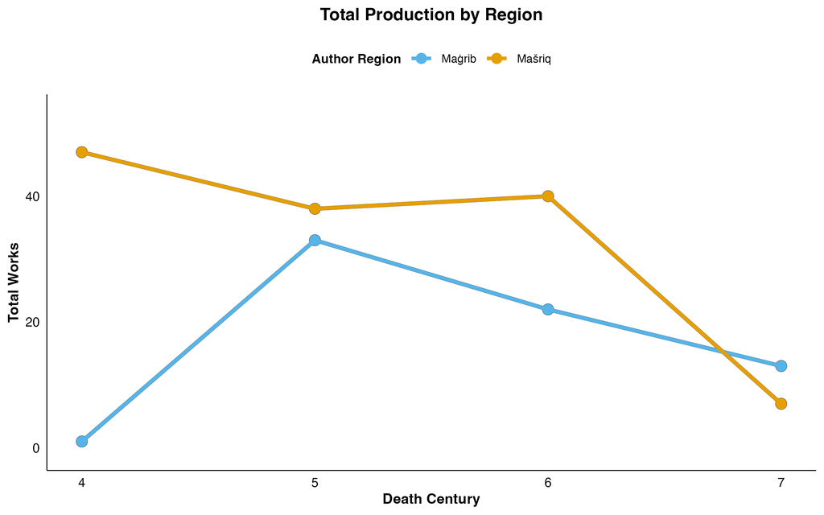

Figure 1: Production of works on the qirāʾāt by century

When framed in terms of geographical region, Mašriq and Maġrib, these data provide significant information about each of the five properties coded in this survey: the Set of Readings a given work transmits, its format, its survival status, its author’s region of origin at the sub-regional level, and its author’s mobility.

#### Set of Readings

The two regions differ outwardly in which Sets of Readings they produce. Mašriqī authors produced fifty-three of their 109 recorded works on a Set of 10+ Readings (49%), a share that increases from 15% in the fourth century to 80% in the sixth, whereas works on the Set of 7 fall from twenty-four to four total works over the same time span. For Maġribī authors, the pattern is reversed: forty-nine of their sixty-four works (77%) transmit the Set of 7, concentrated in the fifth and sixth centuries, whereas only five total works on a Set of 10+ were produced in this region across the entire period. The Set of 7+1 Readings occupies a relatively minor position in both regions (~16% of total production), although its initial prevalence in Šām and subsequent spread to Andalus is notable, and discussed in more detail below.

#### Format

Mašriqī and Maġribī authors agreed on the central set of formats for presenting the Reading Traditions, comprising descriptive catalogues (106 works, 61%), the largest category overall, expansions (22, 13%), and compressions (12, 7%). These three formats account for more than 80% of all titles produced in this survey, and the descriptive catalogue format, alone, constitutes the lion’s share of production in each region (Mašriq 65%, Maġrib 55%). The other coded formats represent a marginal, but analytically useful share of data.[^41] The regional differential in preference for a specific format of presenting a Set of Readings, although relatively minimal in statistical terms, is addressed in greater depth in the section on Pedagogy, below.

#### Survival status

Only eighty of the 173 works (46%) survive in manuscript or published form, as shown in Figure 2. The extent of this “shadow corpus” of lost works is significant, and our ability to integrate it into this analysis is largely due to the aforementioned bibliographic efforts. At the regional level, survival rates differ, but not dramatically: 50% of Maġribī works survive, compared to only 44% of Mašriqī works. Format also correlates with survival: compressions have the highest loss rate (83%), followed by didactic poems (75%), descriptive catalogues (52%), *ʾadāʾ* works (50%), *mufradāt* (47%), and expansions (41%).

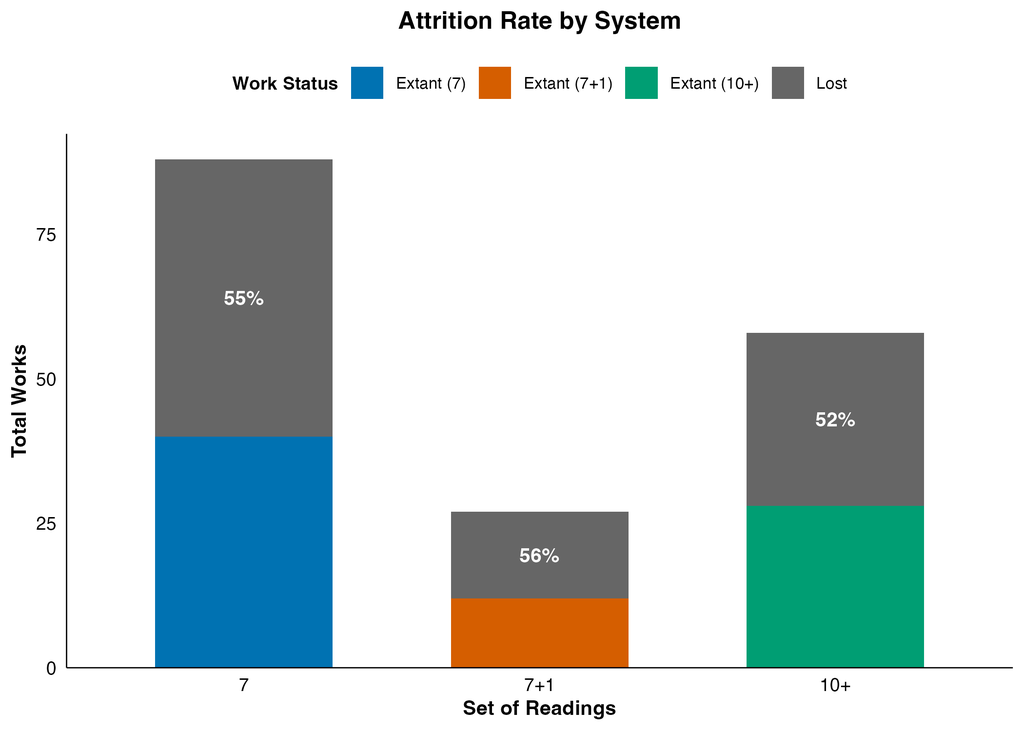

Figure 2: Extant and lost works by sets of Readings

#### Sub-regional distribution

The spatial distribution of the production of works on the Sets of Readings, both century-by-century and cumulatively, is visualized in Figure 3, Figure 4, and Figure 5. In all three map groups, orange marks the Mašriq and blue the Maġrib; color saturation is normalized to peak sub-regional production across all centuries, so that darker shading indicates higher output relative to the overall maximum for that Set of Readings. As the century-by-century panels illustrate, production within a given region can be highly volatile: sub-regions that dominate in one century may contribute nothing in the next, and the leading hub may shift from Iraq to Fārs or from al-Andalus to Egypt. Despite this volatility, the cumulative panels reveal that these sub-regional fluctuations resolve into coherent macro-regional patterns: Mašriqī authors concentrate their output on a Set of 10+, Maġribī authors on the Set of 7, and a Set of 7+1 remains a secondary presence in both.

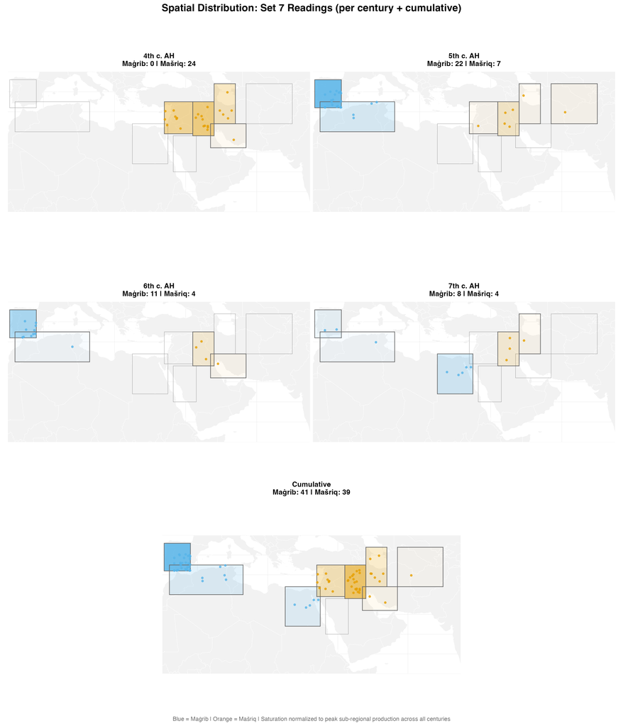

Figure 3: Spatial distribution of works on the Set of 7 by century and cumulative (4th–7th c. AH).

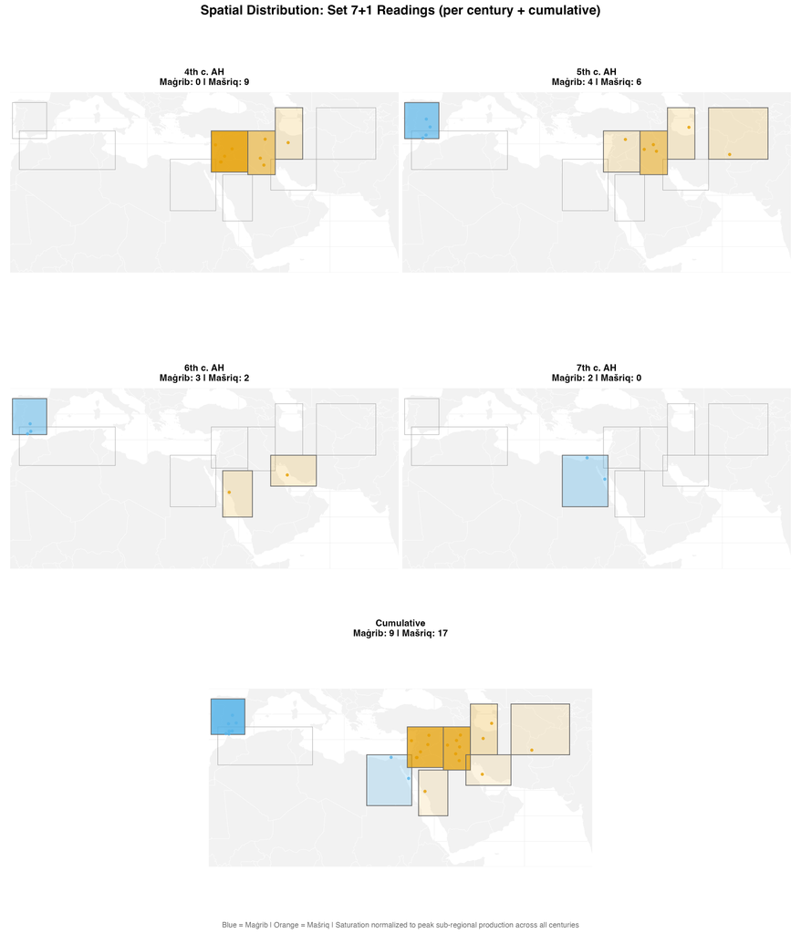

Figure 4: Spatial distribution of works on a Set of 7+1 by century and cumulative (4th–7th c. AH).

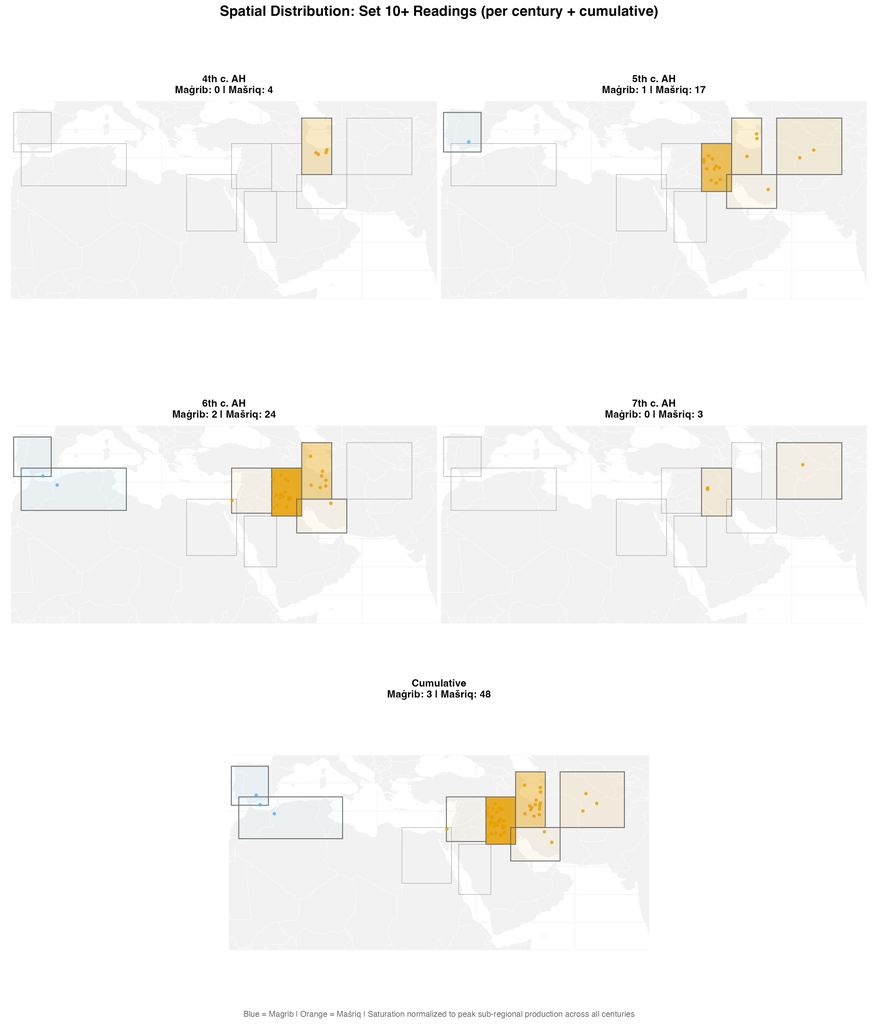

Figure 5: Spatial distribution of works on a Set of 10+ by century and cumulative (4th–7th c. AH).

Table 1 summarizes the sub-regional production by Set of Readings and century.

Table 1: Sub-regional production of works on the *qirāʾāt* by Set of Readings and century (4th–7th c. AH).

Mašriq

| Sub-region | Set | 4th c. | 5th c. | 6th c. | 7th c. | Total |
| --- | --- | --- | --- | --- | --- | --- |
| Iraq | 7 | 10 | 3 | 3 | 3 | 19 |
|  | 7+1 | 4 | 1 | 0 | 0 | 5 |
|  | 10+ | 0 | 8 | 15 | 2 | 25 |
| Šām | 7 | 8 | 1 | 0 | 0 | 9 |
|  | 7+1 | 5 | 1 | 0 | 0 | 6 |
|  | 10+ | 0 | 0 | 1 | 0 | 1 |
| Ǧibāl-Ṭabaristān | 7 | 5 | 1 | 0 | 1 | 7 |
|  | 7+1 | 1 | 1 | 0 | 0 | 2 |
|  | 10+ | 4 | 3 | 7 | 0 | 14 |
| Fārs | 7 | 1 | 1 | 1 | 0 | 3 |
|  | 7+1 | 0 | 1 | 1 | 0 | 2 |
|  | 10+ | 2 | 4 | 1 | 0 | 7 |
| Ḫurāsān | 7 | 0 | 1 | 0 | 0 | 1 |
|  | 7+1 | 0 | 1 | 0 | 0 | 1 |
|  | 10+ | 0 | 5 | 0 | 1 | 6 |
| Ḥiǧāz | 7+1 | 0 | 0 | 1 | 0 | 1 |

Maġrib

| Sub-region | Set | 4th c. | 5th c. | 6th c. | 7th c. | Total |
| --- | --- | --- | --- | --- | --- | --- |
| Egypt | 7 | 1 | 1 | 0 | 8 | 10 |
|  | 7+1 | 0 | 0 | 0 | 2 | 2 |
|  | 10+ | 0 | 1 | 0 | 0 | 1 |
| Ifrīqiyah | 7 | 0 | 6 | 2 | 1 | 9 |
|  | 7+1 | 0 | 0 | 1 | 0 | 1 |
|  | 10+ | 0 | 1 | 1 | 0 | 2 |
| Andalus | 7 | 0 | 18 | 10 | 2 | 30 |
|  | 7+1 | 0 | 4 | 3 | 0 | 7 |
|  | 10+ | 0 | 1 | 1 | 0 | 2 |

#### Mobility

The two categories of authors—stationary and inter-regional—display notably different profiles across several biographical qualities. In the fifth century, stationary Mašriqī authors average 1.9 recorded stops in their itineraries, whereas Maġrib-to-Mašriq travelers average 10.3 stops. It should be noted that this figure is substantially inflated by the exceptional case of Abū al-Qāsim Yūsuf b. ʿAlī b. Ǧubārah al-Huḏalī (d. 465), whose thirty-eight recorded stops make him the author with the most extensive itinerary in this survey. Al-Huḏalī himself was well aware of his singularity: both al-Ḏahabī and Ibn al-Ǧazarī report that al-Huḏalī declared that if he learned of anyone more widely traveled than he for the sake of learning *qirāʾāt*, he would journey to meet that person directly.[^42] Excluding him, the Maġribī inter-regional average drops to 6.3 stops per author.

Two further indicators confirm that inter-regional authors constitute a distinctive class. First, they are more prolific: inter-regional authors average 2.0 works per person, compared to 1.6 for stationary authors, and this disproportion grows among Maġribīs (2.1 works per inter-regional author vs. 1.5 for stationary). Second, their works survive at markedly higher rates: 60% of works by stationary authors are lost, consistent across the Mašriq and Maġrib, whereas only 36% of inter-regional authors’ works are lost. This aggregate figure is substantially influenced by al-Dānī (d. 444), who alone accounts for nine of the forty-five inter-regional works (20%), of which an anomalous 78% survive; excluding him, the inter-regional loss rate rises to 39% (fourteen of thirty-six works), though the overall pattern holds. The distinctiveness of this group—in their travel, their productivity, and the survival of their works—warrants separate analysis of their compositional choices, a subject which is taken up in a dedicated section below.

#### Summary

These descriptive statistics present strong evidence of patterned literary production of in the discipline of *qirāʾāt* in the Mašriq and Maġrib. Both regions present remarkable similarities, including their production in similar formats of works, similar loss rates of the corpus, and relative proportion of stationary authors. Higher rates of mobility, documented in inter-regional authors, mark a unique sub-population of *qirāʾāt* authors who were more prolific and whose works were better preserved. They also present intriguing evidence of regional differentiation, such as the much more extensive overall production in the Mašriq, as well as strong correlation between regional origin and preference for Sets of Readings documented in the Mašriq (Set of 10+) and Maġrib (Set of 7), which for the most part coheres even at the sub-regional level.

However, several features of our data require caution in their interpretation. The corpus is both unbalanced and relatively sparse: the production of Mašriqī authors dwarfs that of the Maġribīs, and the corpus contains approximately one work for every two years covered. Similarly, sub-regional concentrations are substantially attributable to individual prolific authors: in al-Andalus, al-Dānī alone accounts for eight of the eighteen fifth-century works on the Set of 7 (44%), with a ninth—his *Mufradat Yaʿqūb*—belonging to the Set of 7+1; in fourth-century Mašriqī production of works on a Set of 10+, four of the six recorded works belong to Ibn Mihrān (d. 381), based in Nīsābūr/Iṣbahān (Ǧibāl-Ṭabaristān), and the remaining two were composed by Fārsī authors as commentaries on his *al-Ġāyah*; the Ibn Ġalbūn family produced six of the eight works on the Set of 7 attested for fourth-century Šām; and in fourth-century Iraq, Ibn Muǧāhid authored four of the ten works on the Set of 7. Such variability should be borne in mind particularly when interpreting the maps: sub-regional saturation simply reflects the number of works, not the number of independent authorial programs. To test whether the regional differences observed here are statistically robust despite these uncertainties, the following section applies a Bayesian framework analysis to the same data.

### Bayesian analysis

We fit a Bayesian multinomial logistic regression to the 173 works, treating the Set of Readings a given work is associated with as the categorical outcome of the model, and including an author’s origin Region and death century (mean-centered) as predictors. The choice of a Bayesian model, as opposed to a Frequentist approach, is motivated both the strength of our prior assumptions about the relative difference in *qirāʾāt* scholarship between the Mašriq and Maġrib, based on the preceding analysis, as well as the need to model the uncertainty of relatively unbalanced, sparse, and otherwise uncertain data, as discussed above. The advantages offered by Bayesian modeling help us, in turn, to pose three questions about the regional differentiation of the *qirāʾāt* discipline, each of which presupposes the answer to the last. First: did the production of the two regions actually diverge, and did the gap between them widen over the period surveyed? Second, and only if it did: how far apart did the two systems get—measured not in the abstract, but against how far apart they *could* have got, given what the two regions demonstrably held in common? And third: is it an author’s regional origin that drives the pattern, or can his sub-region, his mobility, or the genre in which he wrote explain it away?

#### Did the two regions’ output diverge—and did the gap widen?

The model’s temporal predictions offer the most intuitive entry point to our data: they show what the regression expects regional output to look like in terms of production of works dedicated to a Set of Readings in each region and century. Figure 6 is divided into two panels, one for each region; within each panel, the x-axis marks the century (4th–7th AH) and the y-axis gives the predicted probability that a work produced in that region and century belongs to a given Set of Readings. Three colored lines trace the three Sets of Readings, with shaded bands marking the 50% credibility intervals and thin background lines representing individual posterior draws, which convey the full range of the model’s uncertainty.

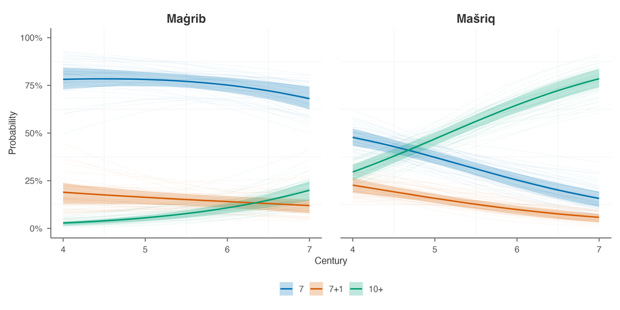

Figure 6: Posterior temporal predictions with uncertainty: predicted probability of each Set of Readings across centuries for Mašriq and Maġrib, with 50% credible intervals (shaded bands) and a sample of individual posterior draws (thin lines) conveying visual texture of the model’s uncertainty.

#### How different did the two regional systems actually become?

To move beyond the question of *whether* the regions differ and toward the question of *how much* they differ, we employ a summary metric called Jensen-Shannon Divergence (JSD).[^43] JSD indexes the amount of dissimilarity between two systems by computing a single-number expressed on a continuum between 0 and 1. Mapped to the present dataset, a score of 0 means the two regions exhibit exactly the same literary production of Sets of Readings, and a score of 1 means that the regions exhibit completely opposite patterns. Whereas JSD allow us to model the differences between the Mašriqī and Maġribī systems efficiently in theory, the nature of real-world, historical data places constraints on the amount of differentiation that two systems are likely to achieve; this circumstance, in turn, makes it unlikely that the model will return scores of maximum “convergence” and “divergence” (0 and 1, respectively). One such constraint in our data is the documentation that authors in both the Mašriq and Maġrib continuously produced works on the Set of 7 throughout the period surveyed, thus making a score of 1 impossible to achieve.[^44]

Owing to the introduction of this extra layer of complexity, we estimate the JSD using two independent methods and compare the outcomes, which are visualized in Figure 7 and Figure 8. Both figures express the divergence as a proportion of that constrained maximum, so that the quantity plotted is not an abstract distance in bits but the answer to the question posed: how far apart the two systems got, out of how far apart they could have got. Each also carries the other estimate as a faint dotted line, so that the two may be read against one another. The two estimation methods, which share no statistical machinery, converge closely on the magnitude of the divergence between the Mašriqī and Maġribī systems of production of *qirāʾāt* works, and agree that it grows over time; where they differ is on the rate at which that divergence accumulated.

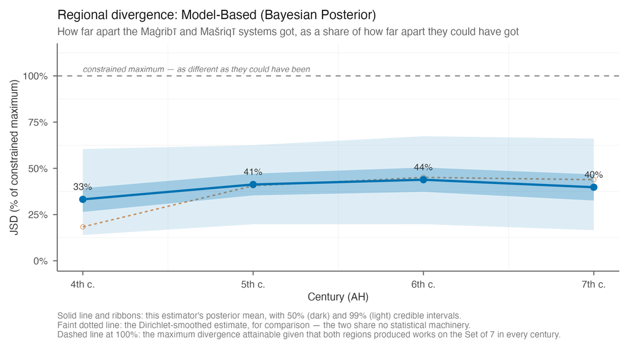

Figure 7: Model-based divergence between the Maġribī and Mašriqī distributions of Sets of Readings, by century, derived from the Bayesian multinomial regression posterior and expressed as a proportion of the constrained maximum (dashed line at 100%). The distance below that line is the shared core of Readings neither region abandoned. Ribbons show 50% and 99% credible intervals; the faint dotted line is the Dirichlet-smoothed estimate, given for comparison.

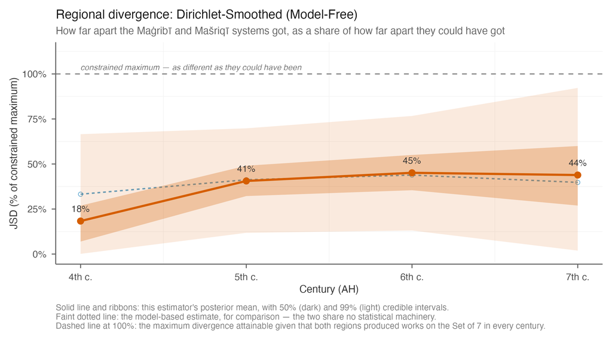

Figure 8: Dirichlet-smoothed (model-free) divergence between the same distributions. Each century is treated independently, using Dirichlet(1 + counts) posteriors, which is why the fourth century—where the Maġrib is represented by a single work—is pulled sharply toward the two regions’ agreement. Conventions as in Figure 7; the faint dotted line is the model-based estimate.

Averaged across the three and a half centuries surveyed, the two methods’ reckoning of the divergence agrees to within a few points (40% from the model-based estimate of Figure 7, 37% from the Dirichlet-smoothed estimate of Figure 8, both as a proportion of the constrained ceiling). But the average both understates that agreement and conceals what is most instructive about it. Taken century by century, the two estimates are all but identical from the fifth century onward—one point apart in the fifth, one in the sixth, four in the seventh. They part company in exactly one place: the fourth century, where they stand fifteen points apart (model-based 33%, Dirichlet-smoothed 18%).

Neither reading is wrong. Together they place the observed divergence between roughly one-fifth of the constrained ceiling at its fourth-century floor and nearly one-half at its sixth-century peak, and both indicate a substantial increase in the separation of the two regions’ *qirāʾāt* systems over time.

The estimates of divergence between the Mašriqī and Maġribī *qirāʾāt* authors in terms of a preference for a given Set of Readings provides a quantitative basis from which to conclude that the two regional systems achieved a significant degree of dissimilarity. The observed JSD, which reaches only about one-third to nearly one-half of the constrained ceiling (depending on the century and the estimation method), indicates the two further aspects of the divergence between the two regions. First, both estimates confirm that the Mašriq and Maġrib never produced identical distributions of Sets of Readings during the period surveyed. Second, authors from the two regions never fully abandoned a shared “core” of Readings. Rather, the divergence measured in these data suggests the operation of fundamentally different processes underlying the establishment of a core of Set of Readings in the Mašriq and Maġrib.[^45]

#### Is it regional origin that drives this—or something else?

What these figures reveal is striking. For a Set of 10+, every single simulation of the paths to the observed distribution places the Mašriq ahead of the Maġrib: the entire histogram sits to the right of zero, with no overlap whatsoever. For the Set of 7, the pattern reverses exactly: every draw places the Maġrib ahead, and the histogram sits entirely to the left of zero. For a Set of 7+1, by contrast, the histogram straddles zero, meaning the two regions are, for the most part, statistically indistinguishable for this Set, matching the uncertainty of the simpler statistical analysis on its prevalence conducted in the previous section.

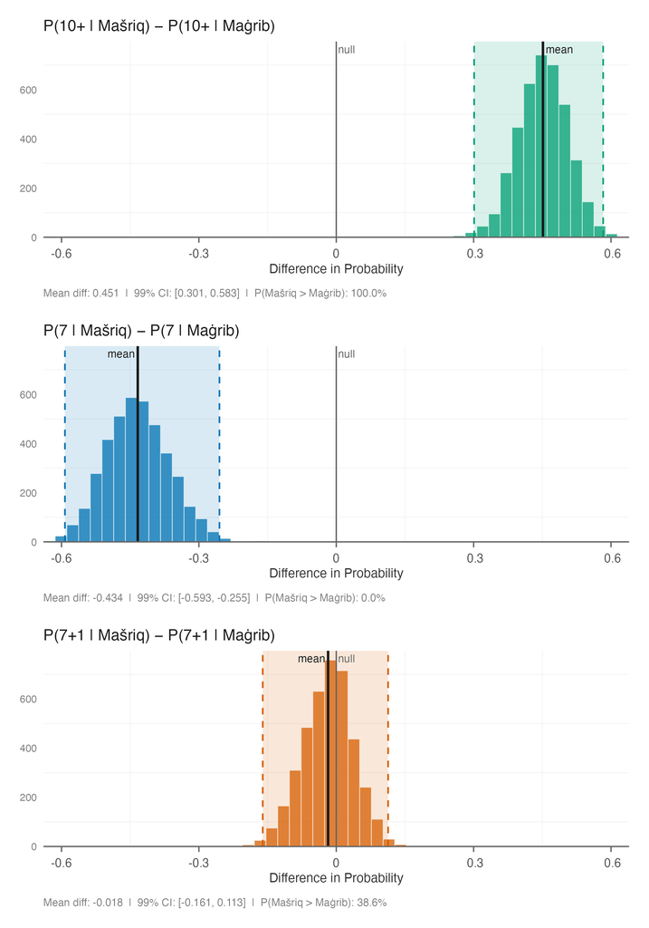

Figure 9: Posterior contrasts: distribution of the difference in predicted probability P(system | Mašriq) − P(system | Maġrib) for each set of Readings, averaged across centuries

The posterior analysis allows us to state confidently that an author’s origin provides us with more information about which Set of Readings he wrote about than any other variable encoded into the model. When we express this confidence as an odds ratio, we can state that a Mašriqī work is between 18 and 19 times more likely to transmit a Set of 10+ than the Set of 7 (median OR = 18.8, 99% CI [5.7, 86.5]).

#### Conclusions of Bayesian analysis

Bearing in mind the results of the Bayesian multinomial regression analysis, we are now in a position to answer the three questions with which this section began. The two regions’ output did diverge, and the gap between them widened across the period: the regional difference in the predicted probability of transmitting a Set of 10+ grows from twenty-seven percentage points in the fourth century to fifty-eight in the seventh. That divergence reached roughly 40% of the maximum the two regions could have attained while both continued to produce works on the Set of 7—a figure on which two estimators sharing no statistical machinery agree. And the driver of the pattern is macro-regional origin itself, which survives controls for sub-region, mobility, and genre alike. These data unambiguously support the conclusion that three and a half centuries of *qirāʾāt* scholarship in the Mašriq and Maġrib followed markedly different trajectories which can best be captured in their collective preference for a Set of 10+ and 7 Readings, respectively. With this statistical confirmation of regional differentiation in hand, we now turn to a detailed narrative of the these trajectories in each region.

## Narrative Analysis

In keeping with the geographic focus of this research, it is useful to orient the narrative of independent regional development to specific locations which feature prominently in the development of the *qirāʾāt* corpus during the period under investigation. Table 2 summarizes the principal hub cities associated with *qirāʾāt* authors, including their cities of origin and those to which they traveled, and the shifts they underwent across centuries.

Table 2: Principal hub cities of *qirāʾāt* production by century and region (number of associated scholars).

| Century | Mašriq (top cities) | Maġrib (top cities) |
| --- | --- | --- |
| 4th | Baġdād (11), Ḥalab (4), Anṭākiyah (3), Dimašq (3), Nīsābūr (3) | Cairo (5) |
| 5th | Baġdād (17), Makkah (7), Nīsābūr (5), Dimašq (5) | Cairo (12), Qurṭubah (7), al-Qayrawān (5), Išbīliyyah (4) |
| 6th | Baġdād (12), Iṣbahān (4), Wāsiṭ (4), Makkah (4), Šīrāz (3) | Išbīliyyah (5), Qurṭubah (5), al-Iskandariyyah (4), Cairo (3) |
| 7th | Dimašq (2) | al-Iskandariyyah (5), Cairo (4) |

### The Development of Mašriqī *qirāʾāt* Literature

The development of a corpus of *qirāʾāt* literature in the Mašriq was not a straightforward affair. Instead, significant differences developed at the level of major sub-regions such as Iraq, Šām and Ḫurāsān, each of which maintained significant historical trajectories past the foundational period of the fourth century. Nevertheless, region-wide alignment on multiple instantiations of a Set of 10+ Readings was attained by no later than the middle of the fifth century, and continued unabated until near the end of the surveyed period, at which time a resurgence of interest in the Set of 7 Readings becomes detectable.

#### The fourth century: A multi-polar region

Fourth-century Mašriqī output clusters around three geographic poles, each favoring a different Set of Readings: Iraq for the Set of 7, Šām for a Set of 7+1, and Ḫurāsān for a Set of 10+.

In Iraq, Ibn Muǧāhid (d. 324) touched off an intensive cluster of literary activity with his *K. al-Sabʿah* and four related, although unfortunately lost, works. His students amplified this output: al-Naqqāš (d. 351) produced a trilogy on the Set of 7, all lost; Abū Ṭāhir Ibn Abī Hāšim (d. 349) composed his lost descriptive catalogue *K. al-Bayān* as an attempt to surpass the documentation of *K.* *al-Sabʿah*; and al-Ḥusayn b. ʿUṯmān al-Baġdādī (d. 378) produced the earliest known Mašriqī didactic poem on the Set of 7 Readings, also lost. Yet the same milieu also produced at least two (lost) works on a Set of 7+1—including by al-Naqqāš and Ibn Ḥasnūn (d. 386), both students of Ibn Muǧāhid—indicating that no single Set could claim the crown of canonicity in fourth-century Iraq. The near total extinction of works produced in Iraq during this period underscores the importance of the aforementioned “shadow corpus” to investigating this crucial period of disciplinary formation.

In Šām the situation mirrors Iraq, except that authors there exhibit a distinctive preference for a Set of 7+1 Readings, with a secondary emphasis on production of works on the Set of 7. Abū Bakr al-Dāǧūnī (d. 324), Abū Isḥāq al-Anṭākī (d. 338), Abū Ṭāhir al-Anṭākī (d. 380), and Abū al-Fatḥ al-Ḥimṣī al-Ḍarīr (d. 401) all composed a single work on 8 Readings, although al-Dāǧūnī’s work differed from those of his compatriots by including the Reading of Abū Ǧaʿfar al-Madanī (d. 130) rather than that of Yaʿqūb.[^49] Aside from this minor difference, it is striking that all the works noted above share what we will refer to, for the sake of convenience, as the “1 Book/8 Readings” configuration, as opposed to the “7 + *mufradat* Yaʿqūb” configuration of a Set of 7+1 that would predominate in the Maġrib. The Ibn Ġalbūn family of Aleppo—Abū al-Ṭayyib (d. 389) and his son Abū al-Ḥasan (d. 399)—notably produced works on both Sets of 7 and the 1 Book/8 Readings format while in Šām; Ibn al-Ǧazarī in *ĠN* preserves evidence of Abū al-Ḥasan’s teaching his *K. al-Taḏkirah* in Dimašq before his family’s departure to Egypt, sometime before 352 AH. Several other Šāmī authors migrated to Egypt during this period, where they created an émigré community that proved decisive for the westward transmission of a Set of 7+1, discussed in more detail below.

In Nīsābūr, Abū Bakr Ibn Mihrān (d. 381), originally from Iṣbahān, consecrated a regional tradition on a Set of 10+ with a number of works, among them *K. al-Ġāyah fī al-qirāʾāt al-ʿašr* (11 Readings), *K. al-Mabsūṭ* (10 Readings), and the lost *K. al-Šāmil*, as well as several *mufradāt* for Readers included in a Set of 10+. This œuvre, particularly *K. al-Ġāyah*, generated commentaries, possibly within Ibn Mihrān’s own lifetime, from two other Fārsī authors: ʿAlī b. ʿAbd Allāh al-Fārsī, Abū al-Ḥasan (d. ca. 390), whose *Šarḥ* ‘al-Ġāyah’ is lost, and Abū al-Ḥasan ʿAlī b. Muḥammad al-Fārsī (d. ca. 390), who composed a lost *ʿIlal* ‘al-Ġāyah’. Ibn Mihrān’s own four works plus these two commentaries account for the entirety of fourth-century production on a Set of 10+, establishing a Fārs–Ḫurāsān coupling that underscores this Set of Reading’s origins as a phenomenon of the eastern provinces rather than the Mašriq as a whole. But Ḫurāsān also produced work on other Sets of Readings, notably an unnamed work Abū Naṣr Aḥmad al-Ḥaddādī (d. after 400) on the Set of 7, demonstrating that this Set circulated in the same region contemporaneously with Ibn Mihrān’s more celebrated experimentation with a Set of 10+.

Several well-traveled fourth-century Mašriqī authors exhibit the extent to which contact between different sub-regions—and, hence, different Sets of Readings—influenced the Set of Readings to which a scholar might choose to dedicate a work. Abū ʿAlī al-Fārisī (d. 377), a native of Fasā in Fārs and a close contemporary his sub-regional compatriot Ibn Mihrān, traveled to Baġdād to study with Ibn Muǧāhid, where he produced works which exclusively focused on the Set of 7, such as his *K. al-Ḥuǧǧah fī ʿilal al-qirāʾāt al-sabʿ*, in which substantial portions of the *K. al-Sabʿah* are reproduced with letter-perfect accuracy.[^50] Ibn Ḫālawayh (d. 370), originally from Hamaḏān, likewise moved to Baġdād to study with Ibn Muǧāhid, where he composed two works on the Set of 7; however, upon relocating to Ḥalab he apparently dedicated his *K. al-Badīʿ* to the Hamdanid ruler Sayf al-Dawlah (re. 333—56), a work on a Set of 7+1 that reflects the local Šāmī preference for an additional Reading to the more widely circulating Set of 7.[^51]

The co-existence of various Sets of Readings across these sub-regions militates against any straightforward narrative of “canonization” of the Set of 7 throughout the Mašriq, much less Iraq. Even in this latter locale, within the generation of Ibn Muǧāhid’s own students and contemporaries, continuity in terms of production of works on the Set of 7 Readings was not a given. In fact, region-wide continuity on a given Set of Readings would not be achieved until the next century, a period dominated by the production of works on a Set of 10+ Readings.

#### The fifth century: The “maximalist” turn and regional alignment on the Set of 10+

The fifth century marks the principal turning point in Mašriqī authors’ attraction to works on a Set of 10+. Production of works in this Set of Readings expanded from the aforementioned six total works in the fourth century to twenty in the fifth. Throughout this narrative, as in the statistical analysis above, a work is counted under the region of its author’s origin; the works of inter-regional authors—such as al-Huḏalī (d. 465), a native Maġribī who composed his maximalist *K. al-Kāmil* in the Mašriq, or the Mašriqīs Abū ʿAlī al-Mālikī (d. 438) and Naṣr al-Fārsī (d. 461), who both wrote their works on a Set of 10+ in Egypt—receive separate treatment in the section on inter-regional scholars below.

The most notable feature of this wave of production is a “maximalist” impulse, which apparently drove authors to compile works documenting far more than 10 Readings. The first dedicated *qirāʾāt* work in which this tendency is documented is the *K. al-Muntahā* by Abū al-Faḍl al-Ḫuzāʿī (d. 408), in which he brought together fifteen Readings. Abū ʿAlī al-Ahwāzī (d. 446) compiled perhaps eighteen or twenty-one Readings in his lost *K. al-Iqnāʿ*. The maximalist tendency reached its fullest expression in al-Ahwāzī’s students, Abū Maʿšar al-Ṭabarī (d. 478) and Abū Bakr al-Rūḏbārī (d. 489), each of whom reused the text of *al-Iqnāʿ* apparently in its entirety, adding documentation of additional Readings, so that each work describes twenty-four Readings. Al-Rūḏbārī’s output is especially notable, as it marks the second major tradition of a Set of 10+ to reach Ḫurāsān, independent of Ibn Mihrān’s circle of influence in Nīsābūr.

Mašriqī production of works on a Set of 7+1 halved: five Mašriqī works on this Set are attested for the fifth century—among them al-Ahwāzī’s *al-Waǧīz* and Abū Maʿšar al-Ṭabarī’s (d. 478) *K. al-Talḫīṣ fī al-qirāʾāt al-ṯamān*, the only two of the five to survive—compared to ten in the fourth century.[^52] As for the Set of 7, Mašriqī production declined from twenty-four works in the fourth century to seven in the fifth, three of which were authored by Iraqis; akin to the situation in the fourth century, nearly all of these works on the Set of 7 Readings are lost.[^53] While this allegiance to the model set by Ibn Muǧāhid’s *Sabʿah* is striking, the near total loss of Mašriqī works on the Set of 7 Readings first observed in the preceding century makes it difficult to discern the relationship between the works in this Set, in particular.

The scale of these shifts in composition—a tripling of Set of 10+ production alongside a two-thirds decline in the Set of 7—accounts for much of the Mašriqī contribution to the divergence registered in Figure 7 and Figure 8. The Dirichlet-smoothed estimate, which treats each century independently, concentrates nearly the entire fourth-to-fifth-century JSD jump on this side of the equation: the Mašriqī distribution swung from a multi-polar fourth century (in which all three Sets established patterns of sub-regional influence) to a fifth century dominated by a Set of 10+. The model-based estimate, by contrast, spreads this transition across the full period as a gradual linear trend—a smoothing that, in light of the evidence presented here, understates the seismic shift represented by Mašriqī authors’ attraction to documenting Readings well beyond Ibn Muǧāhid’s 7.

#### The sixth century: Consolidation of the Set of 10+

Of Mašriqī works produced in the sixth century, twenty-four of thirty (80%) transmit a Set of 10+. The geographic center of gravity consolidated around the Baġdād–Wāsiṭ–Hamaḏān axis. The culminating figures are Abū al-ʿIzz al-Qalānisī (d. 521) and Sibṭ al-Ḫayyāṭ (d. 541), whose works represent the mature Iraqi corpus on ten and eleven Readings. The works of these scholars eventually reached Šām, and became the preserve of the outstanding transmitter of the Readings, Tāǧ al-Dīn Abū Yumn al-Kindī (d. 613), underscoring that the development of the corpus depended, at least in part, on specific teachers who sustained transmission networks across sub-regional boundaries.[^54] Al-Kindī’s preeminence within the broader Mašriqī pedagogical tradition will be treated in greater detail, below.

In the eastern sub-region of Ǧibāl-Ṭabaristān, Abū al-Karam al-Šahrazūrī (d. 550) composed *al-Miṣbāḥ al-zāhir fī al-ʿašr al-bawāhir* and Abū al-ʿAlāʾ al-Hamaḏānī (d. 569) *K. Ġāyat al-iḫtiṣār fī al-qirāʾāt al-ʿašr*—both extant works on a Set of 10+, each of which conforms to “the” Set of 10+ recognized by later Mašriqī authors, such as Ibn al-Ǧazarī in his *Našr al-qirāʾāt al-ʿašr*. Likewise, in Fārs, Abū Ḏarr al-Yazdī (d. after 580) continued to produce major compilatory works on a Set of 10+, including *Ġāyat al-muntahī wa-nihāyat al-mubtadī fī al-qirāʾāt al-ʿašr*, *K. al-Muntaqā fī al-ʿašarah*, and a compression (*muḫtaṣar*) of the *Muntaqā*. In addition to illustrating Mašriqī authors’ convergence on a unified Set of 10+ Readings, al-Yazdī’s pairing of the *Muntaqā* with its own abridgement illustrates the practice of *auto-compression*: the composition by a single author of both a base work and an abridgement or elaboration of his own text, also attested earlier in the century in Sibṭ al-Ḫayyāṭ’s publication of the descriptive catalogue *al-Iḫtiyār* paired with the lost didactic poem *Irādat al-ṭālib*. This format would become very popular in the Maġrib, where the base text-commentary pairing became a hallmark of regional scholarship, as discussed on the section on pedagogy, below.

Works on a Set of 7+1 effectively disappeared from Mašriqī production after the mid-sixth century. The latest Mašriqī authors of this Set—Ibn Abī Mušayraḥ al-Ḥaḍramī (d. 560) of the Ḥiǧāz and Abū ʿAbd Allāh al-Fārsī (d. 565) of Fārs—represent the last vestiges of its production for the period surveyed. The Set of 7 contracted to a similarly marginal presence: only four works are attested for sixth-century Mašriqī authors, such as al-Bāriʿ al-Dabbās (d. 524) in his lost *al-Šams al-munīrah fī al-qirāʾāt al-sabʿ al-šahīrah*, Sibṭ al-Ḫayyāṭ’s *al-Īǧāz* and the lost *al-Muʾayyadah*, and Ibn al-Harrās’s (d. 580) lost *K. al-Bahǧah*. Notably, production in the Set of 7 was sustained almost entirely by authors whose primary output was on a Set of 10+.

#### Summary

Viewed across the centuries, the Mašriqī trajectory resolves from a rather mixed picture in the earliest phase into a clear preference for a Set of 10+ Readings by the middle of the fifth century. The fourth century was multi-polar: the Set of 7 dominated in Iraq and Šām, a Set of 7+1 established itself in Šām, and a Set of 10+ first appeared in Ḫurāsān. The fifth century saw a decisive maximalist turn, with a Set of 10+ tripling in production while the Sets of 7 and 7+1 contracted sharply. The sixth century consolidated a Set of 10+ as the default orientation for new Mašriqī compositions, whereas the Set of 7 was sustained almost entirely by authors whose primary output was on the larger Set. The seventh century, with only three active authors surveyed, defies any categorical statement although the documented turn toward the Set of 7 portends a shift in regional dynamics, covered more fully in the section on Inter-regional scholars, below.

### The Maġrib

The growth of the *qirāʾāt* discipline in the Maġrib forms in many respects tracks with that of the Mašriq; in multiple cases, a development that started in the Mašriq and reached its full expression in the Maġrib can be detected. Yet despite numerous commonalities, Maġribī *qirāʾāt* authors as a whole displays a very different profile from their Mašriqī counterparts in terms of their overall profile within the transcontinental network of *qirāʾāt* scholarship, the Sets of Readings they preferred, their mode of presenting the Sets of Readings, and their ability and willingness to engage with works which originated in a different region.

#### The fourth century: al-Muẓaffar b. Aḥmad al-Miṣrī (d. 333)

The only attestation of native Maġribī production in the discipline of *qirāʾāt* for the period surveyed is al-Muẓaffar b. Aḥmad al-Miṣrī’s (d. 333) lost *K. Iḫtilāf al-sabʿah*. As the oldest known Maġribī work on the Set of 7, *K. Iḫtilāf al-sabʿ* provides a unique point of access to the early development of the *qirāʾāt*. Its author was stationary, with no recorded travel beyond Egypt, and his work left no discernible legacy through obvious forms of text reuse, such as inspiring the production of commentaries. Moreover, nearly two centuries elapsed before another text by an Egyptian author is recorded in our corpus. These circumstances pose an important, and as yet to our knowledge, unaddressed question: Does al-Muẓaffar’s *K. Iḫtilāf al-sabʿah* reflect an independent, indigenous Egyptian tradition of documenting the 7 Readings, or was this work dependent in some way on Ibn Muǧāhid’s *K. al-Sabʿah*, a title widely recognized to have had a unique influence on the dissemination of the Set of 7 Readings?[^55]

Given the parlous state of our information about both al-Muẓaffar b. Aḥmad himself and his work, the following remarks should be treated as subject to further qualification. Nevertheless, an examination of the personal networks of students and teachers for both al-Muẓaffar and Ibn Muǧāhid, as recorded in al-Ḏahabī’s *MQK*, should shed light on the potential intersection of authorial programs from the Mašriq (as represented by Ibn Muǧāhid) and Maġrib (as represented by al-Muẓaffar). Both figures appear in the eighth *ṭabaqah* of al-Ḏahabī’s *MQK*; the network for all figures from this *ṭabaqah*, with both al-Muẓaffar b. Aḥmad and Ibn Muǧāhid highlighted, is visualized in Figure 10:[^56]

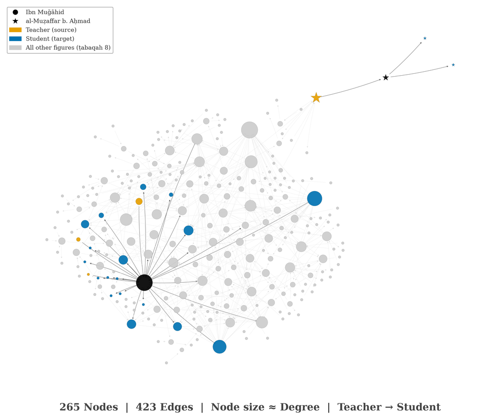

The two authors’ personal networks do not intersect directly—they share no immediate teachers or students—and each figure represents very different structural and epistemic portions of the *qirāʾāt* network across the third and fourth centuries. This distance between them can be formalized through metrics of Social Network Analysis (SNA), such as “geodesic distance.”[^57] Geodesic distance measures the least number of “steps” it takes to link one figure to another within the network, using only the documented paths therein. Within the eighth *ṭabaqah* of *MQK*, Ibn Muǧāhid is on average approximately 2.8 steps away from every other scholar, and the furthest point from him in the network lies six steps away.[^58] By way of contrast, al-Muẓaffar b. Aḥmad sits at a remove of five steps from Ibn Muǧāhid, a distance surpassed only by al-Muẓaffar’s students, ranking him among the most peripheral figures to one of the leading lights of Baġdādī *qirāʾāt* scholarship. This confirms in quantitative terms the impression conveyed by a visual inspection of Figure 10, as well as other basic SNA statistics: Ibn Muǧāhid and al-Muẓaffar, despite being near-exact contemporaries, occupied remote positions within the same *qirāʾāt* network.[^59]

This formal understanding of the distance between Ibn Muǧāhid from al-Muẓaffar b. Aḥmad in al-Ḏahabī’s presentation of the contemporaneous *qirāʾāt* network can be substantially nuanced by a more qualitative inspection of the data provided in *MQK*. Al-Muẓaffar b. Aḥmad had only one known teacher, Aḥmad b. ʿAbd Allāh b. Muḥammad b. Hilāl al-Azdī (d. 310), the sole figure that connects the al-Muẓaffar sub-graph to the rest of the *qirāʾāt* network; al-Ḏahabī names him without further elaboration. By contrast, al-Ḏahabī records three teachers for Ibn Muǧāhid and discusses the nature of their personal interactions extensively.[^60] The dissimilarity becomes even clearer when considering the two figures’ reputation as teachers whose influence drove the continued development of the *qirāʾāt* discipline. Al-Ḏahabī only records two students for al-Muẓaffar: the grammarian Muḥammad b. Ḫurāsān al-Ṣiqillī (d. 386), who is known primarily as the transmitter of the works of the famous Egyptian grammarian Abū Ǧaʿfar (Ibn) al-Naḥḥās (d. 338); and Muḥammad b. ʿAlī b. Aḥmad al-Udfuwī (al-Uḏfuwī, d. 388), who authored an influential *tafsīr* entitled *al-Istiġnāʾ fī ʿulūm al-Qurʾān*, itself an important source of *qirāʾāt* data, that was reused in its own right throughout the Maġrib.[^61] Al-Ḏahabī opens the discussion of Ibn Muǧāhid’s students, however, by stating that their numbers were legion (*qaraʾa ʿalā bni Muǧāhidi umamun lā yaḥsūn*), and proceeds to document eighteen students, among them luminaries of a long-tailed generation of scholars such as Ṣāliḥ b. Idrīs (d. 345), Abu Ṭāhir Ibn Abī Hāšim (d. 349), Abū ʿĪsā Bakkār b. Aḥmad (d. 353), Abū Bakr al-Šaḏāʾī (d. 373 or 376), and Abū al-Faraǧ al-Šanabūḏī (d. 380 or 388), to name only those associated primarily with Baġdād. Beyond the students named in his own tarǧamah, al-Ḏahabī’s eighth *ṭabaqah* documents a further two students for Ibn Muǧāhid in the entries of other scholars, so that the network as a whole records twenty students alongside three teachers for him.

Although the bibliographic evidence pertaining to al-Muẓaffar b. Aḥmad’s *K. Iḫtilāf al-qurrāʾ al-sabʿ* remains far from conclusive, close examination of the existing record with both computational and traditional prosopographical methods sheds extensive light on the conditions of its composition. The combination of the (near) simultaneity of Ibn Muǧāhid’s and al-Muẓaffar’s careers along with the remoteness of and differences between Ibn Muǧāhid’s and al-Muẓaffar’s personal networks provides compelling evidence that neither one of these figures influenced the other’s composition of a work on the Set of 7.

No other indigenous, fourth-century Maġribī authors are recorded in the database, meaning no other works on any Set of Readings is attested for this period. The Set of 7+1, however, arrived in Egypt during this century through Šāmī émigrés, most notably Abū al-Ṭayyib Ibn Ġalbūn (d. 389) and his son Abū al-Ḥasan (d. 399). The migration of the Ibn Ġalbūns, as well as other Šāmī authors, at this early date set the stage for al-Dānī’s encounter with the Sets of 7 and 7+1 during his stay in Egypt.

#### The fifth century: The crystallization of the primary (7) and secondary (7+1) Maġribī corpora

The fifth century is the formative period for Maġribī *qirāʾāt* production: thirty-two works in total, of which twenty-five transmit the Set of 7, four a Set of 7+1, and three a Set of 10+. Unlike the Mašriq in the fourth century, however, the developments which took shape during this century did not result in what we referred to as a “multi-polar” region as was seen in the Mašriq, with different sub-regions adopting different Sets of Readings. Rather, Maġribī authors developed a dual-layered corpus: a primary body of works built around the Set of 7, and a secondary body alongside it acknowledging the Reading of Yaʿqūb al-Ḥaḍramī (d. 205). The geographical center of gravity of literary production shifted decisively from the previous century, with the densest concentration of activity centered in al-Andalus.

##### The Primary corpus: The Set of 7

The central figure in the adoption of the Set of 7 Readings as the primary corpus for the region is the Andalusī Abū ʿAmr al-Dānī (d. 444), whose eight works on the Set of 7 alone account for nearly one third (32%) of the century’s total production in this Set. Al-Dānī’s output furthermore spans a remarkable range of formats: the encyclopedic descriptive catalogue *Ǧāmiʿ al-bayān fī al-qirāʾāt al-sabʿ al-mašhūrah*, its concise abridgement *K. al-Taysīr*, didactic poetry (*al-Urǧūzah al-munabbihah*, *K. al-Iqtiṣād*), monographs on individual Readers (*K. al-Tahḏīb*, *K. Iḫtilāfihim fī al-yāʾāt*), and pedagogical summaries (*Tabṣirat al-mubtadī*, *Taḏkirat al-ḥāfiẓ*). The breadth of this output is itself significant: al-Dānī was not merely composing works on the Set of 7 at random, but rather building a complete instructional paradigm, including works suited to every level of competence and covering the breadth of the discipline. A critical mass of stationary Andalusī authors sustained the discipline alongside al-Dānī. Ismāʿīl b. Ḫalaf al-Naḥwī (d. 455) produced three works including *K. al-ʿUnwān* and a now lost abridgement (*iḫtiṣār*) of Abū ʿAlī al-Fārsī’s (d. 377) *K. al-Ḥuǧǧah*;[^62] al-ʿĀṣī al-Išbīlī (d. 470) composed two lost works, *K. al-Taḏkirah* and *K. al-Muhaḏḏab*; and Sulaymān b. Naǧāḥ (d. 496), al-Dānī’s student, contributed a didactic poem, discussed in further detail below.

The founding generation of Ifrīqī authors from this century stands out for their exceptional mobility: all seven works of this period from Ifrīqiyah are attributed to figures who traveled beyond the sub-region. Ibn Sufyān al-Qayrawānī (d. 415), author of *K. al-Hādī*, and Makkī b. Abī Ṭālib (d. 437), who produced *K. al-Tabṣirah* and *al-Kašf*, were inter-regional authors

whose formation was shaped by sustained contact with the Mašriqī environment; al-Mahdawī (d. 440) later traveled westward to al-Andalus. The complete absence of stationary production distinguishes Ifrīqiyah from al-Andalus, which sustained a robust locally rooted tradition alongside mobile scholars. The high mobility profile of Ifrīqī authors was compounded by the Hilālian sack of al-Qayrawān in 449/1057, which devastated the city’s institutions and dispersed its literate elites, a development which makes the partial collapse of the Qayrawānī footprint in the subsequent century difficult to separate from the broader geo-political context without much further research.[^63]

In Egypt, only a single locally anchored author, al-Muʿaddil al-Miṣrī (d. ca. 500), produced a work on the Set of 7 entitled *K. ʿUmdat al-intiḫāb*, and, like al-Muẓaffar b. Aḥmad before him, operated in apparent isolation from broader Maġribī networks.

##### The Secondary corpus: The Set of 7+1

Al-Dānī encountered a Set of 7+1 through the Šāmī émigrés in Egypt, but he recast it in a distinctively Maġribī format. Al-Dānī did not adopt the Mašriqī “1 Book/8 Readings” model that had characterized Šāmī *qirāʾāt* literature in the fourth century—and with which al-Dānī came into direct contact, especially in the form of *K. al-Manšaʾ fī al-qirāʾāt al-ṯamān* composed by his teacher, the Šāmī émigré Abū al-Fatḥ Fāris al-Ḥimṣī (d. 401). Rather, he composed a separate *mufradah* of the Reading of Yaʿqūb alongside his numerous works on the Set of 7, inaugurating the distinct “7 + *mufradah* Yaʿqūb” configuration. This format acknowledged the Reading of Yaʿqūb al-Ḥaḍramī without compromising the primacy of the Set of 7: a Maġribī solution to the attraction of a well-documented and highly-regarded eighth Reading Tradition.[^64]

The remaining Set-of-7+1 works of this century reflect the thinness of the secondary corpus relative to the primary one. Al-Dānī’s student Ibn Šurayḥ al-Išbīlī (d. 476) was the first to imitate this format, composing his own *mufradat Yaʿqūb* alongside two works on the Set of 7. The older Šāmī tradition of 1 Book/8 Readings also persisted despite al-Dānī’s intervention. The only extant example of this type, a short title attributed to Ibn Ḥazm (d. 456) entitled *al-Qirāʾāt al-mašhūrah fī al-ʾamṣār*, merely lists, over the course of three pages of edited text, the 7 Readers and Yaʿqūb and provides the *isnād*s that Ibn Ḥazm had received back to those figures. A second, lost, work by Ibn al-Bayyāz (d. 496) entitled *K. al-Nabḏ al-nāmiyah fī al-qirāʾāt al-ṯamāniyah*, also seems to have adopted the Šāmī format. With only four works produced during this century, a Set of 7+1 represents a genuinely secondary corpus, shared across the sub-regions of Egypt and al-Andalus—when compared against the publication of twenty-five works on the Set of 7 across the entire region.

An author’s production of works in both of these Sets of Readings is the key indicator of how they viewed the discipline of *qirāʾāt* as a system of knowledge production. Al-Dānī composed eight works on the Set of 7 alongside a *Mufradat Yaʿqūb*; his student Ibn Šurayḥ al-Išbīlī (d. 476) produced *K. al-Kāfī* and *K. al-Taḏkīr* (both Set of 7) alongside his own *Mufradat Yaʿqūb*. In both cases, the same author produced works in both Sets, and in both cases the Set of 7 output far exceeded the Set of 7+1 component. This pattern is fundamentally different from the fourth-century Mašriq, where different authors in different sub-regions established a single, dominant Set of Readings. The fifth-century Maġrib, by contrast, presents the same scholars consistently producing works in two Sets. This is the earliest evidence for a primary-and-secondary corpus structure: the Set of 7 as the core, the *mufradah* of Yaʿqūb as its authorized supplement. The two Sets did not function as competing alternatives but a hierarchy, and the authors who built them understood them as such. As will be shown below, this dual-corpus pattern persists without interruption across subsequent centuries and sub-regions, from Qurṭubah through Sicily to al-Iskandariyyah.

The case for the appearance of primary and secondary preference for a Set of Readings in the Maġrib during this century can be further bolstered by the contemporaneous reception of Set of 10+ Readings. The evidence with regard to this Set of Readings is unfortunately limited to consideration of a single lost text ascribed to al-Ṭalamankī (d. 429) entitled *K. al-Rawḍah fī al-qirāʾāt al-ʿašr*, the earliest known Maġribī work on a Set of 10+ Readings. The consideration *K. al-Rawḍah* within the context of the fifth-century Maġribī discipline of *qirāʾāt* illustrates the apparent lack of attraction to Readings not already covered by their primary (Set of 7) and secondary (Set of 7+1) corpora. Furthermore, al-Ṭalamankī appears to have composed this work only after an extended period of travel in the Mašriq, suggesting that access to a Set of 10+ Readings was restricted to those who had direct, personal contact with that region.[^65] On top of this, al-Ṭalamankī’s *K. al-Rawḍah* never generated a lasting local tradition of commentary, as was seen to be the case Ibn Mihrān’s works on a Set of 10+, particularly *K. al-Ġāyah fī al-qirāʾāt al-ʿašr*.

Taken together with the Mašriqī developments described above, the fifth century emerges as the century in which regional divergence of the respective *qirāʾāt* paradigms was, in large part, accomplished. The contributions of the Maġribī authors of this century to our understanding of the discipline of *qirāʾāt* are extensive: where the fourth century offers only a single Maġribī work—al-Muẓaffar b. Aḥmad’s isolated *K. Iḫtilāf al-sabʿah*—the fifth produces thirty-two works, concretizing an extensive primary corpus around the Set of 7 and a secondary concentration around the *mufradah* of Yaʿqūb that had no effective precursor in this region. As with the Mašriq, the narrative description of Maġribī developments in this century once again closely aligns with the Dirichlet-smoothed JSD estimate (Figure 8), discussed above, which more than doubles between the fourth and fifth centuries, jumping from 18% to 41% of the constrained maximum. This accelerated divergence was the result of both regions simultaneously instantiating opposing preferences—the Mašriqī maximalist wave and general orientation toward a Set of 10+, as opposed the Maġribī consolidation around the Set of 7 with its secondary supplement of the Reading of Yaʿqūb—in the same century. In succeeding centuries, Maġribī authors would further consolidate the positions that this decisive generation first staked out.

#### The sixth century: Contraction in al-Andalus, expansion in Egypt

The output of Andalusī authors shrinks considerably in this century, while at the same time a perceptible shift occurs toward stationary authors and narrower genres; in particular, didactic poems and brief compendia replace the expansive treatises of the preceding century. In al-Qayrawān, the sole sixth-century Ifrīqiyyan work is Ibn Ballīmah al-Qayrawānī’s (d. 514) *K. Talḫīṣ al-ʿibārāt bi-laṭīf al-ʾišārāt*, a descriptive catalogue on the Set of 7; like other Qayrawānīs before him, Ibn Ballīmah was an inter-regional scholar, moving later in his life to al-Andalus, underscoring that the Ifrīqī portion of this network continued to emphasize relatively high rates of mobility. Egypt, by contrast, begins its transformation from place of transit to a scholarly hub specific to the *qirāʾāt* discipline, a process driven largely by immigration. Such is the case for two of the most influential Maġribī authors who bookend this century: Ibn al-Faḥḥām al-Ṣiqillī (d. 516), author of *K. al-Taǧrīd*, and al-Šāṭibī (d. 590), whose *al-Šāṭibiyyah* became arguably the single most influential work on the Set of 7 in the history of the discipline.[^66] Each of them had already published their works before relocating to Egypt.

The Set of 10+ Readings is represented by two figures in this century. Ibn Uḫt Ġānim al-Mālaqī (d. 525), was the first stationary Maġribī scholar to compose a work on the Set, specifically his lost *K. Taʿlīl al-qirāʾāt al-ʿašr*. The contrast of Ibn Uḫt Ġānim with al-Ṭalamankī (d. 429), who produced the earliest Maġribī work on a Set of 10+ in the preceding century, is instructive: the latter was an inter-regional scholar who composed *K. al-Rawḍah* only after extended study in the Mašriq, whereas the Ibn Uḫt Ġānim produced his work without any documented eastward travel. Although this development shows that a Maġribī author could compose a work on a Set of 10+ without the direct Mašriqī exposure that had been a prerequisite for al-Ṭalamankī’s generation suggests that knowledge of the Set had by then diffused much more extensively through Andalusian networks; however, neither work found a single commentator, much less a committed group of them. A minor commentarial tradition on the Set of 10+ did emerge in the output of ʿUbayd Allāh al-Ḥaḍramī al-Išbīlī (d. 559), a stationary Andalusī scholar who never traveled to the Mašriq but produced the lost *al-Ifṣāḥ*, an abridgement of a work entitled *al-Miṣbāḥ al-zāhir* by his Mašriqī counterpart and close contemporary, al-Mubārak al-Šahrazūrī (d. 550). That ʿUbayd Allāh al-Ḥaḍramī, a stationary Maġribī author, had access to abridged a Mašriqī work on a Set of 10+, confirms that such texts circulated in al-Andalus without requiring their recipients to have traveled eastward, whereas the absence of any subsequent engagement with ʿUbayd Allāh’s abridgement underscores the pattern established in the preceding century: a Set of 10+ was known, transmitted, and not adopted by Maġribī scholars. The Maġribī reception of Mašriqī works will receive additional attention in the section on Inter-regional authors, below.

#### The seventh century: Egypt as the consolidating center

The seventh century witnesses a concentration of activity in Egypt: eight works on the Set of 7 composed by authors who died within roughly fifteen years of one another (636–650). The majority of these works are the products of text reuse—commentaries on al-Šāṭibī’s *al-Šāṭibiyyah*, abridgements of al-Dānī’s *al-Taysīr*, or glosses on earlier compositions—suggesting less an independent tradition than a sustained act of reception and elaboration.[^67] As noted by Rachel Arié, Gary Lieser, and Maribel Fierro and others, this pattern mirrors contemporaneous Egyptian institutions’ absorption of the textual heritage generated over the preceding two centuries in al-Andalus, Ifrīqiyah, and Sicily.[^68]

This shift toward Egypt during the seventh century finds its corollary in al-Andalus, which all but ceased as a center of production, and al-Iskandariyyah had become the largest Maġribī hub. Only two Andalusī works are attested: ʿĪsā al-Laḫmī al-Iskandarī’s (d. 629) lost *al-Ǧāmiʿ al-ʾakbar* and Aḥmad al-Qurṭubī’s (d. 643) lost *Muḫtaṣar ’*al-Tabṣirah’, a compression of Makkī b. Abī Ṭālib’s (d. 437) *K. al-Tabṣirah*. In Ifrīqiyah, the sole work is a lost commentary on *al-Šāṭibiyyah* by ʿAbd al-Raḥmān b. Ismāʿīl b. al-Ḥaddād (d. 640), which the author would later take with him when he settled in the Mašriq. The two-tier corpus of Readings also persisted into this century: Abū Muḥammad al-Ṣaʿīdī al-Iskandarī (d. 650) produced both *K. al-Bayān fī maʿrifat al-ǧamʿ bi-l-qirāʾāt al-ṯamān* and a *Mufradat Yaʿqūb* (both Set of 7+1) alongside a compression of al-Laḫmī’s *al-Ǧāmiʿ al-ʾakbar* on the Set of 7, extending the pattern of same-author, dual-Set production across a third consecutive century and now in a new sub-region.

Contrary, then, to Nasser’s portrayal of the production of Maġribī *qirāʾāt* works after al-Danī, the region was not a monolith in terms of a preference for a single Set of Readings.[^69] Rather, it is more accurate to describe it as a primary corpus (the Set of 7) coexisting with a secondary corpus (a Set of 7+1) and intermittent exposure to a Set of 10+, discussed in greater detail in what follows.

### Inter-regional Authors

The preceding sections have traced the internal dynamics in each of the Mašriq and Maġrib macro-regions. A third category of actors—authors whose contributions to the development of the *qirāʾāt* discipline spanned both macro-regions—requires separate treatment given their previously mentioned distinctive group profile: more mobile and more productive in terms of their textual output, which itself was far better preserved. Twenty-three such scholars are attested in our survey, but their numbers are not evenly distributed across the period surveyed, instead clustering in the fourth and fifth centuries and thinning remarkably thereafter. The most striking feature of this class is not what Set of Readings or format they wrote their works in, but rather their patterns of travel, varying from the cessation of movement entirely to mass scholarly migration.

#### Mašriq-to-Maġrib: The Egyptian Bridge and its Closure

The only two works on a Set of 10+ in this entire group came from non-Šāmī scholars, both of whom are also connected to Egypt: Abū ʿAlī al-Mālikī al-Baġdādī (d. 438), an Iraqi who traveled to Egypt and composed the extant *al-Rawḍah fī al-qirāʾāt al-ʾiḥdā ʿašr*, and Naṣr al-Šīrāzī al-Fārsī (d. 461), a native of Šīrāz who became “the chief reciter of all of Egypt” (*muqriʾ al-diyār al-Miṣriyyah*) and composed *K. al-Ǧāmiʿ fī al-qirāʾāt al-ʿašr bi-ʿilalihā*, based on Abū ʿAlī al-Mālikī’s work. Thus, and in contrast to the reception of al-Ṭalamankī’s (d. 429) *K. al-Rawḍah* in al-Andalus, we find the first evidence of a local tradition in Egypt established around a Set of 10+. This tradition extended into the next generation through al-Muʿaddil al-Miṣrī (d. ca. 500), a stationary Egyptian author who produced *K. Rawḍat al-ḥuffāẓ*—a work on fifteen Readings which went well beyond what Abū ʿAlī al-Mālikī produced. Yet this Egyptian micro-tradition did not outlive the century of al-Mālikī’s death: no further 10+ production is attested for the period surveyed here in Egypt after al-Muʿaddil, and the Set of 10+ remained, in this sub-region as elsewhere in the Maġrib, a pocket of limited reception rather than a lasting reorientation of local practice.[^71]

After Naṣr al-Fārsī (d. 461), no Mašriqī author is attested as having traveled to the Maġrib until Muntaǧab al-Dīn al-Hamaḏānī (d. 643)—a gap of approximately 180 years. This prolonged closure of the east-west corridor coincides with the Crusader disruption of travel networks across the Mašriq, and particularly Šām which served as the primary artery for scholarly travel between the two macro-regions.[^72] The geopolitical closure of this corridor and the deepening divergence of the two regional corpora documented above are mutually reinforcing: the corridor shut precisely at the point which marked the major divergence between Mašriqī and Maġribī disciplinary norms, and neither process can be fully explained without the other. When Muntaǧab al-Dīn al-Hamaḏānī (d. 643) finally made the crossing, he produced a single work—a commentary on al-Šāṭibī’s *al-Šāṭibiyyah*, a text on the Set of 7—engaging with the established Maġribī corpus rather than introducing a Mašriqī work.

#### Maġrib-to-Mašriq: Limited Pockets of Cross-regional Reception

Whereas Mašriqī figures’ contact with the Maġrib remained limited, especially so during the latter part the period under consideration, “Maġribīs in the Mašriq” were so common as to became a trope in later historical writing. For the discipline of *qirāʾāt*, fourteen authors are recorded as having traveled from the Maġrib to the Mašriq, producing twenty-nine works: twenty-four on the Set of 7, three on a Set of 7+1, and two on a Set of 10+.

Despite this overall pattern of regional independence, a few works did find limited reception across the macro-regional boundary and in the sixth and seventh centuries. The first instructive case to consider is the reception in al-Andalus of two works by the Mašriqī scholar Abū Maʿšar al-Ṭabarī (d. 478): *al-Ǧāmiʿ*, also known as *Sawq al-ʿarūs*, one of the most comprehensive works on the Reading Traditions ever composed; and *K. al-Talḫīṣ fī al-qirāʾāt al-ṯamān*, a work on a Set of 7+1 in the “1 Book/8 Readings” format. The *HATA* database documents seven Andalusī transmitters of the *Sawq al-ʿarūs* and nine of the *Talḫīṣ*, spanning nearly two centuries of circulation.[^74] The transmitters of each work are documented in the following tables; scholars who transmitted both works are marked with an asterisk:

Andalusī transmitters of Abū Maʿšar al-Ṭabarī (d. 478), *Sawq al-ʿarūs* (10+):

| Name | Death (AH) | Places active |
| --- | --- | --- |
| ʿAlī b. Ḫalaf b. Ḏī al-Nūn al-Išbīlī* | 498 | Qurṭubah, Išbīliyyah |
| Ibn al-Mulawwan ʿAbd al-Ǧalīl al-Qurṭubī* | 526 | Qurṭubah |
| Aḥmad b. Ḫalaf al-Saraqusṭī | after 540 | Saraqusṭah |
| Ibn Ǧuluf al-Ġarnāṭī | 541 or 543 | al-Ġarnāṭah |
| al-Qāḍī ʿIyāḍ | 544 | Sabtah |
| Ibrāhīm b. Muḥammad al-Dānī | 546 | Dāniyah |
| ʿAlī al-Ruʿaynī al-Išbīlī* | 666 | Išbīliyyah |

Andalusī transmitters of Abū Maʿšar al-Ṭabarī (d. 478), *Talḫīṣ* (7+1):

| Name | Death (AH) | Places active |
| --- | --- | --- |
| ʿAlī b. Ḫalaf b. Ḏī al-Nūn al-Išbīlī* | 498 | Qurṭubah, Išbīliyyah |
| Mūsā b. Ḫamīs al-Ǧināštī | ~520 | al-Andalus (not specified) |
| ʿAbd al-Raḥmān al-Saraqusṭī | 522 | Saraqusṭah |
| Ibn al-Mulawwan ʿAbd al-Ǧalīl al-Qurṭubī* | 526 | Qurṭubah |
| Aḥmad b. Ṯuʿbān al-Andalusī | after 540 | al-Andalus (not specified) |
| al-Yasuʿ al-Ǧayyānī | 575 | Ǧayyān, Qurṭubah |
| Muḥammad b. Ǧaʿfar al-Balansī | 586 | Balansiyyah, al-Mursiyyah |
| Sulaymān al-Kalāʿī | 634 | Balansiyyah, al-Ġarnāṭah |
| ʿAlī al-Ruʿaynī al-Išbīlī* | 666 | Išbīliyyah |

The chronological span of the *Talḫīṣ*’s Andalusian transmission—from the late fifth through the second half of the seventh century—confirms that works on a Set of 7+1 continued to circulate actively in al-Andalus well after the tradition had ceased to be productive in the Mašriq. Yet exposure to these works did not reshape Maġribī production norms. Of the ten Maġribī works on a Set of 7+1, six use the “7 + *mufradat Yaʿqūb*” format, and four use “1 Book/8 Readings” configuration standard in the Mašriq. Before the *Talḫīṣ* reached al-Andalus—taking the death of its earliest documented transmitter, ʿAlī b. Ḫalaf al-Išbīlī (d. 498), as a *terminus ante quem*—four Maġribī 7+1 works had been composed, evenly split between the two formats; the six works composed after this date maintained a comparable distribution, with data for non-Andalus sub-regions is too sparse to draw a firm conclusion about the production of works in this Set of Readings. The sole Ifrīqī contribution, Ibn al-Faḥḥām’s (d. 516) *Mufradat Yaʿqūb*, employed the *mufradah* format; and of the Egyptian Abū Muḥammad ʿAbd al-Bāriʿ al-Ṣaʿīdī’s (d. 650) two works, one was followed the 1 Book/8 Readings format and the other was a *mufradah*. The same observation extends to the influence of *Sawq al-ʿarūs* which circulated through seven documented Andalusī transmitters across nearly two centuries, apparently without stimulating a single new sub-regional, much less Maġribī, work on a Set of 10+. The reception of Abū Maʿšar’s works thus illustrates a broader phenomenon: Mašriqī texts on both a Set of 7+1 and a Set of 10+ found willing transmitters in al-Andalus, but the introduction of these works did little to stimulate new production within or alter the compositional norms of the local *qirāʾāt* community.

The transmission of al-Dānī’s *K. al-Taysīr* eastward offers another nuance to the narrative of limited accommodation of non-regional works. According to the documentation provided by Ibn al-Ǧazarī in *ĠN*, *al*-*Taysīr* reached as far as Baġdād in the sixth century, where Sibṭ al-Ḫayyāṭ (d. 541) brought it after obtaining it in Makkah around the year 500 from al-Dānī’s noted student, ʿAbd al-Ḥaqq b. Abī Marwān Ibn al-Ṯalaǧī (d. sixth c.?).[^75] Around 140 years later, the mass migration of Andalusi scholars to the Mašriq, and particularly Dimašq, proved to be a watershed in bringing the two corpora into contact, as documented by al-Ḏahabī in his *Muʿǧam al-šuyūḫ*.[^76] Therein, he lists the *qirāʾāt* works that he himself had collected, specifying a set of five works of Maġribī origin, with particularly robust pathways of transmission for the *al-Taysīr/al-Šāṭibiyyah* pairing:

*Qirāʾāt* works of Maġribī origin transmitted in al-Ḏahabī’s *Muʿǧam al-šuyūḫ*

| Author | Title | Pathways |
| --- | --- | --- |
| Abū ʿAmr al-Dānī (d. 444) | *K. al-Taysīr* | 4[^77] |
| Ibn al-Faḥḥām al-Ṣiqillī (d. 516) | *K. al-Taǧrīd* | 1[^78] |
| Abū al-Qāsim al-Šāṭibī (d. 590) | *al-Šāṭibiyyah* | 6[^79] |
| ʿAlam al-Dīn al-Saḫāwī (d. 643) | *Ǧamāl al-qurrāʾ* | 1[^80] |
|  | *al-Qaṣīdah al-nūniyyah* (= *ʿUmdat al-mufīd wa-ʿuddat al-muǧīd*) | 1[^81] |

Al-Ḏahabī’s list of *qirāʾāt* works reflects two centuries of the high Maġribī *qirāʾāt* tradition, and the individuals who figure in his documented pathways of transmission include a veritable who’s-who of personalities from that region. One of the copies of *al-Taysīr* that al-Ḏahabī obtained came though Muḥyī al-Dīn Ibn al-ʿArabī (d. 638), who in turn obtained it from one most important transmitters of this work, Abū al-Ḥasan Ibn Huḏayl (d. 563).[^82] All of al-Ḏahabī’s other pathways for *al-Šāṭibiyyah* converge on ʿAlam al-Dīn al-Saḫāwī (d. 643), the son-in-law of al-Šāṭibī, and the leading *qirāʾāt* scholar of Egypt after the former’s death; later in life he decamped to Dimašq, where he became the undisputed reciter-in-residence at a major center of learning, al-Turbah al-Ṣāliḥiyyah.[^83] In fact, a closer look at the complete pathways that al-Ḏahabī specifies in his *Muʿǧam al-šuyūḫ* reveals that the transmission of these works to Dimašq was accomplished within a narrowly defined period of time, perhaps a few decades between ca. 620–650. The translation of each of Ibn al-ʿArabī’s copy of *al-Taysīr*, the aforementioned works by al-Šāṭibī and al-Saḫāwī himself, as well the copy of Ibn Faḥḥām al-Siqillī’s *Taǧrīd* that al-Ḏahabī received through al-Saḫāwī, was accomplished precisely during a period in which large scale immigration permanently relocated both people and thought systems from al-Andalus and other parts of the Maġrib to Dimašq.[^84]

This extensive influx of Maġribī *qirāʾāt* literature at the end of the period surveyed adds considerably to the meager evidence of the reception of such works in the Mašriq. Along with the relocation from Cairo to Dimašq of al-Saḫāwī and his retinue, the most authoritative living link to the historical memory of al-Šāṭibī, the arrival of these texts may in part help explain the immediate reuse of its material by Mašriqīs, such as Šuʿlah al-Mawṣilī (d. 653), and his relative contemporaries from that city.[^85] The *Šāṭibiyyah*, al-Šāṭibī’s versification of the *Taysīr*, thus arrived into the Mašriq from Egypt not as a wholly foreign object but as the poetic form of a work that had already established a foothold in certain Mašriqī cities.[^86] Through the chain al-Dānī → al-Šāṭibī → Šuʿlah, the Maġribī Set-of-7 tradition was carried from al-Andalus through Egypt deep into the Mašriq—the most consequential instance of cross-regional textual reception in the entire survey.

### Summary

The inter-regional evidence traces a narrative arc that helps explain features of the development of the *qirāʾāt* discipline in both the Mašriq and Maġrib across the entire period under investigation. In the fourth and fifth centuries, the dominant vector of scholarly movement ran from east to west: Šāmī authors—the Ibn Ġalbūns, Fāris al-Ḥimṣī, al-Ṭarsūsī, and others—migrated to Egypt, carrying with them a Set of 7+1 and establishing the émigré community that proved decisive for the westward transmission of this Set; a similar micro-tradition on the Set of 10+, connected with the *K. al-Rawḍah* of Abū ʿAlī al-Mālikī, is also attested. This corridor of limited cross-regional interaction then suddenly ceased to operate as before: for roughly 180 years, from the death of Naṣr al-Fārsī (d. 461) to the arrival of Muntaǧab al-Dīn al-Hamaḏānī (d. 643), no Mašriqī scholar is attested as having traveled to the Maġrib, a closure coinciding with the Crusader disruption of Šām, by which time the two corpora had already diverged sharply. As the preceding statistical and narrative analysis demonstrates, regional norms were self-sustaining and that inter-regional contact, where it occurred, did not weaken them. Where later Mašriqī texts did reach the Maġrib—as with Abū Maʿšar al-Ṭabarī’s *Sawq al-ʿarūs* (10+) and *Talḫīṣ* (7+1)—extensive local circulation, as in al-Andalus, did not alter the composition patterns of local scholars, which remained firmly rooted in prevailing hierarchy of Readings: the Set of 7 + the Reading of Yaʿqūb. Transmission of materials from the Mašriq to the Maġrib (or vice versa) for nearly the entirety of the present survey was essentially a passive exercise: Mašriqī works were valued as objects worthy of further transmission, but they did not generate new production or reshape existing formats. The late reception of Maġribī works in the Mašriq represents a reversal of this pattern: after sporadic contact with al-Dānī’s *al-Taysīr*, and none at all with its versification *al-Šāṭibiyyah*, Mašriqī author by the year 650 had available multiple Maġribī works thanks to the arrival of disciplinary scholars from that region, a situation which seems to have in some ways reinvigorated interest in the long-dormant Set of 7.

Bearing all of these details in mind, the preceding analysis has established that macro-regional origin is the dominant predictor of which Set of Readings a scholar chose to document. Taken together, the evidence of regional specialization in Sets of Readings, self-sustaining norms that remained unmoved by inter-regional contact, and the distinctive profile of mobile authors—in their travel, their productivity, and the markedly better survival of their works—supports the conclusion that the regional production of *qirāʾāt* works in the Mašriq and Maġrib constitute not just separate corpora, but arguably separate canons within the discipline. Authors from each region chose, reproduced, and stabilized a distinct body of discipline-specific knowledge over the course of three and a half centuries. Neither did the processes which drove the separate development of these widely adopted canons prevent the articulation of strongly individualistic authorial programs—as is clearly the case with figures Ibn Muǧāhid (d. 324) and al-Muẓaffar b. Aḥmad (d. 333), Makkī b. Abī Ṭālib (d. 437), al-Dānī (d. 444), al-Ahwāzī (d. 446), al-Huḏalī (d. 465), Sibṭ al-Ḫayyāṭ (d. 541), and Šuʿlah al-Mawṣilī (d. 653)—but they do suggest that the regional corpora resulted from a “bottom-up” process of intra-group alignment that no one figure, whatever the source of their authority, could marshall or orchestrate for very long.

If geography did exert such a strong influence on the production of *qirāʾāt* literature, it stands to reason that other aspects of the discipline, such as pedagogical norms, would reflect this influence as well. The next section addresses this hypothesis by grounding it in the theoretical frame of a “pedagogical canon.”

## Mašriqī and Maġribī pedagogical canons

Previously, we defined a “pedagogical canon” as “a corpus chosen and reproduced by actors and institutions within a given intellectual discipline in order to ensure the continuity and stability of domain-specific knowledge,” the following analysis employs this definition’s constituent terms—“stability,” “reproducibility,” and “actors and institutions.” This definition provides a framework for extending the analysis of the development of the “domain”-specific knowledge of the *qirāʾāt*—and in particular, the identification of regionally distinctive theoretical and pragmatic strategies that informed pedagogical practice—which would accrue further credibility for the narrative of the independent development of the Mašriqī and Maġribī *qirāʾāt* canons developed over the course of the preceding sections.

Mapping the concept of a “pedagogical canon” to the present research, as proposed by Sayeed and Qaouar, is an attractive but not necessarily straightforward proposition. As they rightly caution:

> “Syllabi, listing required readings, are an entirely modern, and arguably Western, phenomenon. […] Islamic higher education occurred in a range of venues, and records were not systematically kept of what was read, and with what frequency, nor do we have lists of required courses and their readings. Furthermore, information about the specifics of interactions in assemblies and engagement with texts remains fragments.”[^87]

In order to forestall these criticisms, and consistent with the empirical approach detailed above, we operationalize the aforementioned concepts by linking them with specific data connected to the teaching of *qirāʾāt* in both the Mašriq and Maġrib during the period under consideration. We begin by examining patterns within the practice of entitling works to test whether authors from different regions articulated different concepts of what the “domain” of *qirāʾāt* represented. Next, we take Ibn al-Ǧazarī’s identification of particular figures and texts as either a pedagogical specialist (*ustāḏ)* or pedagogical document (*muḍamman*), respectively, as a means to describe the qualities of prominent pedagogical actors and institutions in each region. Next, we examine two regionally defined approaches to stabilize a “canonical presentation” of the Sets of Readings, namely the production of paired works: including the Maġribī corpus of works which describe a “two-*rāwī* canon,” a topic already sensitively described by Nasser; and the Mašriqī production of descriptive catalogues and *mufradāt*. Finally, we turn to the composition of didactic poems and to works on special topics which brokered access to the materials of the *qirāʾāt* for students of adjacent disciplines (law, *tafsīr*, grammar) as two means by which authors ensured the reproducibility of the contents of a Reading or Set of Readings.

It is important to caveat this approach by stating that these categories describe only a handful of the most widely adopted pedagogical conventions within the *qirāʾāt* discipline. The bibliographic record contains a wealth of information about pedagogical practices, and those identified and analyzed here represent an attempt to engage with this vast body of evidence according to the parameters of Sayeed and Qaouar’s theoretical intervention, as well as other literature on pedagogical practices in Islamic societies writ large.[^88] Likewise, the aspects of the “pedagogical canon” examined here should be seen as providing additional support for or refinement of the findings of the statistical models used above, rather than further exactitude: it is possible to find unambiguous evidence of substantial cross-regional convergence on pedagogical techniques, regional patterning within communities of Mašriqī or Maġribī authors, as well as high rates of internal variation in those same regional communities. However, and as a whole, the following analysis points to the operation of remarkably consistent and qualitatively differentiable Mašriqī and Maġribī “pedagogical canons,” as defined above.

### The vocabulary of pedagogical practice

Not every work in the corpus under analysis, or in the *qirāʾāt* discipline as a whole, was composed for use in instruction or well-suited for it; some were encyclopedic reference works, others an homage to an illustrious patron, still others served a polemical purpose.[^89] Therefore, before turning to more specific features of the hypothesized Mašriqī and Maġribī pedagogical canons, it is worth observing that the titles of the works themselves encode information about their intended pedagogical function. The patterns accessible in the convention of assigning a title to a work shed light on how differently the two regions conceived of approaching the *qirāʾāt* as a domain of knowledge.[^90]

A systematic extraction of the key titular terms from the Arabic titles in the corpus, grouped by morphological root, yields four functional categories that capture the surveyed authors’ metaphorical framing of the *qirāʾāt* as a domain of knowledge:

| Category | Mašriq | Maġrib | Key terms |
| --- | --- | --- | --- |
| Sight/Clarity | 33% (16) | 30% (9) | *tabṣirah*, *bayān*, *muwaḍḍiḥ*, *miṣbāḥ*, *mustanīr* |
| Guidance/Instruction | 19% (9) | 37% (11) | *hidāyah*, *iršād*, *taḏkirah*, *taysīr*, *taqrīb*, *mabsūṭ* |
| Comprehensiveness | 33% (16) | 17% (5) | *ǧāmiʿ*, *ġāyah*, *kifāyah*, *kāmil*, *šāmil* |
| Simplification | 15% (7) | 17% (5) | *īǧāz*, *talḫīṣ*, *mūǧaz*, *waǧīz* |

The semantic aspects of these root clusters cohere at the symbolic level. The “Sight/Clarity” grouping brings together *tabṣirah* (*bṣr*, “to endow with sight”), *bayān* (*byn*, “to manifest”), *muwaḍḍiḥ* (*wḍḥ*, “to make apparent”), *mustanīr* (*nwr*, “to illuminate”), and *miṣbāḥ* (*ṣbḥ*, “to be radiant”)—terms whose semantic fields converge on the act of making the entire scope of the subject matter visible. The “Guidance/Instruction” grouping includes *taysīr* (*ysr*, “to facilitate”), *hidāyah* (*hdy*, “to show the way”), *iršād* (*ršd*, ” to direct”), and *taḏkirah* (*ḏkr*, “to remind”): terms oriented toward making knowledge accessible to a learner. The “Comprehensiveness” category is grounded in *ǧāmiʿ* (*ǧmʿ*, “to gather”), *ġāyah* (*ġyy*, “to elevate”), and *kāmil* (*kml*, “to be complete”). A handful of titles explicitly address the spectrum of competence: al-Dānī’s *Tabṣirat al-mubtadī wa-taḏkirat al-muntahī* (“Insight for the Beginner and a Reminder for the Advanced”) and the Mašriqī *Ġāyat al-muntahī wa-nihāyat al-mubtadī* (“The Elevated Goal for the Advanced and the Milestone for the Beginner”) both name their audience in terms of the root *bdʾ* (“to begin”). It is notable, in this instance, that the Maġribī title leads with the learner’s insight, whereas the Mašriqī title first invokes the tradition’s comprehensiveness.

The regional patterning that emerges from these two layers of evidence is consistent and mutually reinforcing. Sight/Clarity and Simplification are represented at comparable levels of emphasis across both regions, suggesting a shared interest in making the Readings visible and intelligible, consistent with the previously demonstrated shared commitment to producing works in the abridgment format. The divergence concentrates, then, on the two remaining clusters. The Maġribī tradition used the titles of works to advertise their instructional function: *taysīr* (“facilitation”), *hidāyah* (“guidance”), *iršād* (“direction”). The Mašriqī Comprehensiveness works, by contrast, represent the dominant mode of expressing disciplinary and pedagogical vocabulary across centuries in their use of terms that frame the *qirāʾāt* as a field to be surveyed and documented in its entirety.

This analysis of titles of *qirāʾāt* works shows that they served as more than mere conventions; rather, Mašriqī and Maġribī authors used them to broadcast their disciplinary approach. Where the two regions shared an evident pedagogical concern for clarity of exposition and simplification, they differed with respect to the emphasis of the ideals of comprehensiveness and accessibility inherent in all canonical literatures.

### Actors and institutions

Beyond the evidence of titling practices, the concept of a pedagogical canon presupposes the further identification of region-specific actors and institutions which proved to be influential within the *qirāʾāt* discipline. In the following, we study actors as embodying “personal authority,” which designates the extent to which a teacher’s individual standing sustained the transmission of a Reading or set of Readings; likewise, we study the identification of specific texts as curricular resources as representing “textual authority.” Ibn al-Ǧazarī’s *ĠN* provides evidence for each of these concepts, in the application of the title *ustāḏ* to a given figure, and the association of the phrase “he recited according to its contents” (*qaraʾa bi-muḍamman* X) to a text, respectively. The examination of these data provides a valuable witness to the complex interplay of personal and textual authority during this period, and how these factors combined to shape the development of the *qirāʾāt* discipline.

### Personal authority: The *ustāḏ*

The designation *ustāḏ* in *ĠN* marks a figure whom Ibn al-Ǧazarī regarded as having attained the highest degree of pedagogical authority. A preliminary survey identifies a small number of figures who receive this appellation and whose deaths fall before 653 AH, only twenty-one. The fact that some these figures attained prominence without having written a work on a given Set of Readings, thus explaining their absence from the survey and statistical analysis presented above, sounds an important note of caution against attempting to equate naively a given figure’s importance within the discipline of *qirāʾāt* with their textual output alone.

#### Mašriq

In the Mašriq, the *ustāḏ* designation attaches to figures who authored works primarily on the Set of 10+, especially in the major Iraqi centers. For instance, the Baġdādī Abū al-ʿIzz al-Qalānisī (d. 521) is additionally provided with the honorifics, “the authority of Iraq, the teacher of the reciters of Wāsiṭ, and the compiler of books” (*šayḫ al-ʿIrāq wa-muqriʾ al-qurrāʾ bi-Wāsiṭ ṣāḥib al-taṣānīf*); this identification of him as an author not only tracks with his known output, comprising works on the Set of 10+ such as *K. al-Kifāyah al-kubrā* and *K. al-Iršād*, but also showcases the complementary aspects of his authority, based on both active pedagogy which inspired an entire generation of the inhabitants of Wāsiṭ, as well as his production of texts. Abū al-ʿAlāʾ al-Hamaḏānī (d. 569) is given the triple honorific “the leading authority, retainer, and teacher” (*al-imām al-ḥāfiẓ al-ustāḏ*) and is the author of the widely commented upon *Ġāyat al-iḫtiṣār fī al-qirāʾāt al-ʿašarah aʾimmat al-amṣār*. Another *ustāḏ* is the aforementioned Abū Yumn al-Kindī (d. 613), known to al-Ḏahabī as a *šayḫ* in each of the fields of Ḥanafī law, Arabic language (*al-ʿarabiyyah*), and *qirāʾāt*. He goes on to describe al-Kindī as a prodigy who, in his youth in Baġdād, had memorized the Ten Readings in their various transmissions (*riwāyāt*) by the age of 10 to the satisfaction of his illustrious teacher, Sibṭ al-Ḫayyāṭ (d. 541); he then traveled as a merchant as an adult, eventually settling in Dimašq where he in turn transmitted his teacher’s œuvre, and retained throughout his long life the ability to recall the text of Sībawayh’s (d. ca. 180) *al-Kitāb*.[^93]

Other outstanding examples of Mašriqī *ustāḏ* authority, however, do not evince strong associations with the production of texts. Notable among them is Ġulām al-Harrās (d. 468), who was known as “the authority of Iraq and the rambler of the horizons” (*šayḫ al-ʿIrāq wa-l-ǧawwāl fī al-āfāq)*. Ġulām al-Harrās’s reputation as a pedagogue rested on a basis that was exquisitely difficult to reproduce: direct transmission of the 10+ Readings from over 400 of the authorities of Iraq (*šuyūḫ al-ʿIrāq*).[^94]

#### Maġrib

In the Maġrib, the title *ustāḏ* is conferred upon several figures who also appear as authors of major works: Makkī b. Abī Ṭālib (d. 437), described as “the authority of the reciters and those who strive to make their recitation beautiful” (*ustāḏ al-qurrāʾ wa-l-muǧawwidīn*); Abū al-ʿAbbās al-Mahdawī (d. ca. 440), a “famous” (*mašhūr*) *ustāḏ*; Abū Ǧaʿfar Ibn al-Bāḏiš al-Ġarnāṭī (d. 540), “a great authority and precise lead reciter of prayers” (*ustāḏ kabīr wa-imām muḥaqqiq*); and Abū al-Qāsim al-Ṣafrāwī (d. 636), author of a work on the Set of 7 as well as an important work on individual “stray” (*šāḏḏ*) variant readings of the Qurʾān, who was an *ustāḏ* noted for his dedication to teaching (*al-muqriʾ al-mukṯir*) whose students’ deaths extended past the year 720.[^95]

As in the Mašriq, some prominent Maġribī *ustāḏ* figures did not compose works within the discipline. One example is ʿUmar b. Muḥammad b. ʿIrāk al-Ḥaḍramī (d. 388), an acknowledged authority (*al-imām ustāḏ*) on the Reading of Nāfiʿ (d. 169 or 170) according to Warš (d. 197). Although he left no known written work, his authority in transmitting the Reading of Nāfiʿ is explicitly attested.[^96]

### Textual authority: the *muḍamman*

If the *ustāḏ* designation reveals important aspects of how personal authority could be expressed within the regional *qirāʾāt* communities, the identification of a specific titles within the pedagogical environment illustrates its complement: the role of named written texts as curricular anchors. The evidence of a curricular text, i.e. a work which Ibn al-Ǧazarī identifies as having governed the instruction of a given student’s recitation (*qaraʾa bi-muḍamman*), by contrast, documents those instances in which authority was vested in a specific written work in the *qirāʾāt* discipline. A systematic extraction of the *Ġāyat al-nihāyah* yields 75 instances in which a specific work is identified as the textual basis of instruction.

#### Mašriq

Evidence related to *muḍamman* texts in the Mašriq points to hub texts that are overwhelmingly works on 10+ Readings: *K. al-Miṣbāḥ* of Abū al-Karam al-Šahrazūrī (d. 550, 4 attestations), *K. al-Ġāyah* of Abū al-ʿAlāʾ al-Hamaḏānī (d. 569, 3 attestations), *al-Kāmil* of Abū al-Qāsim al-Huḏalī (d. 465, 3 attestations), alongside Sibṭ al-Ḫayyāṭ’s (d. 541) *K. al-Mubhiǧ*, Abū al-Qāsim Manṣūr b. al-Sindī’s (d. 386) lost *K. al-Iršād*, and Abū Ṭāhir Ibn Siwār’s (d. 496) *K. al-Mustanīr*.[^98] All cluster within the Baġdād–Wāsiṭ–Hamaḏān triangle. Outside of this circuit, the most prolific hub text for the Mašriqī commentarial tradition remained Ibn Mihrān’s (d. 381) *K. al-Ġāyah fī al-qirāʾāt al-ʿašr*, which generated seven derivative works—four commentaries, an abridgement, an expanded catalogue, and a treatise on textual difficulties (*ʿilal*)—spanning from Abū al-Ḥasan al-Fārsī (d. ca. 390) through Muḥammad b. Maḥmūd al-Ṭūsī (d. ca. 620), a remarkably stable 230-year span of sustained pedagogical engagement with a single text.

#### Maġrib

The Maġrib *qirāʾāt* community evinces an even more robust and stable roster of curricular texts, a development which may be dated to around the same time as the apparent Mašriqī convergence on a set of works on the Set of 10+ in the sixth century. The single most frequently attested *muḍamman* text is al-Dānī’s *K. al-Taysīr* (11 attestations), followed by al-Šāṭibī’s *al-Šāṭibiyyah* (10), Abū Ṭāhir Ismāʿīl b. Ḫalaf’s (d. 455) *K. al-ʿUnwān* (7), Abū al-Qāsim al-Ṣafrāwī’s (d. 636) *K. al-Iʿlān* (6), and Abū ʿAbd Allāh Muḥammad b. Šurayḥ al-Ruʿaynī’s (d. 476) *K. al-Kāfī* (5), all of which are dedicated to the Set of 7 Readings. Their presence as *muḍamman* texts extends from al-Andalus, through Ifrīqiyah and Egypt, and as far the Ḥiǧāz, as in Sibṭ al-Ḫayyāṭ’s aforementioned transmission of *al-Taysīr*. This latter work, paired with al-Dānī’s *Ǧāmiʿ al-bayān*, became a notable feature of Andalusī *qirāʾāt* pedagogy from the mid-5th through the 7th century. Al-Šāṭibī’s *al-Šāṭibiyyah*, itself a versification of the *Taysīr*, became the subject of numerous commentaries by the early seventh century. However, the well-documented prominence of this pairing of al-Dānī’s works, or of al-Dānī’s and al-Šāṭibī’s works, should not overshadow the live engagement of Maġribī *qirāʾāt* scholars with other presentations of the Set of 7 Readings; a notable example is Abū Muḥammad Ibn Našwān al-Miṣrī’s (d. 649) *Šarḥ* ‘K. al-ʿUnwān fī al-qirāʾāt al-sabʿ’, which reflects the aforementioned seventh-century translation to Egypt of Abū Ṭāhir Ismāʿīl b. Ḫalaf’s earlier Andalusī title.

#### Synthesis

The *ustāḏ* and *muḍamman* evidence reveals crucial information concerning how actors and institutions in the regions sustained their respective canons. Both regions maintained pedagogical authority through named teachers and named texts; the *muḍamman* attestations, in particular, confirm that instruction was organized around a defined set of texts the Mašriq and the Maġrib by no later than the end of the sixth century, and the association of named *asātīḏ* with precisely these titles provides additional support for this conclusion. In limited cases, an *ustāḏ* could reach prominence without having authored a work or was able to transfer his authority across the regional boundary, but this circumstance remained comparatively rare for the period surveyed here.

The regional patterns in Ibn al-Ǧazarī’s identification of prominent actors and institutions sheds light on the development of regionally-identifiable curricula: with Mašriqī authors overwhelmingly concentrating on works in a Set of 10+, Maġribī authors equally focused on producing works on the Set of 7, providing confirmation of the bibliographic divergence documented in the statistical analysis. Maġribī engagement with specific curricular texts and text reuse was concentrated around a small number of highly connected hub texts, the situation with pedagogical texts in the Mašriq remained fragmented in the form regional sub-traditions, where no single work achieved such widespread support as the coupling of *al-Taysīr/al*-*Šāṭibiyyah*. Commentarial traditions around specific texts, particularly the *al-Taysīr/al-Šāṭibiyyah* pair, ensured that the continued textual authority of the canon was maintained. The success of each region’s pedagogical approach is evident in the generations of authors who were able to sustain the transmission of key curricular texts without the need for exceptional individual figures to enforce their continued relevance.

### Stability: Canonical formats of presentation

The identification of actors and institutions establishes who taught what, and where; the question that follows is how authors shaped these materials so as to be robust to the hazards of transmission. Nasser suggests that successive phases of stabilizing the oral recitation of the Qurʾān involved a process in which “various corpuses of variant readings and recitational techniques were filtered and selected from a wider pool of variants to constitute what later became the standard, canonical rendition of the Qurʾān.”[^99] Two dimensions of this process of stabilization can be observed in the *qirāʾāt* discipline: first, the adoption of canonical formats of presentation—most notably the two-*rāwī* schema—and second, the practice of pairing major works with companion texts.

#### The two-*rāwī* schema

What Nasser calls the “two-*rāwī* canon”—works that restrict themselves to two transmitters per Reader, as opposed to works that present all known transmitters—provides a window onto the process of selectivity by which pedagogical canons were formed. The adoption or rejection of this format is one of the clearest regional markers in the corpus.

##### Mašriq

The two-*rāwī* format first appears in Šām with Abū al-Ṭayyib Ibn Ġalbūn’s (d. 389) *K. al-Iršād*—the first work to consistently adopt two *rāwīs* per reader—and his son Abū al-Ḥasan’s (d. 399) *K. al-Istikmāl*. The format was also adopted by Abū ʿAlī al-Ahwāzī (d. 446), possibly earlier by Abū al-Qāsim al-Ṭarsūsī (d. 420) in his *al-Muǧtabā*.[^100] The two-*rāwī* schema was not, however, an ironclad rule of production even in Šām: Ibn Ḫālawayh’s (d. 370) *K. al-Badīʿ*, a work on a Set of 7+1, presents each Reader according to only one transmission pathway, demonstrating that alternative selective methods of transmission coexisted with the two-*rāwī* format in the same sub-region.

Otherwise, works by Mašriqī authors show little attraction to selective methods of transmission, but rather reflect a deep concern with presenting the maximum number of transmitters associated with a given Reading Tradition. Ibn Muǧāhid’s *K. al-Sabʿah* presents variable *rāwī* counts, ranging from 1 to 15 per reader, with no consistent two-*rāwī* structure. Ibn Mihrān’s *al-Mabsūṭ* likewise presents 2–6 *rāwīs* per reader. Even Mašriqī authors who did adopt two *rāwīs* per reader—such as al-Ahwāzī and Abū Maʿšar al-Ṭabarī—differed from the Maġribī colleagues in their judgment of which “two-*rāwī* canon” best represented each Reader. Among the major Mašriqī 10+ authors, al-Qalānisī, Sibṭ al-Ḫayyāṭ, and al-Šahrazūrī maintained relatively high *rāwī* counts, and “maximalist” works like Abū Maʿšar al-Ṭabarī’s *Sawq al-ʿarūs* and al-Rūḏbārī’s *al-Ǧāmiʿ* document scores of pathways for major Readers. The Mašriqī tradition thus remained characterized by variability in both the number and the identity of *ruwāh* presented. This last observation is, however, inapt for the case of the fourth-century Šāmī model, embodied in the two-*rāwī* canon and adherence to a Set of 7+1, which was eventually eclipsed entirely in its home region. Thus, and despite its origin in Šām, the two-*rāwī* format could find no purchase in the region of its inception, but was ultimately destined for a warmer reception on foreign soil.

##### Maġrib

As already described by Nasser, the two-*rāwī* canon arrived in the Maġrib with the relocation of the Ibn Ġalbūn family to Cairo. From there, it was adopted by their Ifrīqī students: Ibn Sufyān al-Qayrawānī (d. 415) in *K. al-Hādī*, al-Mahdawī (d. ca. 440) in *K. al-Hidāyah*, and Makkī (d. 437) in *K. al-Tabṣirah* all adopted two *rāwīs* per reader. Al-Dānī solidified this canonical presentation of the Set of 7 Readings in his “student manual” *K. al-Taysīr*, while preserving richer transmission data in the comprehensive *Ǧāmiʿ al-bayān*. After al-Dānī, a significant number of Maġribī authors—including Abū Ṭāhir Ismāʿīl b. Ḫalaf (d. 455), Muḥammad b. Šurayḥ (d. 476), Ibn al-Bāḏiš (d. 540), and others—adhered to the two-*rāwī* format in their paired works without exception. The reinterpretation of the *two-rāwī* canon in the format of a didactic poem is at least as old as *al-Šāṭibiyyah*, which itself became one of the most popular pedagogical works in the history of Arabic literature.

##### Synthesis

The two-*rāwī* schema, adopted universally in the Maġrib but never in the strongholds of Mašriqī scholarship, represents the format-level expression of regional divergence: Maġribī authors selected and compressed, Mašriqī authors documented comprehensively. The conceptual dimension of this divergence is further illuminated in a recent article by Marijn van Putten, who demonstrates that al-Dānī in *al-Taysīr* portrays the transmission of the Reading of Abū ʿAmr (d. 154) in terms of communal identity, specifically his identification of the transmissions of *ahl al-ʿIraq* and *ahl al-Raqqah*, rather than strictly linear transmission found in the Mašriq.[^101] This finding underscores the structural difference between the Mašriqī preference for robust transmission lines and the Maġribī drive toward a pedagogically adapted two-*rāwī* format.

#### The pairing of major works: *Mufradāt* and “auto-compressions”

A second form of regionally-significant configurations for ensuring the reliability of the contents of the Reading Traditions is the practice of pairing a major work with a companion text that serves a complementary pedagogical function. Both regions engaged in this practice, but the nature of the companion text differs sharply, revealing contrasting conceptions of what it means to create the stability necessary for defining a curriculum.

##### Mašriq: Catalogue and *mufradāt*

In the Mašriq, the dominant pairing pattern joins a comprehensive descriptive catalogue with *mufradāt,* monographs devoted to individual Readers. The intertextual relationship of these Mašriqī works is clear: whereas the *mufradāt* provide the constituent data of the entire Set of Readings, the descriptive catalogue provides a complex synthesis that represents more than the sum of its parts.

The accomplishment of this pairing was achieved co-terminously with the earliest compositional activity for each Set of Readings: Ibn Muǧāhid (d. 324) produced five catalogues alongside a now-lost *mufradāh* for each of his 7 Readers. Likewise, Ibn Mihrān (d. 381) paired his three catalogues on a Set of 10+ (*al-Ġāyah*, *al-Mabsūṭ*, *al-Šāmil*) with a *Mufradāt al-qurrāʾ*, at least one of which, dedicated to the Reading of Ḫalaf al-Bazzār (d. 229), appears to have circulated independently under the title *K. Iḫtiyār Ḫalaf* (lost). Al-Ahwāzī (d. 446) carried this approach to its fullest expression: three comprehensive catalogues alongside *mufradāt* mirroring his extensive vision of a Set of 10+, such as works dedicated to the Readings of al-Ḥasan al-Baṣrī (d. ca. 110) and Ibn Muḥayṣin (d. ca. 123), and another (lost) *mufradah* dedicated to the Reading of the Šīʿī Imām, Zayd b. ʿAlī (d. 122). In the sixth century, Abū al-ʿAlāʾ al-Ḥasan b. Aḥmad al-ʿAṭṭār al-Hamaḏānī (d. 569) produced a similar pairing, again for a Set of 10+, namely his *K. Ġāyat al-iḫtiṣār fī al-qirāʾāt al-ʿašr* alongside a compilation of *mufradāt* (mostly lost), variously referred to in the bio-bibliographic sources as *Mufradāt al-aʾimmah* or *Mufradāt al-qurrāʾ al-ʿašr*.

The choice of Reading which serves as the basis of comparison for each *mufradah* also displays clear regional patterning: all of the *mufradāt* composed by al-Ahwāzī, for instance, assume the reader’s knowledge of the Reading of Abū ʿAmr b. al-ʿAlāʾ (d. ca. 154), whereas the *mufradāt* associated with al-Dānī and the Maġribī tradition assume the reader’s knowledge of the Reading of Qālūn (d. ca. 220) *ʿan* Nāfiʿ.

In total, 27 *mufradāt*—roughly a fifth of total Mašriqī output—are attributable to Mašriqī authors, who spread their monographic energy across the full range of individual Readers within the Set of 10+. Production peaked in the later sixth century, with more than a third of all Mašriqī *mufradāt* composed after 540 AH, tracking the broader arc of Mašriqī 10+ production.

##### Maġrib: Catalogue and student manual

In the Maġrib, the dominant pairing pattern joins a comprehensive work with what Nasser describes as a “student manual,” and what has been referred to in this study more formally as an “auto-compression.”[^102] The pattern is exemplified by the output of Ibn Sufyān al-Qayrawānī (d. 415), whose *K. al-Hādī* was accompanied by his own commentary; by al-Mahdawī (d. ca. 440), who wrote both *K. al-Hidāyah* and its *šarḥ*; by al-Dānī (d. 444), who paired *Ǧāmiʿ al-bayān* with *K. al-Taysīr*; and by Ismāʿīl b. Ḫalaf (d. 455), who composed both *K. al-Iktifāʾ*, abridged as *K. al-ʿUnwān*. Every one of these paired works transmits the Set of 7. The Maġribī companion text thus compresses the system for instructional use—creating a hierarchy of texts suited to different levels of competence, strengthening the preceding analysis of Maġribī conventions of titling works.

##### Synthesis

Both regions exhibit a shared, non-trivial practice of pairing *qirāʾāt* works; yet the nature of the companion text reveals fundamentally different pedagogical logics. In the Mašriq, the dominant pairing joins a comprehensive catalogue with *mufradāt*—monographs on individual Readers that decompose the Set into its constituent parts, providing granular documentation alongside the synthetic whole. In the Maġrib, the dominant pairing joins a comprehensive catalogue with a student manual or auto-compression that scaffolds the same material at a more accessible level of difficulty, creating a hierarchy of texts suited to different stages of competence. The Mašriqī logic is one of decomposability: the pair documents the whole and each of its parts separately. The Maġribī logic is one of scaffolding: the pair of texts equips the learner with a reference work and a curricular instrument through which to approach it. This Maġribī scaffolding pattern is, in turn, the mechanism by which a hierarchical primary-and-secondary canon structure was established and maintained—the same authors who produced the reference also produced the tool through which it was taught, ensuring that selectivity and accessibility governed the transmission of the *qirāʾāt* from one generation to the next.

### Reproducibility: Ensuring consistent transmission

The formats examined above address how authors structured canonical materials; the final remaining question is how they ensured those materials reached their intended audiences. The *qirāʾāt* discipline served at least two distinct constituencies: novices who needed accessible introductions to the canonical Readings, and advanced students or practitioners of adjacent disciplines who required specialized treatments of specific topics. The two regions addressed these audiences in characteristically different ways. We examine them in turn: introductory subjects—described not only in the two-*rāwī* pedagogical manuals described above, but also didactic poetry—and those special topics connecting the contents of the regional *qirāʾāt* canons with the adjacent disciplines of law, *tafsīr*, and grammar.

#### Introductory subjects

Both regions developed techniques to ensure the faithful transmission of the basics of the Reading Traditions, particularly the rich historical tradition of Arabic didactic poetry.[^103] Although the earliest known *qirāʾāt* poem—Abū Muzāḥim al-Ḫāqānī’s (d. 325) *al-Qaṣīdah al-Ḫāqāniyyah*—was written by a Mašriqī, the production of didactic poetry devoted to a specific Readings or Set of Readings would become a signal Maġribī enterprise long before the composition of *al-Šāṭibiyyah*.[^104]

##### Mašriq

The Mašriq initiated the production of didactic poetry on the principles of *taǧwīd*, an elementary subject relevant to any beginner in the discipline of *qirāʾāt*. Omar Hamdan has published these seminal works, outlining the development of the tradition which developed around the “emulation” (*muʿāraḍah*) of al-Ḫāqānī’s groundbreaking *qaṣīdah*, which includes further works by Abū al-Ḥusayn al-Malaṭī (d. 377), Abū ʿAbd Allāh al-Lālakāʾī (d. after 392), and Abū ʿAbd Allāh Muḥammad b. Yūsuf al-Ḫurāsānī (d. ca. 400).[^105] For the purposes of this study, however, the production of these works is less consequential, as none of them identifies a set of principles that apply to a specified Set of Readings.

Otherwise, Mašriqī didactic poetry on the Set of 7 is confined to two works, both by Baġdādī authors and separated by more than a century, both named in the *Mašyaḫah* of Sirāǧ al-Dīn al-Qazwīnī (d. 750). The earlier is the aforementioned *qaṣīdah* of al-Ḥusayn b. ʿUṯmān al-Baġdādī (d. 378), whom Ibn al-Ǧazarī credits with having been the first to compose a *manẓūmah* of this type (*awwal man naẓẓamahā*); the later is the lost *al-Qaṣīdah al-musʿidah li-qirāʾat al-sabʿah qurrāʾ al-amṣār* of Abū al-Ḫaṭṭāb ʿAlī b. ʿAbd al-Raḥmān b. Hārūn b. al-Ǧarrāḥ al-Baġdādī (d. 497).[^106] The Mašriq as a whole only produced similar works in a sporadic fashion. Didactic poetry on 10+ Readings centered in the Iraqi cities of Wāsiṭ and Baġdād: Sibṭ al-Ḫayyāṭ’s (d. 541) *Irādat al-ṭālib fī ʿulūm al-qirāʾāt al-ʿašr*, a versified commentary on his own earlier work *al-Iḫtiyār*, and his *al-Qaṣīdah al-munǧidah fī al-qirāʾāt*, itself an appendix to the aforementioned *Irādat al-ṭālib*, represent the only sustained sequence of didactic poems on 10+ Readings in the corpus. The tradition continued through Ibn Zurayq al-Ḥaddād al-Wāsiṭī (d. 596) and Ibn Dillah al-Wāsiṭī (d. 653). The arrival of al-Šāṭibī’s *al-Šāṭibiyyah* in the Mašriq prompted two in-range commentaries: Muntaǧab al-Dīn al-Hamaḏānī’s (d. 643) *al-Durrah al-farīdah* and Šuʿlah al-Mawṣilī’s (d. 653) *Kanz al-maʿānī*, both expansions of a Maġribī didactic poem that had no Mašriqī peer.[^107]

##### Maġrib

For works devoted to a Set of Readings, the roots of this tradition unsurprisingly begin with al-Dānī, who wrote both *al-Urǧūzah al-munabbihah* and the lost *K. al-Iqtiṣād fī al-qirāʾāt al-sabʿ*. Al-Dānī’s choice of the *urǧūzah*—composed in the *raǧaz* meter, the standard vehicle for didactic verse at that time—inaugurated a tradition that passed through Sulaymān b. al-Naǧāḥ (d. 496) and his *Urǧūzah ʿal-Iʿtimād*, to Ibn ʿAẓīmah al-Išbīlī (d. 543)—also the author of a commentary on *al-qaṣīdah al-Ḥuṣriyyah*—and Ibn Ġazwān al-Yāburī (d. 553). This century-long tradition of *urǧūzah* composition, sustained by authors associated with Andalusian cities from Qurṭubah to Šāṭibah and Balansiyyah, culminated in a formal innovation: al-Šāṭibī’s (d. 590) *al-Šāṭibiyyah*, an abridgement of al-Dānī’s *Taysīr*, which adopted the *ṭawīl* meter, thus transforming the work from the less formal rhyme and meter requirements of the *raǧaz* to the prestige form of the classical *qaṣīdah*.[^110]

The transition from *raǧaz* to *ṭawīl* encapsulates the trade-off at the heart of the issue of reproducibility. Whereas the more demanding conventions of metrical form of *ṭawīl* place significant constraints on the composer, the resulting text is not only easier to memorize but also allowed for visual paratextual markers to compress often-repeated information into a denser format.[^111] When paired with its source prose handbook, al-Dānī’s *al-Taysīr*, *al-Šāṭibiyyah* constituted the logical conclusion of Maġribī pedagogical practice: a set of texts that made organized materials to allow ordinary *qirāʾāt* students to memorize their contents, and which could also serve as the basis for further production, in the form of commentaries or other methods of text reuse, by experts.

#### Special topics

Beyond the cultivation of didactic poetry as a vehicle for shared canonical reproduction, *qirāʾāt* scholarship also developed distinctive techniques for producing works on specialized topics for more advanced learners. Two aspects of that development are particularly well-attested. The first is methodological: a programmatic procedure by which special-topic monographs could be generated from general-scope reference works, fitting directly with the computational logic Maxim Romanov has identified in the composition of al-Ḏahabī’s (d. 748) *Taʾrīḫ al-Islām*.[^112] The second is substantive: the production of works on special topics relevant to students of the three adjacent disciplines of law (*fiqh*), exegesis (*tafsīr*), and grammar (*al-naḥw*).

##### Programmatic composition

Romanov has shown how al-Ḏahabī could have composed *Taʾrīḫ al-Islām* and other related works, such as *MQK*, by storing biographical records on “movable media” (unbound sheets kept in a codex) that could be sorted and retrieved by project, grouping them into decadal cohorts, and systematically sub-selecting his sources.[^113] Romanov’s key observation is that al-Ḏahabī’s method is programmatic: a stable sequence of operations—select, extract, re-present—applied to an ordered reference corpus in order to generate a specific derivative artifact. The operational analogue in modern terms is a database query: an ordered store of records, a selection criterion (decade, region, field), and a derived output.

The same kind of operation is in evidence in the *qirāʾāt* corpus more than three centuries earlier, in the pairing of Abū al-Ḥasan Ibn Ġalbūn’s (d. 399) *K. al-Istikmāl fī maḏāhib al-qurrāʾ al-sabʿah fī al-imālah* with one of the works of his father, Abū al-Ṭayyib, on the Set of 7 Readings, probably the *K. al-Iršād*.[^114] This latter work by Abū al-Ṭayyib exhaustively documents features of the Readings in *surah*-by-*surah* order, including instances of “inclination” (*imālah*) in the pronunciation of *alif* under certain conditioning environments.[^115] In the *Istikmāl*, Ibn Ġalbūn proceeds differently: he first formulates a rule governing a specific instance of *imālah*, then elaborates on the application of that rule to specific morphological patterns (*awzān*, sg. *wazn*), noting the exceptions, and finally provides an exhaustive list for every single articulable instance of *imālah* for each of the Seven Readers in *surah*-by-*surah* order. The *Istikmāl* is thus the product of a programmatic re-extraction of *imālah* material documented throughout a source text, now reorganized by rule and *wazn*, and then indexed for reference; such a presentation of the relevant data is obviously targeted for an audience of advanced students. What Romanov identifies as the development of a programmatic technique for information retrieval from a reference corpus in order to meet the specialized needs of advanced learners can thus be shown to have been in effect already by the late fourth century in the discipline of *qirāʾāt*.

##### Law

The nature of *qirāʾāt* variants carried legal consequences prior to and throughout the period surveyed here, a dimension of the discipline most helpfully mapped in a number of recent studies. Ramon Harvey has traced how the Readings of Ibn Masʿūd functioned in the earliest Kūfan-Ḥanafī juristic tradition not as mere variants but as an alternative canon—“the very basis for the articulation of law”—whose legal implications for specific Qurʾānic verses (Q al-Baqarah 2:233, Q al-Māʾidah 5:38, Q al-Māʾidah 5:89, Q al-Ṭalāq 65:6) shaped the development of Ḥanafī jurisprudence (*uṣūl al-fiqh*) across the formative period.[^116] Shady Nasser and Suheil Laher have also drawn attention to the extensive engagement by authors of works on *uṣūl al-fiqh* with the materials of the *qirāʾāt* discipline in order to help define and resolve the issue of whether the epistemological value entailed by mass-transmission (*tawātur*) attached to the *qirāʾāt*.[^117] Although earlier works, especially descriptive catalogues, provide only passing references to legal topics, by the end of period surveyed here, the legal dimension had been integrated directly into the format of *qirāʾāt* works. One such example is ʿAlam al-Dīn al-Saḫāwī’s (d. 643) *Ǧamāl al-qurrāʾ wa-kamāl al-qurrāʾ*, which explicitly expands the scope of the traditional *qirāʾāt* formats so as to include legal topics, such as abrogated verses (*al-nāsiḫ wa-l-mansūḫ*), and others, registering the discipline’s own engagement with a broad range of topics.[^118]


## Conclusion

The question of which Set of Readings served as the “canon” of the *qirāʾāt* discipline of the 4th–7th centuries AH is complex, but solvable when understood as two independent, geographically delimited Mašriqī and Maġribī “pedagogical canons,” rather than a series of interventions by vastly influential individuals. Support for this argument accrues from a variety of evidence, including statistical analyses of bio-bibliographic data of the *qirāʾāt* discipline, a chronological account of disciplinary developments in each of the Mašriq and Maġrib, and a correlation of the results of this analysis with evidence of pedagogical practices in each of these regions across the period covered by this survey. The picture that emerges is not of a single canonical equilibrium of 7 Readings suddenly punctuated by the forceful introduction of 3 more, but of two regional canons that aligned in certain ways—including the near simultaneous expression of a preference for a Set of 7 Readings by both Ibn Muǧāhid (d. 324) in Baġdād and al-Muẓaffar b. Aḥmad (d. 333) in Egypt—but which over time came to differ in real, measurable terms.

The differences that we have been able to identify between the Mašriq and Maġrib regions are stark. The statistical analysis conducted in § 2 identifies a Mašriqī work as between 18 and 19 times more likely than a Maġribī work to transmit a Set of 10+ (median OR = 18.8), with the 99% credible interval on the regional effect excluding zero in every specification tested—including when sub-region is entered as a varying intercept, the most demanding control available, since sub-region is nested within region and competes with it for the same signal (+1.36 to +4.67). The narrative reconstruction in § 3 locates the sources of this divergence in regionally distinct trajectories: Mašriqī authors moved from a multi-polar 4th century, in which Iraq, Šām, and Ḫurāsān each favored a different Set, to a fifth-century consolidation on a Set of 10+ that became the default orientation of new Iraqī composition for the remainder of the survey save for a sudden resurgence of interest in the Set of 7 at the tail end through contact with Maġribī literature. Maġribī authors, by contrast, established a hierarchical primary-and-secondary canon—a Set of 7 maintained alongside a *mufradah* of the Reading of Yaʿqūb—that persisted throughout the period surveyed. The analysis of pedagogical factors in § 4 shows, on the one hand, that both regions engaged in specialized literature designed to engage in broader interdisciplinary discourse. On the other hand, the examination of other pedagogical practices reveals the regions to be divergent at multiple levels of pedagogical activity observed: in titular vocabulary (Mašriqī Comprehensiveness vs. Maġribī Guidance), in the mechanics of paired works (Mašriqī catalogue–*mufradāt* vs. Maġribī catalogue–student-manual), and in the Maġribī tradition’s focus on the production of didactic poetry.

None of these findings could have been reached by traditional scholarly methods on their own, nor by a computational-statistical method, however sophisticated. The statistical analysis supplies the regional signal with credible-interval quantification and renders the Mašriq–Maġrib divergence legible as a structural feature of the bibliographic record rather than an impressionistic survey; the Bayesian multinomial analysis identifies regional origin as the dominant predictor of Set preference even when mobility and work format are controlled for, and the Jensen-Shannon divergence measure provides a realistic boundary about our confidence in the degree of divergence. But these tools, despite their explanatory power, offer only limited insight as to *why* and *how* the divergence arose; in most cases, the answers to such questions cannot be found in the bio-bibliographic data alone, but must be contextualized with documentation from other methods or disciplines.

In such cases, we find a striking congruence between the timeline of events within which shaped the *qirāʾāt* discipline suggested by the Bayesian model and that which can be derived only from the record of non-disciplinary intellectual and geopolitical developments. As examples of this complementarity, we have cited the alignment of the narrative of the dramatic developments in the fifth century with the non-parametric JSD estimation; shown that the Šāmī corridor that carried the Set of 7+1 westward in the 4th–5th centuries was bracketed at both termini by military-geopolitical developments—set in motion, as Theotokis’s account of Byzantine tactical advances in the Syrian marches suggests, by pressures that dislodged the Šāmī émigrés, and ended in conjunction with the Crusader-era disruption of Eastern Mediterranean scholarly networks; and demonstrated that the literal sea change of Maġrib-to-Mašriq textual reception accompanied Andalusī and Egyptian migration to Dimašq in the 7th century. In such cases, the narrative reconstruction fills in the silences or uncertainties of our data, providing strong corroboration of the statistical model’s predictions. Nor is this complementarity confined to chronology: computational extraction of the transmission network preserved in *MQK* helps identify the complete disconnection of the personal networks of Ibn Muǧāhid and al-Muẓaffar b. Aḥmad—corroborating, at the scale of two careers, the independence that the statistical model identifies at the scale of regions—while the *HATA* database supplies the documentary basis for tracing the Andalusī transmitters of Abū Maʿšar al-Ṭabarī’s (d. 478) works, the rare westward receptions of Mašriqī compositions against which the rule of regional independence stands out. In joining these traditional and computational approaches to our material, we follow the example of *K. al*-*Istikmāl* by Ibn Ġalbūn: the “select, extract, re-present” procedure that underwrites the database that supports this study is itself demonstrated to have been the technique that Abū al-Ḥasan Ibn Ġalbūn (d. 399) himself applied in that same work. The consilience[^124] of the two modes of bibliometric research utilized in this paper converges on a narrative of the development of the *qirāʾāt* discipline no less coherent than those posed in previous scholarship, with the additional benefit of providing a better fit to the available data. It is hoped that we have provided an example to follow for other authors working within and outside the modern discipline of Qurʾanic Studies so as to approach the complex historical processes related to the large-scale transmission of vital cultural information.[^125]

In light of the present results, several directions for further research emerge from this study. Within the sub-discipline of *qirāʾāt* studies there is an obvious need to reassess the situation of the second and third centuries, an era characterized by an even more extensive, if now better catalogued, “shadow corpus” of lost works than was available to Bergsträßer and Pretzl in their seminal and arguably still “canonical” account of the development of the *qirāʾāt* during this time period. More detailed bio-bibliographical studies of sub-regions, particularly Egypt and the Ḥiǧāz, would also likely produce important results.[^126] In the opposite temporal direction, the finding of a trend toward more extensive contact between Mašriqī and Maġribī *qirāʾāt* authors by the end of the surveyed period, especially the concomitant increase in attraction to the Set of 7 Readings in the Mašriq, warrants further inquiry. Specific scrutiny should be applied to the claim, voiced by numerous modern scholars, that credit for “canonizing” the Set of 10+ belongs with Ibn al-Ǧazarī, and more attention given to how authors in the *qirāʾāt* discipline in both the Mašriq and Maġrib active from ca. 650 through the career of Ibn al-Ǧazarī and beyond adapted their pedagogical practices around the introduction of previously unfamiliar disciplinary knowledge. Finally, the adaptation of the concept of a pedagogical canon proposed by Sayeed and Qaouar might also be profitably applied to other disciplines—such as law, *ḥadīṯ*, or Sufism (*taṣawwuf*)—using comparable bibliometric methods, both in order to refine the framework itself and better describe the exceptionally rich pedagogical networks encoded in Arabic literature.

## Appendices

The tables provide a survey of bio-bibliographic data for the scholars active in the discipline of *qirāʾāt* and their works for the period covered by the present investigation. In order to avoid encumbering the footnotes, those works which are referenced multiple times in the following appendices are cited in an abbreviated format. Where more than one edition of a reference work is cited in these appendices, the order of the citations is given under the Abbreviation:

| Abbreviation | Reference |
| --- | --- |
| *Adab* | Omar Hamdan (ʿUmar Ḥamdān). *Adab ʿilm al-qirāʾāt* (= *Die Fachliteratur der Koranlesungen*). Tübingen: Eberhard Karls Universität Lehrstuhl für Koranwissenschaften, Zentrum für Islamische Theologie, … |
| *BA* | Jorge Lirola Delgado and José Miguel Puerta Vílchez, eds. *Biblioteca de al-Andalus*, 8 vols. (1–7 + Appendix [= A]) + Index. Enciclopedia de la cultura andalusí 1. Almería: Fundación Ibn Tufayl de Es… |
| *al-Ḏayl wa-l-takmilah* | Ibn ʿAbd al-Malik al-Marrākušī (d. 703/1303) Muḥammad b. Muḥammad Abū ʿAbd Allāh. *al-Ḏayl wa-l-takmilah li-kitābay* ‘al-Mawṣūl’ wa-‘al-Ṣilah’ *(al-safarayn al-ḫāmis wa-l-sādis)*, eds. Iḥsān ʿAbbās, M… |
| *DMBI* | Aḥmad Pākatčī *et al*, eds. *Dāʾirat-i Maʿārif-i Bozorg-i Islāmī*. Online edition, #### Š/####. URL:https://www.cgie.org.ir/. |
| *EI*1 | Martijn Th. Houtsma, Arent J. Wensinck, Thomas W. Arnold, Willi Heffening, and Évariste Lévi-Provençal, eds. *E.J. Brill’s First Encyclopaedia of Islam, 1913–1936*, 9 vols. Reprint, Leiden: Brill 1987… |
| *EI*2 | Peri J. Bearman, Thierry Bianquis, Clifford E. Bosworth, Emeri van Donzel, and Wolfhart P. Heinrichs, eds. *Encyclopaedia of Islam, New Edition*. Leiden: Brill Online, 2006–. URL:https://referencework… |
| *EI*3 | Kate Fleet, Krämer, Denis Matrinage, John Nawas, and Devin J. Stewart, eds. *Encyclopaedia of Islam,* THREE. Leiden: Brill Online, 2007–. URL:https://referenceworks.brill.com/display/package/eio. |
| *EIr* | Ehsan Yarshater and Greg Elmore, eds. *Encyclopædia Iranica Online*. New York: Encyclopædia Iranica Foundation, 2023–. URL:https://www.iranicaonline.org/. |
| *Fahrasah* (Cordero-Zaídan and Ribéra/Maʿruf) | Ibn Ḫayr al-Išbīlī (d. 575/1179), Muḥammad Abū Bakr. *Fahrasah mā rawāhu Ibn Ḫayr al-Išbīlī*, ed. Francesco Cordero-Zaídan and Julian Ribéra, second edition, al-Maktabah al-Andalusiyyah. Reprint, Cair… |
| *al-Fihrist al-šāmil* | Nāṣir al-Dīn al-Asad. *al-Fihrist al-šāmil li-l-turāṯ al-ʿArabī al-Islāmī al-maḫṭūṭ. ʿUlūm al-Qurʾān: Maḫṭūṭāṭ al-qirāʾāt*, second revised edition. Amman: Muʾassasat Āl al-Bayt and al-Muǧammaʿ al-Mali… |
| *GAL* (DE/EN) | Carl Brockelmann. *Geschichte der arabischen Litteratur*, 2 vols. + Supplements (S1–3), second edition. Leiden: Brill, 1943–1947, in English as *History of Arabic Literature*, tr. Joep Lameer, Handboo… |
| *GAS* | Fuat Sezgin. *Geschichte des arabischen Schrifttums, Band 1: Qurʾānwissenschaften, Ḥadīṯ, Geschichte, Fiqh, Dogmatik, Mystik bis ca. 430 H.* (Leiden: Brill, 1967) |
| *ĠN* | Ibn al-Ǧazarī (d. 833/1429), Muḥammad b. Muḥammad Abū al-Ḫayr. *Ġāyat al-nihāyah fī ṭabaqāt al-qurrāʾ*, ed. Gotthelf Bergsträsser with Indices by Otto Pretzl, 2 vols. Cairo: Maṭbaʿat al-Saʿādah, 1351–… |
| *ǦB* (Beirut/Sharjah) | Abū ʿAmr al-Dānī (d. 444/1053), ʿUṯmān b. Saʿīd. *Ǧāmiʿ al-bayān fī al-qirāʾāt al-sabʿ al-mašhūrah*, ed. Muḥammad Ṣadūq al-Ǧazāʾirī. Beirut: Dār al-Kutub al-ʿIlmiyyah, 1426/2005 = ed. ʿAbd al-Muhaymin… |
| *KẒ* | Kâtip Çelebî (= Ḥaǧǧī Ḫalīfah; d. 1067/1657), Muṣṭafā b. ʿAbd Allāh. *Kašf al-ẓunūn ʿan asāmī al-kutub wa-l-funūn*, eds. Ekmeleddin İhsanoğlu and Baššār ʿAwwād Maʿrūf, 10 vols. Cairo and London: Muʾas… |
| *Mašyaḫah* | Sirāǧ al-Dīn al-Qazwīnī ʿUmar b. ʿAlī Abū Ḥafṣ (d. 750/1351). *Mašyaḫah*, ed. ʿĀmir Ḥasan Ṣabrī, Silsilat al-Aǧzāʾ wa-l-Kutub al-Ḥadīṯiyyah 33. Beirut: Dār al-Bašāʾir al-Islāmiyyah, 1426/2005. |
| *MM* | Omar Hamdan (ʿUmar Ḥamdān). *Muʿǧam muṣannafāt ʿulūm al-Qurʾān al-Karīm*. Beirut: Dār Ibn Ḥazm, 1439/2018. |
| *MQK* | al-Ḏahabī (d. 748/1348), Muḥammad b. Aḥmad Abū ʿAbd Allāh. *Maʿrifat al-qurrāʾ al-kibār ʿalā al-ṭabaqāt wa-l-aʿṣār*, ed. Tayyar Altıkulaç, 3 vols. + Index. Silsilat al-Turāṯ al-Islāmī 2. Istanbul: İsl… |
| *Muʿǧam ḥuffāẓ* | Muḥammad Sālim Muḥaysin. *Muʿǧam ḥuffāẓ al-Qurʾān ʿabr al-tārīḫ*, 2 vols. Beirut: Dār al-Ǧīl, 1412/1992. |
| *Muʿǧam muʾallafāt* | ʿAbd al-Hādī ʿAbd Allāh Ḥamītū. *Muʿǧam muʾallafāt al-ḥāfiẓ Abī ʿAmr al-Dānī (tuwuffiya 444 hiǧrī)*. Riyadh: Maktabat al-Malik Fahd al-Waṭaniyyah, 1431/2010. |
| *Muʿǧam šuyūḫ* | ʿAbd al-Hādī ʿAbd Allāh Ḥamītū. *Muʿǧam šuyūḫ al-ḥāfiẓ Abī ʿAmr al-Dānī imām al-qurrāʾ bi-l-Maġrib wa-l-Andalus: Ǧamʿ wa-naqd li-mā waqaʿa fī tarāǧimihim min aḫṭāʾ al-muʾallifīn wa-l-muḥaqqiqīn*. Āsaf… |
| *PUA* | María Luisa Ávila, Luis Molina, Mayte Penelas, and María López Fernández, eds. *Prosopografía de los ulemas de al-Andalus*. Granada: Consejo Superior de Investigaciones Científicas, 2006–. URL:https:/… |
| *QI* | Hind Šalabī. *al-Qirāʾāt bi-Ifrīqiyah min al-fatḥ ilā muntaṣif al-qarn al-ḫāmis al-hiǧrī*. Tunis: al-Dār al-ʿArabiyyah li-l-Kitāb, 1983. |
| *SḪMS* | Muḥammad b. Sulaymān al-Rūdānī (d. 1094/1683). *Ṣilat al-ḫalaf bi-mawṣūl al-salaf*, ed. Muḥammad Ḥaǧǧī. Beirut: Dār al-Ġarb al-Islāmī, 1408/1988. |
| *Ṣilah* | Ibn Baškuwāl (d. 578/1183), Ḫalaf b. ʿAbd al-Malik Abū al-Qāsim. *K. al-Ṣilah fī taʾrīḫ ʿulamāʾ al-Andalus*, ed. Ibrāhīm al-Ibyārī, 3 vols. Reprint, Beirut: Dār al-Kitāb al-Lubnānī and Cairo: Dār al-K… |
| *Sullam* | Kâtip Çelebî (= Ḥaǧǧī Ḫalīfah; d. 1067/1657), Muṣṭafā b. ʿAbd Allāh. *Sullam al-wuṣūl fī ṭabaqāt al-fuḥūl*, eds. Ekmeleddin İhsanoğlu, Maḥmūd Arnaʾūṭ, and Ṣāliḥ Sadawī, 5 vols. + Index by Selahaddin Y… |
| *Tārīḫ* | Muḥammad al-Muḫtār Walad Ubbāh. *Tārīḫ al-qirāʾāt fī al-Mašriq wa-l-Maġrib*. Salé, Morocco: Manšūrāt al-Munaẓẓamah al-Islāmiyyah li-l-Tarbiyah wa-l-ʿUlūm wa-l-Ṯaqāfah [ISESCO], 1422/2001. |
| *TDVİA* | Türkiye Diyanet Vakfı İslâm Ansiklopedisi, Online edition. Istanbul: Türkiye Diyanet Vakfı, 2016–. URL:https://islamansiklopedisi.org.tr/. |
| *TMD* | Ibn ʿAsākir (d. 519/1125), ʿAlī b. al-Ḥasan b. Hibat Allāh Abū al-Qāsim. *Tārīḫ madīnat Dimašq*, ed. ʿUmar b. Ġarāmah al-ʿAmrawī *et al*, 75 vols. + Indices. Damascus: Dār al-Fikr, 1995–2000. |
| Wissenschaft | Otto Pretzl. “Die Wissenschaft der Koranlesung (*ʿilm al-qirāʾah*), ihre literarischen Quellen und ihre Aussprachegrundlagen (*uṣūl*),” *Islamica* (Leipzig) 6 (1934):1–47, 230–46, 290–331. |

### **Appendix A**

Table A.1: Mašriqī *qirāʾāt* authors (Total: 67)

| № | Name | Dates (AH/AD) | Origin |
| --- | --- | --- | --- |
| 1 | Abū Bakr Aḥmad b. Mūsā Ibn Muǧāhid[^127] | 245–324/859–936 | Iraq |
| 2 | Abū Bakr Muḥammad b. Aḥmad al-Dāǧūnī al-Kabīr[^128] | Dies 324/936 | Šām |
| 3 | Abū al-Ḥusayn Aḥmad b. Ǧaʿfar Ibn al-Munādī[^129] | 256–336/870–947 | Iraq |
| 4 | Abū Isḥāq Ibrāhīm b. ʿAbd al-Razzāq al-Anṭākī[^130] | Dies 338/949? | Šām |
| 5 | Abū al-Ṭayyib Aḥmad b. Yaʿqūb al-Tāʾib al-Anṭākī[^131] | Dies 340/951? | Šām |
| 6 | Abū Ṭāhir ʿAbd al-Wāḥid b. ʿUmar Ibn Abī Hāšim[^132] | Dies 349/960 | Iraq |
| 7 | Abū Bakr Muḥammad b. al-Ḥasan al-Naqqāš[^133] | 266–351/880–962 | Iraq |
| 8 | Abū al-Ḥasan Aḥmad b. al-Ṣaqr b. Ṯābit al-Manbiǧī[^134] | Dies before 366/976 | Iraq |
| 9 | Abū ʿAbd Allāh al-Ḥusayn b. Aḥmad Ibn Ḫālawayh[^135] | Dies 370/980 | Iraq |
| 10 | Abū ʿAlī al-Ḥasan b. Aḥmad b. ʿAbd al-Ġaffār al-Fārsī[^136] | 288–377/900–87 | Fārs |
| 11 | Abū ʿAbd Allāh al-Ḥusayn b. ʿUṯmān (ʿAlī) b. Ṯābit al-Ḍarīr[^137] | Dies 378/988? | Šām |
| 12 | Abū Ṭāhir Muḥammad b. al-Ḥasan al-Anṭākī[^138] | Dies before 380/990 | Šām |
| 13 | Abū Bakr Aḥmad b. al-Ḥusayn Ibn Mihrān[^139] | 295–381/908?–92 | Fārs |
| 14 | Abū Aḥmad ʿAbd Allāh b. al-Ḥusayn Ibn Ḥasnūn[^140] | 295–386/908?–96 | Iraq |
| 15 | Abū al-Qāsim Manṣūr [Ibn] al-Sindī al-Warrāq[^141] | Dies 386/996 | Fārs |
| 16 | Abū al-Ṭayyib ʿAbd al-Munʿim b. ʿUbayd Allāh Ibn Ġalbūn[^142] | 309–389/921?–99 | Šām |
| 17 | Abū Muḥammad ʿAbd Allāh b. Aḥmad al-Ḍabbī al-Ǧāwilī[^143] | Dies after 395/1004 | Ǧibāl-Ṭabaristān |
| 18 | Abū al-Ḥasan Ṭāhir b. ʿAbd al-Munʿim Ibn Ġalbūn[^144] | Dies 399/1009 | Šām |
| 19 | Abū al-Ḥasan ʿAlī b. ʿAbd Allāh al-Fārsī[^145] | Dies 4th/10th c.? | Fārs |
| 20 | Abū al-Ḥasan ʿAlī b. Muḥammad al-Fārsī[^146] | Dies 4th/10th c? | Fārs |
| 21 | Abū Bakr Aḥmad b. ʿUbayd Allāh b. Idrīs[^147] | Dies before 400/1009 | Iraq |
| 22 | Abū Naṣr Aḥmad b. Muḥammad al-Ḥaddādī[^148] | Dies after 400/1009 | Ḫurāsān |
| 23 | Abū al-Fatḥ Fāris b. Aḥmad al-Ḥimṣī al-Ḍarīr[^149] | 333–401/944–1011 | Šām |
| 24 | Abū al-Ḥasan ʿAlī b. Ǧaʿfar al-Saʿīdī al-Ḥaḏḏāʾ[^150] | Dies 404/1014 | Ǧibāl-Ṭabaristān |
| 25 | Abū al-Faḍl Muḥammad b. Ǧaʿfar al-Ǧurǧānī al-Ḫuzāʿī[^151] | 332–408/943–1017 | Ḫurāsān |
| 26 | Abū al-Qāsim ʿAbd al-Ǧabbār b. Aḥmad al-Ṭarsūsī[^152] | Dies 420/1029 | Šām |
| 27 | Abū al-Ḥusayn Aḥmad b. Riḍwān al-Ṣaydalānī[^153] | Dies 423/1032 | Iraq |
| 28 | Abū al-Ḥasan ʿAlī b. Muḥammad al-Quhunduzī[^154] | Dies 427/1036 | Ḫurāsān |
| 29 | Abū ʿAlī al-Ḥasan b. Muḥammad b. Ibrāhīm al-Mālikī[^155] | Dies 438/1046? | Iraq |
| 30 | Abū Naṣr Aḥmad b. Masrūr b. ʿAbd al-Wahhāb al-Ḫabbāz[^156] | Dies 442/1050? | Iraq |
| 31 | Abū al-Fatḥ ʿAbd al-Wāḥid b. al-Ḥusayn Ibn Šīṭā[^157] | 370–445 or 450/980–1053? or 1058? | Iraq |
| 32 | Abū ʿAlī al-Ḥasan b. ʿAlī al-Ahwāzī[^158] | 360–446/971–1055 | Iraq |
| 33 | Abū al-Ḥasan ʿAlī b. Muḥammad Ibn Fāris al-Ḫayyāṭ[^159] | Dies ca. 450/1068 | Iraq |
| 34 | Abū Naṣr Manṣūr b. Aḥmad al-ʿIrāqī[^160] | Dies ca. 450/1068 | Ḫurāsān |
| 35 | Abū Sulaymān Dāwūd b. al-Muḫtār al-Tamīmī[^161] | Dies 453/1061 | Ǧibāl-Ṭabaristān |
| 36 | Abū al-Ḥusayn Naṣr b. ʿAbd al-ʿAzīz al-Fārsī[^162] | Dies 461/1078? | Fārs |
| 37 | Abū ʿAbd Allāh Aḥmad b. Abī ʿUmar al-Andarābī[^163] | Dies ca. 470/1077 | Ḫurāsān |
| 38 | Abū al-Ḫaṭṭāb Aḥmad b. ʿAlī al-Ṣūfī al-Muʾaddib[^164] | Dies 476/1084 | Iraq |
| 39 | Abū Maʿšar ʿAbd al-Karīm b. ʿAbd al-Ṣamad al-Ṭabarī[^165] | Dies 478/1085 | Ḫurāsān |
| 40 | Abū Muḥammad ʿAbd al-Ḥamīd Ibn al-ʿIrāqī[^166] | Dies 486/1093 | Ḫurāsān |
| 41 | Abū Bakr Aḥmad b. Muḥammad al-Ḍarīr al-Harawī[^167] | 407–489/1017–96 | Ḫurāsān |
| 42 | Abū Yāsir Muḥammad b. ʿAlī al-Ḥammāmī[^168] | Dies 489/1096 | Iraq |
| 43 | Abū Bakr Muḥammad b. Aḥmad al-Rūḏbārī[^169] | Dies after 489/1093 | Ḫurāsān |
| 44 | Abū Ṭāhir Aḥmad b. ʿAlī Ibn Siwār[^170] | 412–96/1021–1103 | Iraq |
| 45 | Abū al-Ḫaṭṭāb ʿAlī b. ʿAbd al-Raḥmān b. Hārūn b. al-Ǧarrāḥ al-Baġdādī[^171] | Dies 497/1104 | Iraq |
| 46 | Tāǧ al-Qurrāʾ Maḥmūd b. Hamzah al-Kirmānī[^172] | Dies after 505/1112 | Fārs |
| 47 | Abū al-ʿAbbās Aḥmad b. Hibat Allāh Ibn al-Kirāyah[^173] | Dies 507/1113? | Iraq |
| 48 | Abū al-ʿIzz Muḥammad b. al-Ḥusayn al-Qalānisī[^174] | 435–521/1043–1127 | Iraq |
| 49 | al-Ḥusayn b. Muḥammad al-Bāriʿ al-Dabbās al-Bakrī[^175] | 443–524/1051–1130 | Iraq |
| 50 | Abū Muḥammad Hibat Allāh b. Aḥmad Ibn Ṭāwūs[^176] | 461–536/1068?–1142 | Šām |
| 51 | Abū Muḥammad Aḥmad (Muḥammad) b. ʿAbd al-Malik Ibn Ḫayrūn al-Dabbās[^177] | 454–539/1062–1144 | Iraq |
| 52 | Abū Muḥammad ʿAbd Allāh b. ʿAlī Sibṭ al-Ḫayyāṭ[^178] | 464–541/1072–1146 | Iraq |
| 53 | Abū Ḥafṣ al-Maġāzilī ʿUmar b. Ẓafr b. Aḥmad al-Muqriʾ[^179] | 461–542/1068?–1147 | Iraq |
| 54 | Abū ʿAlī Sahl b. Muḥammad al-Ḥāǧǧī al-Iṣbahānī[^180] | Dies 543/1148? | Fārs |
| 55 | Abū al-Karam al-Mubārak b. al-Ḥasan al-Šahrazūrī[^181] | 462–550/1070–1156 | Iraq |
| 56 | Abū Ǧaʿfar al-Mubārak b. Aḥmad Ibn Zurayq[^182] | Dies 590/1158? | Iraq |
| 57 | Muḥammad b. Ibrāhīm b. Abī Mušayraḥ al-Yumnī (al-Yamanī) al-Ḥaḍramī[^183] | Dies ca. 560/1164 | Hiǧāz |
| 58 | Abū ʿAbd Allāh Naṣr b. ʿAlī Ibn Abī Maryam al-Fārsī[^184] | Dies after 565/1169 | Fārs |
| 59 | Abū al-ʿAlāʾ al-Ḥasan b. Aḥmad al-ʿAṭṭār al-Hamaḏānī[^185] | Dies 569/1173? | Ǧibāl-Ṭabaristān |
| 60 | Abū al-Ḥasan ʿAlī b. ʿAsākir al-Baṭāʾiḥī[^186] | 490–572/1097–1177 | Iraq |
| 61 | Abū Ṭālib Hibat Allāh b. Yaḥyā Ibn al-Harrās[^187] | Dies 580/1185 | Fārs |
| 62 | Abū Ḏarr Asʿad b. al-Ḥusayn al-Qāḍī al-Yazdī[^188] | Dies after 580/1184 | Fārs |
| 63 | Naṣr Allāh b. ʿAlī Ibn Kayyāl al-Ḥanafī[^189] | Dies 583/1187 | Iraq |
| 64 | Muḥammad b. Maḥmūd Ibn Abī Bakr al-Ṭūsī[^190] | Dies ca. 620/1223 | Ḫurāsān |
| 65 | Muntaǧab al-Dīn Abū Yūsuf Ibn Abī al-ʿIzz al-Hamaḏānī[^191] | Dies 643/1245 | Ǧibāl-Ṭabaristān |
| 66 | Abū al-ʿAbbās Aḥmad b. Muḥammad Ibn Dillah al-Ḫayyāṭ[^192] | Dies 653/1255 | Iraq |
| 67 | Šuʿlah Abu ʿAbd Allāh Muḥammad b. Aḥmad al-Mawṣilī[^193] | Dies 653/1255 | Iraq |

Table A.2: Maġribī *qirāʾāt* authors (Total: 38)

| № | Name | Dates (AH/AD) | Origin |
| --- | --- | --- | --- |
| 1 | Abū Ġānim al-Muẓaffar b. Aḥmad al-Miṣrī[^194] | Dies 333/944? | Egypt |
| 2 | Abū ʿAbd Allāh Muḥammad b. Sufyān al-Qayrawānī[^195] | Dies 415/1024 | Ifrīqiyah |
| 3 | Abū ʿUmar Aḥmad b. ʿAbd al-Qādir al-Umawī[^196] | Dies after 420/1029 | Andalus |
| 4 | Abū ʿUmar Aḥmad b. Muḥammad al-Ṭalamankī[^197] | Dies 429/1038 | Andalus |
| 5 | Makkī b. Abī Ṭālib Ḥammūš al-Qayrawānī[^198] | 355–435/966–1043? | Ifrīqiyah |
| 6 | Abū al-ʿAbbās Aḥmad b. ʿAmmār al-Mahdawī[^199] | Dies ca. 440/1048 | Ifrīqiyah |
| 7 | Abū ʿAmr ʿUṯmān b. Saʿīd al-Dānī[^200] | 371–444/981–1053 | Andalus |
| 8 | Abū Ṭāhir Ismāʿīl b. Ḫalaf b. Saʿīd al-Naḥwī[^201] | Dies 455/1063 | Andalus |
| 9 | Abū Muḥammad ʿAlī b. Aḥmad Ibn Ḥazm al-Qurṭubī[^202] | 384–456/994–1064 | Andalus |
| 10 | Abū al-Qāsim ʿAbd al-Wahhāb b. Muḥammad al-Qurṭubī[^203] | Dies 461/1068 | Andalus |
| 11 | Abū al-Qāsim Yūsuf b. ʿAlī b. Ǧubārah al-Huḏalī[^204] | ca. 390–465/1000–72 | Ifrīqiyah |
| 12 | Abū al-Ḥakam al-ʿĀṣī (al-ʿĀṣ) b. Ḫalaf b. Muḥriz[^205] | Dies 470/1078 | Andalus |
| 13 | Abū ʿAbd Allāh Muḥammad b. Šurayḥ al-Ruʿaynī al-Išbīlī[^206] | Dies 476/1083 | Andalus |
| 14 | Abū Dāwūd Sulaymān b. Naǧāḥ al-Hāšimī[^207] | 413–96/1022–1103 | Andalus |
| 15 | Abū al-Ḥasan Yaḥyā b. Ibrāhīm Ibn al-Bayyāz al-Lawwātī[^208] | Dies 496/1102 | Andalus |
| 16 | Abū Ismāʿīl Mūsā b. al-Ḥusayn al-Muʿaddil[^209] | Dies ca. 500/1106? | Egypt |
| 17 | Abū ʿAbd Allāh Muḥammad b. Aḥmad Ibn Furqāšaš[^210] | Dies 512/1118 | Andalus |
| 18 | Abū ʿAlī al-Ḥasan b. Ḫalaf Ibn Ballīmah al-Qayrawānī[^211] | 427–514/1035?–1120 | Ifrīqiyah |
| 19 | Abū al-Qāsim ʿAbd al-Raḥmān b. ʿAtīq Ibn al-Faḥḥām[^212] | 420–516/1030–1122 | Egypt |
| 20 | Abū Ǧaʿfar Aḥmad b. Muḥammad b. Ḫalaf al-Anṣārī[^213] | Dies after 516/1122 | Andalus |
| 21 | Abū ʿAbd Allāh Muḥammad b. Sulaymān Ibn Uḫt Ġānim[^214] | 473–525/1080–1131 | Andalus |
| 22 | Abū ʿAbd Allāh Muḥammad b. Mufarriǧ al-Ṣinhāǧī[^215] | 450–536/1058–1141 | Andalus |
| 23 | Abū al-Ḥasan Šurayḥ b. Muḥammad al-Ruʿaynī[^216] | 451–ca. 539/1059–ca. 1141 | Andalus |
| 24 | Šuʿayb b. ʿĪsā b. ʿAlī al-Ašǧaʿī al-Yāburī[^217] | Dies 538/1143? | Andalus |
| 25 | Abū Ǧaʿfar Aḥmad b. ʿAlī Ibn Bāḏiš[^218] | Dies 540/1145? | Andalus |
| 26 | Abū al-ʿAbbās Aḥmad b. Muḥammad b. Saʿīd al-Masīlī[^219] | Dies after 540/1145 | Andalus |
| 27 | Abū al-Ḥasan Muḥammad b. ʿAbd al-Raḥmān Ibn ʿAẓīmah[^220] | Dies 543/1148? | Andalus |
| 28 | Abū al-ʿAbbās Aḥmad b. ʿAbd al-ʿAzīz Ibn Ġazwān al-Šantamarī[^221] | Dies 553/1158 | Andalus |
| 29 | Abū Marwān ʿUbayd Allāh b. ʿUmar (ʿAmr) al-Ḥaḍramī[^222] | 489–559/1096–1164 | Andalus |
| 30 | Abū Muḥammad al-Qāsim b. Fiyarruh al-Šāṭibī[^223] | 538–90/1144–1194 | Andalus |
| 31 | Abū al-Qāsim ʿĪsā b. ʿAbd al-ʿAzīz Ibn ʿIsā al-Laḫmī[^224] | Dies 629/1232 | Andalus |
| 32 | Abū al-Qāsim ʿAbd al-Maǧīd b. Ismāʿīl al-Ṣafrāwī[^225] | 544–636/1149–1239 | Egypt |
| 33 | Abū al-ʿAbbās Aḥmad b. ʿAlī Ibn Sakan[^226] | Dies ca. 640/1242 | Andalus |
| 34 | Abū al-Qāsim ʿAbd al-Raḥmān b. Ismāʿīl Ibn al-Ḥaddād[^227] | Dies ca. 640/1242 | Ifrīqiyah |
| 35 | Abū Ǧaʿfar Aḥmad b. Muḥammad al-Qaysī al-Qurṭubī[^228] | 562–643/1167–1245 | Andalus |
| 36 | ʿAlam al-DīnʿAlī b. ʿAbd al-Ṣamad al-Saḫāwī[^229] | 558–643/1163–1245 | Egypt |
| 37 | Abū Muḥammad ʿAbd al-Ẓāhir b. Našwān al-Zunbāʿī[^230] | Dies 649/1251? | Egypt |
| 38 | Abū Muḥammad ʿAbd al-Bāriʾ (Bārī) b. ʿAbd al-Raḥmān al-Ṣaʿīdī[^231] | Dies 650/1252 | Egypt |

### *Qirāʾāt* works from the 7, 7+1 and 10+ Reading Systems until ca. 650 AH/1253 AD

Table B.1: Works on 7 Readings (Total: 88)

| № | Title | Status | Author | Region |
| --- | --- | --- | --- | --- |
| 1 | *K. Mufradāt al-sabʿ* [B.1.2] | Lost[^232] | Abū Bakr Ibn Muǧāhid (d. 324) | Mašriq |
| 2 | *K. al-Qirāʾāt al-kabīr* (= *al-Ǧāmiʿ*) | Lost[^233] |  |  |
| 3 | *K. al-Sabʿah fī al-qirāʾāt* (= *K. al-Sabʿ al-ṣaġīr*) [B.1.2] | Published[^234] |  |  |
| 4 | *K. Šawāḏḏ al-sabʿ* [B.1.2?] | Lost[^235] |  |  |
| 5 | *K. Iḫtilāf al-sabʿ* | Lost[^236] | Abū Ġānim al-Muẓaffar b. Aḥmad al-Miṣrī (d. 333) | Maġrib |
| 6 | *K. al-Sabʿah* | Lost[^237] | Abū al-Ṭayyib Aḥmad b. Yaʿqūb al-Tāʾib al-Anṭākī (d. 340) | Mašriq |
| 7 | *K. al-Bayān fī al-qirāʾāt al-sabʿ* [B.1.3] | Lost[^238] | Abū Ṭāhir ʿAbd al-Wāḥid b. ʿUmar Ibn Abī Hāšim (d. 349) | Mašriq |
| 8 | *K. al-Sabʿ bi-ʿilalihā al-kabīr* [B.1.3] | Lost[^239] | Abū Bakr Muḥammad b. al-Ḥasan al-Naqqāš (d. 351) | Mašriq |
| 9 | *K. al-Sabʿ al-awsaṭ* [B.1.3] | Lost[^240] |  |  |
| 10 | *K. al-Sabʿ al-aṣġar* [B.1.3] | Lost[^241] |  |  |
| 11 | *al-Ḥuǧǧah fī al-qirāʾāt al-sabʿ* | Lost[^242] | Abū al-Ḥasan Aḥmad b. al-Ṣaqr b. Ṯābit al-Manbiǧī (d. before 366) | Mašriq |
| 12 | *Iʿrāb al-qirāʾāt al-sabʿ bi-ʿilalihā* [B.1.3] | Published[^243] | Abū ʿAbd Allāh al-Ḥusayn b. Aḥmad Ibn Ḫālawayh (d. 370) | Mašriq |
| 13 | *al-Ḥuǧǧah fī al-qirāʾāt al-sabʿ* [B.1.3] | Published[^244] |  |  |
| 14 | *K. al-Ḥuǧǧah fī al-qirāʾāt al-sabʿ* [B.1.3] | Published[^245] | Abū ʿAlī al-Ḥasan b. Aḥmad b. ʿAbd al-Ġaffār al-Fārisī (d. 377) | Mašriq |
| 15 | *al-Muršid fī al-qirāʾāt* (= qaṣīdah/kitāb manẓūm fī al-qirāʾāt al-sabʿ) | Lost[^246] | Abū ʿAbd Allāh al-Ḥusayn b. ʿUṯmān (ʿAlī) b. Ṯābit al-Baġdādī (d. 378) | Mašriq |
| 16 | *K. al-Iršād* | Published[^247] | Abū al-Qāsim Manṣūr (Ibn) al-Sindī al-Warrāq (d. 386) | Mašriq |
| 17 | *K. al-Qirāʾāt al-sabʿ ʿan al-aʾimmah al-sabʿ* | Lost[^248] | Abū Aḥmad ʿAbd Allāh b. al-Ḥusayn Ibn Ḥasnūn (d. 386) | Mašriq + Maġrib |
| 18 | *Iḫtilāfāt al-qurrāʾ al-sabʿah fī* ‘anna’ *wa-*‘inna’ | Published[^249] | Abū al-Ṭayyib Ibn Ġalbūn (d. 389) | Mašriq + Maġrib |
| 19 | *Iḫtilāfāt al-qurrāʾ al-sabʿah fī al-yāʾāt wa-l-tāʾāt wa-l-ṯāʾāt wa-l-nūnāt wa-l-bāʾāt* | Published[^250] |  |  |
| 20 | *K. Ikmāl al-fāʾidah fī al-qirāʾāt al-sabʿ* [B.1.22] | Lost[^251] |  |  |
| 21 | *K. Infirādāt al-qurrāʾ* (*al-sabʿ*) | Published[^252] |  |  |
| 22 | *K. al-Iršād/al-Muršid* [B.1.3] | Published[^253] |  |  |
| 23 | *Nikāt al-Qurʾān* | Published[^254] | Abū Muḥammad ʿAbd Allāh b. Aḥmad al-Ḍabbī al-Ǧāwilī (d. after 395) | Mašriq |
| 24 | *Kanz al-muqriʾīn* | Lost[^255] |  |  |
| 25 | *K. al-Istikmāl fī maḏāhib al-qurrāʾ al-sabʿah fī al-imālah* [B.1.22] | Published[^256] | Abū al-Ḥasan Ibn Ġalbūn (d. 399) | Mašriq + Maġrib |
| 26 | *al-Ġunyah fī al-qirāʾāt* | Lost[^257] | Abū Naṣr Aḥmad b. Muḥammad al-Haddādī (d. after 400) | Mašriq |
| 27 | *K. Tahḏīb al-adāʾ fī al-sabʿ* | Lost[^258] | Abū al-Faḍl Muḥammad b. Ǧaʿfar al-Ǧurǧānī al-Ḫuzāʿī (d. 408) | Maġrib + Mašriq |
| 28 | *K. al-Hādī* [B.1.22] | Published[^259] | Abū ʿAbd Allāh Muḥammad b. Sufyan al-Qayrawānī (d. 415) | Maġrib |
| 29 | *al-Taḥqīq fī al-qirāʾāt al-sabʿ* (published in 2 *safar*s) | Lost[^260] | Abū ʿUmar Aḥmad b. ʿAbd al-Qādir al-Umawī (d. after 420) | Maġrib |
| 30 | *al-Ǧāmiʿ fī al-qirāʾāt al-sabʿ* (= *al-Muǧtabā)* | Lost[^261] | Abū al-Qāsim ʿAbd al-Ǧabbār b. Aḥmad al-Ṭarsūsī (d. 420) | Mašriq + Maġrib |

[output cut: 58 more lines]

Table B.2: Works on 7+1 Readings (Total: 27)

| № | Title | Status | Author | Region |
| --- | --- | --- | --- | --- |
| 1 | *K. al-Qirāʾāt* | Lost[^317] | Abū Bakr Muḥammad b. Aḥmad al-Dāǧūnī al-Kabīr (d. 324) | Mašriq |
| 2 | *al-Īǧāz wa-l-iqtiṣār fī al-qirāʾāt al-ṯamān* | Lost or wrongly attributed[^318] | Abū al-Ḥusayn Aḥmad b. Ǧaʿfar Ibn al-Munādī (d. 336) | Mašriq |
| 3 | kitāb fī al-qirāʾāt al-ṯamān | Lost[^319] | Abū Isḥāq Ibrāhīm b. ʿAbd al-Razzāq al-Anṭākī (d. 338) | Mašriq |
| 4 | *K. al-Qirāʾāt al-ṯamāniyah* | Lost[^320] | Abū Bakr Muḥammad b. al-Ḥasan al-Naqqāš (d. 351) | Mašriq |
| 5 | *K. al-Badīʿ* (composed in Ḥalab?) | Published[^321] | Abu ʿAbd Allāh al-Ḥusayn b. Aḥmad Ibn Ḫālawayh (d. 370) | Mašriq |
| 6 | kitāb fī al-qirāʾāt al-ṯamān | Lost[^322] | Abū Ṭāhir Muḥammad b. al-Ḥasan al-Anṭākī (d. before 380) | Mašriq + Maġrib |
| 7 | kitāb fī qirāʾat Yaʿqūb | Lost[^323] | Abū Aḥmad ʿAbd Allāh b. al-Ḥusayn Ibn Ḥasnūn (d. 386) | Mašriq + Maġrib |
| 8 | *Mā infarada bihī al-qurrāʾ al-ṯamāniyah min al-yāʾāt wa-l-nūnāt wa-l-tāʾāt wa-l-bāʾāt* | Published[^324] | Abū al-Ṭayyib ʿAbd al-Munʿim b. ʿUbayd Allāh Ibn Ġalbūn (d. 389) | Mašriq + Maġrib |
| 9 | *K. al-Taḏkirah fī al-qirāʾāt al-ṯamān* (composed in al-Šām) | Published[^325] | Abū al-Ḥasan Ṭāhir b. ʿAbd al-Munʿim Ibn Ġalbūn (d. 399) | Mašriq + Maġrib |
| 10 | *al-Muḫtār fī maʿānī qirāʾāt ahl al-amṣār* | Published[^326] | Abū Bakr Aḥmad b. ʿUbayd Allāh b. Idrīs (d. before 400) | Mašriq |
| 11 | *K. al-Manšaʾ fī al-qirāʾāt al-ṯamān* | Lost[^327] | Abū al-Fatḥ Fāris b. Aḥmad al-Ḥimṣī al-Ḍarīr (d. 401) | Mašriq + Maġrib |
| 12 | *Tabṣirat al-bayān fī al-qirāʾāt al-ṯamān* | Lost[^328] | Abū al-Ḥasan ʿAlī b. Ǧaʿfar al-Saʿīdī al-Ḥaḏḏāʾ (d. ca. 410) | Mašriq |
| 13 | *Mufradat Yaʿqūb* | Published[^329] | Abū ʿAmr ʿUṯmān b. Saʿīd al-Dānī (d. 444) | Maġrib + Mašriq |
| 14 | *K. al-Waǧīz fī šarḥ qirāʾāt al-qaraʾah al-ṯamāniyah aʾimmat al-amṣār al-ḫamsah* | Published[^330] | Abū ʿAlī al-Ḥasan b. ʿAlī al-Ahwāzī (d. 446) | Mašriq |
| 15 | *al-Qirāʾāt al-mašhūrah fī al-amṣār al-ātiyah maǧīʾ al-tawātur* | Published[^331] | Abū Muḥammad ʿAlī b. Aḥmad Ibn Ḥazm al-Qurṭubī (d. 456) | Maġrib |
| 16 | *Mufradat Yaʿqūb* | Published[^332] | Abū ʿAbd Allāh Muḥammad b. Šurayḥ al-Ruʿaynī al-Išbīlī (d. 476) | Maġrib |
| 17 | *K. al-Talḫīṣ fī al-qirāʾāt al-ṯamān* | Published[^333] | Abū Maʿšar ʿAbd al-Karīm b. ʿAbd al-Ṣamad al-Ṭabarī (d. 478) | Mašriq |
| 18 | *K. al-Taḏkirah fī al-qirāʾāt al-ṯamāniyah* | Lost[^334] | Abū Bakr Aḥmad b. Muḥammad al-Ḍarīr al-Harawī (d. 489) | Mašriq |
| 19 | *K. al-Nabḏ al-nāmiyah fī al-qirāʾāt al-ṯamāniyah* | Lost[^335] | Abū al-Ḥasan Yaḥyā b. Ibrāhīm Ibn al-Bayyāz al-Lawwātī (d. 496) | Maġrib + Mašriq |
| 20 | *al-Mufīd fī al-qirāʾāt al-ṯamān* | Lost[^336] | Abū Ǧaʿfar Aḥmad b. Muḥammad b. Ḫalaf al-Anṣārī (d. 516) | Maġrib |
| 21 | *Mufradat Yaʿqūb* | Published[^337] | Abū al-Qāsim ʿAbd al-Raḥmān b. ʿAtīq Ibn al-Faḥḥām (d. 516) | Maġrib |
| 22 | *K. Qirāʾat Yaʿqūb b. Isḥāq al-Ḥaḍramī fī riwāyat Ruways wa-Rawḥ ʿanhu* | Lost[^338] | Šuʿayb b. ʿĪsā b. ʿAlī al-Ašǧaʿī al-Yāburī (d. 538) | Maġrib |
| 23 | *al-Ǧamʿ wa-l-tawǧīh li-mā infarada bihī Yaʿqūb b. Isḥāq* | Published[^339] | Abū al-Ḥasan Šurayḥ b. Muḥammad al-Ruʿaynī (d. ca. 539) | Maġrib |
| 24 | *al-Mufīd fī al-qirāʾāt al-ṯamān* | Published[^340] | Muḥammad b. Ibrāhīm b. Abī Mušayraḥ al-Yumnī (al-Yamanī) al-Ḥaḍramī (d. ca. 560) | Mašriq |
| 25 | *K. al-Muwaḍḍiḥ fī al-qirāʾāt al-ṯamān* (composed 551/1156) [B.2.12] | Published[^341] | Abū ʿAbd Allāh Faḫr al-Dīn Naṣr b. ʿAlī Ibn Abī Maryam al-Fārisī (d. ca. 565) | Mašriq |
| 26 | *K. al-Bayān fī maʿrifat al-ǧamʿ bi-l-qirāʾāt al-ṯamān* | Lost[^342] | Abū Muḥammad ʿAbd al-Bāriʾ (Bārī) b. ʿAbd al-Raḥmān al-Ṣaʿīdī (d. 656) | Maġrib |
| 27 | *Mufradat Yaʿqūb* | Lost[^343] |  |  |

Table B.3: Works on 10+ Readings (Total: 58)

| № | Title | Status | Author | Region |
| --- | --- | --- | --- | --- |
| 1 | *Mufradāt al-qurrāʾ* | Lost[^344] |  |  |
| 2 | *K. al-Ġāyah fī al-qirāʾāt al-ʿašr* (11 Readings) | Published[^345] |  |  |
| 3 | *K. al-Mabsūṭ* | Published[^346] |  |  |
| 4 | *K. al-Šāmil* | Lost[^347] |  |  |
| 5 | *Šarḥ* ‘K. al-Ġāyah *li-Ibn Mihrān*’ [B.3.2] | Extant[^348] | Abū al-Ḥasan ʿAlī b. ʿAbd Allāh al-Fārisī (d. 4th c.?) | Mašriq |
| 6 | *ʿIlal* ‘K. al-Ġāyah *li-Ibn Mihrān*’ [B.3.2] | Lost[^349] | Abū al-Ḥasan ʿAlī b. Muḥammad al-Fārisī (d. 4th/10th c?) | Mašriq |
| 7 | *K. al-Muntahā fī al-ḫamsat ʿašr* (15 Readings, composed 396) | Published[^350] | Abū al-Faḍl Muḥammad b. Ǧaʿfar al-Ǧurǧānī al-Ḫuzāʿī (d. 408) | Mašriq |
| 8 | *Šarḥ* ‘K. al-Ġāyah *li-Ibn Mihrān*’ [B.3.2] | Lost[^351] | Abū al-Ḥasan ʿAlī b. Ǧaʿfar al-Saʿīdī al-Ḥaḏḏāʾ (d. 410) | Mašriq |
| 9 | *K. al-Wāḍiḥ fī al-qirāʾāt al-ʿašr* | Lost[^352] | Abū al-Ḥusayn Aḥmad b. Riḍwān al-Ṣaydalānī (d. 423) | Mašriq |
| 10 | *Šarḥ* ‘K. al-Ġāyah *li-Ibn Mihrān*’ [B.3.2] (composed 413) | Partially extant[^353] | Abū al-Ḥasan ʿAlī b. Muḥammad Quhunduzī (d. 427) | Mašriq |
| 11 | *al-Rawḍah fī al-qirāʾāt al-ʿašr* | Lost[^354] | Abū ʿUmar Aḥmad b. Muḥammad al-Ṭalamankī (d. 429) | Maġrib + Mašriq |
| 12 | *al-Rawḍah fī al-qirāʾāt al-iḥdā ʿašr* (11 Readings) | Published[^355] | Abū ʿAlī al-Ḥasan b. Muḥammad b. Ibrāhīm al-Mālikī (d. 438) | Mašriq |
| 13 | *K. al-Iqnāʿ* (23 Readings) | Partially extant[^356] | Abū ʿAlī al-Ḥasan b. ʿAlī al-Ahwāzī (d. 446) | Mašriq |
| 14 | mufradat Zayd b. ʿAlī (d. 122/740) | Lost[^357] |  |  |
| 15 | *Mafārīd al-ʿašarah bi-ʿilalihā* | Partially extant[^358] |  |  |
| 16 | *K. al-Taḏkār fī al-qirāʾāt al-ʿašr* | Lost[^359] | Abū al-Fatḥ ʿAbd al-Wāḥid b. al-Ḥusayn Ibn Šīṭā (d. 445 or 450) | Mašriq |
| 17 | *al-Išārah fī al-qirāʾāt al-ʿašr* *wa-iḫtiyār Abī Ḥātim al-Siǧistānī* (11 Readings) | Extant[^360] | Abū Naṣr Manṣūr b. Aḥmad al-ʿIrāqī (d. ca. 450) | Mašriq |
| 18 | *al-Ǧāmiʿ fī al-qirāʾāt al-iḥdā ʿašr wa-qirāʾat al-Aʿmaš* (= *K. al-Īǧāz*, 11 Readings) | Published[^361] | Abū al-Ḥassan ʿAlī b. Muḥammad Ibn Fāris al-Ḫayyāṭ (d. 452) | Mašriq |
| 19 | *al-Tabṣirah fī qirāʾāt al-aʾimmah al-ʿašarah* | Published[^362] |  |  |
| 20 | *K. al-Anwār fī al-ʿašarah* | Lost[^363] | Abū Sulaymān Dāwūd b. al-Muḫtār al-Tamīmī (d. 453) | Mašriq |
| 21 | *K. al-Ǧāmiʿ fī al-qirāʾāt al-ʿašr bi-ʿilalihā* [B.3.11] (composed in Egypt) | Lost[^364] | Abū al-Ḥusayn Naṣr b. ʿAbd al-ʿAzīz al-Fārisī (d. 461) | Mašriq + Maġrib |
| 22 | *K. al-Kāmil* [B.3.13] (50 Readings) | Published[^365] | Abū al-Qāsim Yūsuf b. ʿAlī b. Ǧubārah al-Huḏalī (d. 465) | Maġrib + Mašriq |
| 23 | *K. al-Īḍāḥ fī al-qirāʾāt al-ʿašr wa-iḫtiyār Abī ʿUbayd* [al-Qāsim b. Sallām] *wa-Abī Ḥātim* [al-Siǧistānī] [B.3.2] (13 Readings) | Published[^366] | Abū ʿAbd Allāh Aḥmad b. Abī ʿUmar al-Andarābī (d. ca. 470) | Mašriq |
| 24 | *Sawq al-ʿarūs* (= *al-Ǧāmiʿ* *fī* *al-qirāʾāt*) [B.3.13] (24 Readings) | Published[^367] | Abū Maʿšar ʿAbd al-Karīm b. ʿAbd al-Ṣamad al-Ṭabarī (d. 478) | Mašriq |
| 25 | *K. al-Īǧāz fī al-qirāʾāt al-ʿašr* | Lost[^368] | Abū Yāsir Muḥammad b. ʿAlī al-Ḥammāmī (d. 489) | Mašriq |
| 26 | *K. al-Ǧāmiʿ fī al-qirāʾāt* [B.3.13] (18 Readings) | Published[^369] | Abū Bakr Muḥammad b. Aḥmad al-Rūḏbārī (d. 489) | Mašriq |
| 27 | *K. al-Mustanīr fī al-qirāʾāt al-ʿašr* | Published[^370] | Abū Ṭāhir Aḥmad b. ʿAlī Ibn Siwār (d. 496) | Mašriq |
| 28 | *K. Rawḍat al-ḥuffāẓ* (= *al-Ǧāmiʿ li-l-adāʾ*) (15 Readings) | Published[^371] | Abū Ismāʿīl Mūsā b. al-Ḥusayn al-Muʿaddil (d. ca. 500) | Maġrib + Mašriq |
| 29 | *K. al-Hidāyah fī šarḥ* ‘K. al-Ġāyah *li-Ibn Mihrān*’ [B.3.2] | Published[^372] | Tāǧ al-Qurrāʾ Maḥmūd b. Ḥamzah al-Kirmānī (d. after 505) | Mašriq |
| 30 | *Qirāʾat al-Ḥasan al-Baṣrī* | Lost[^373] | Abū al-ʿAbbās Aḥmad b. Hibat Allāh Ibn al-Kirāyah (d. 507) | Mašriq |
| 31 | *al-Bišārah min* ‘al-Išārah fī al-qirāʾāt al-ʿašr *li-Abī Naṣr al-ʿIrāqī*’ [B.3.15] | Extant[^374] | Abū Muḥammad ʿAbd al-Ḥamīd Ibn al-ʿIrāqī (d. 520) | Mašriq |
| 32 | *K. Iršād al-mubtadī wa-taḏkirat al-muntahī fī al-qirāʾāt al-ʿašr* | Published[^375] | Abū al-ʿIzz Muḥammad b. al-Ḥusayn al-Qalānisī (d. 521) | Mašriq |
| 33 | *K. al-Kifāyah al-kubrā fī al-qirāʾāt al-ʿašr* | Published[^376] |  |  |
| 34 | *K. Taʿlīl fī al-qirāʾāt al-ʿašr* | Lost[^377] | Abū ʿAbd Allāh Muḥammad b. Sulaymān Ibn Uḫt Ġānim (d. 525) | Maġrib |
| 35 | *K. al-Hidāyah fī al-qirāʾāt al-ʿašr* | Lost[^378] | Abū Muḥammad Hibat Allāh b. Aḥmad Ibn Ṭāwūs (d. 536) | Mašriq |
| 36 | *K. al-Miftāḥ fī al-qirāʾāt al-ʿašr* | Lost[^379] | Abū Muḥammad (Aḥmad/Muḥammad) b. ʿAbd al-Malik Ibn Ḫayrūn al-Dabbās (d. 539) | Mašriq |
| 37 | *K. al-Muwaḍḍiḥ fī al-qirāʾāt al-ʿašr* | Lost[^380] |  |  |
| 38 | *al-Muwaḍḍiḥ fī al-qirāʾāt al-ʿašr* | Lost[^381] | Abū Muḥammad ʿAbd Allāh b. ʿAlī Sibṭ al-Ḫayyāṭ (d. 541) | Mašriq |
| 39 | *al-Iḫtiyār fī al-qirāʾāt al-ʿašr* | Published[^382] |  |  |
| 40 | *Irādat al-ṭālib fī ʿulūm al-qirāʾāt al-ʿašr* (*qaṣīdah*) | Lost[^383] |  |  |
| 41 | *al-Qaṣīdah al-Munǧidah fī al-qirāʾāt* (= *Šarḥ* ‘Irādat al-ṭālib fi ʿulūm al-qirāʾāt al-ʿašr’) [B.3.38] | Lost[^384] |  |  |
| 42 | *al-Mubhiǧ fī al-qirāʾāt al-ṯamān wa-qirāʾat al-Aʿmaš wa-Ibn Muḥayṣin wa-iḫtiyār Ḫalaf wa-l-Yazīdī* (12 Readings) | Published[^385] |  |  |
| 43 | *al-Minhāǧ li-buġyat al-muḥtāǧ fī al-qirāʾāt al-ʿašr wa-iḫtiyār Ibn Abī ʿAblah* (11 Readings) | Published[^386] | Abū Ḥafṣ al-Maġāzilī ʿUmar b. Ẓafr b. Aḥmad al-Muqriʾ (d. 542) | Mašriq |
| 44 | *Mafārīd al-ʿašarah bi-ʿilalihā* | Lost[^387] | Abū ʿAlī Sahl b. Muḥammad al-Ḥāǧǧī al-Iṣbahānī (d. 543) | Mašriq |
| 45 | *al-Miṣbāḥ al-zāhir fī al-ʿašr al-bawāhir* | Published[^388] | Abū al-Karam al-Mubārak b. al-Ḥasan al-Šahrazūrī (d. 550) | Mašriq |
| 46 | *al-Ifṣāḥ fī* (*iḫtiṣār/šarḥ*) ‘al-Miṣbāḥ [*al-zāhir*]’ [B.3.45] | Lost[^389] | Abū Marwān ʿUbayd Allāh b. ʿUmar (ʿAmr) al-Ḥaḍramī (d. 559) | Maġrib |
| 47 | *Ġāyat al-iḫtiṣār fī al-qirāʾāt al-ʿašr* | Published[^390] | Abū al-ʿAlāʾ al-Ḥasan b. Aḥmad al-ʿAṭṭār al-Hamaḏānī (d. 569) | Mašriq |
| 48 | *Mufradāt al-qurrāʾ/al-aʾimmah* (includes Ibn Sumayfaʿ and Yaʿqūb al-Ḥaḍramī) | Lost[^391] |  |  |
| 49 | *Mufradāt al-ʿašarah* | Lost[^392] | Abū al-Ḥasan ʿAlī b. ʿAsākir al-Baṭāʾiḥī (d. 572) | Mašriq |
| 50 | *Ġāyat al-muntahī wa-nihāyat al-mubtadī fī al-qirāʾāt al-ʿašr* | Lost[^393] | Abū Ḏarr Asʿad b. al-Ḥusayn al-Qāḍī al-Yazdī (d. after 580) | Mašriq |
| 51 | *K. al-Muntaqā fī al-ʿašarah* | Lost[^394] |  |  |
| 52 | *Muḫtaṣar* ‘K. al-Muntaqā fī al-ʿašarah *li-Abī Ḏarr al-Yazdī*’ [B.3.51] | Lost[^395] |  |  |
| 53 | *K. al-Mufīdah fī al-ʿašr* | Lost[^396] | Naṣr Allāh b. ʿAlī Ibn Kayyāl al-Ḥanafī (d. 583) | Mašriq |
| 54 | *K. al-Ḫayrah fī al-qirāʾāt al-ʿašr* (*qaṣīdah* *iḫtaṣara fīhā* ‘al-Iršād’) [B.3.32] | Extant[^397] | Abū Ǧaʿfar al-Mubārak b. Aḥmad Ibn Zurayq (d. 590) | Mašriq |
| 55 | *Nuzhat al-amānī fī qirāʾat Muḥammad b. al-Sumayfaʿ al-Yamānī* | Lost[^398] |  |  |
| 56 | *Bustān al-mubtadī* (= *Muḫtaṣar* ‘al-Ġāyah *li-Ibn Mihrān*’ [B.3.2]) | Lost[^399] | Muḥammad b. Maḥmūd Ibn Abī Bakr al-Ṭūsī (d. 620) | Mašriq |
| 57 | *K. al-Mubhirah fī al-qirāʾāt al-ʿašarah* | Lost[^400] | Abū al-ʿAbbās Aḥmad b. Muḥammad Ibn Dillah al-Ḫayyāṭ (d. 653) | Mašriq |
| 58 | *K. al-Muġniyah/Ġunyah fī al-qirāʾāt al-ʿašarah* | Lost[^401] |  |  |